# The FY 2027 Senate General Appropriations Bill: An Assessment of the Committee Report

What the Senate Finance Committee changed from the House bill and the NEP (Committee Report No. 131 on HB 10858, filed 20 November 2026), and where the budget now stands going into plenary

22 November 2026

```r
# Senate committee report: CR 131 on HB 10858, filed 20 November 2026, encoded against the House third-reading print
ss <- L %>% filter(!is.na(S27) | !is.na(H27) | !is.na(N27)) %>%
  mutate(N27 = coalesce(N27, 0), H27 = coalesce(H27, 0), S27 = coalesce(S27, 0), dH = H27 - N27, dS = S27 - H27, dSN = S27 - N27,
         status = case_when(H27 == 0 & S27 > 0 ~ "New line in the Senate bill",
                            H27 > 0 & S27 == 0 ~ "Line removed by the Senate",
                            dS > 0.0005 ~ "Increased", dS < -0.0005 ~ "Decreased", TRUE ~ "Unchanged"),
         status_n = case_when(N27 == 0 & S27 > 0 ~ "New since the NEP", N27 > 0 & S27 == 0 ~ "Removed since the NEP",
                              dSN > 0.0005 ~ "Above the NEP", dSN < -0.0005 ~ "Below the NEP", TRUE ~ "At the NEP level"),
         path = case_when(abs(dH) < 0.0005 & abs(dS) < 0.0005 ~ "Untouched by both chambers",
                          abs(dH) < 0.0005 ~ "Senate change only",
                          abs(dS) < 0.0005 ~ "House change kept by the Senate",
                          sign(dH) != sign(dS) & abs(dSN) < 0.0005 ~ "House change fully reversed",
                          sign(dH) != sign(dS) & abs(dS) < abs(dH) ~ "House change partly reversed",
                          sign(dH) != sign(dS) ~ "House change more than reversed",
                          TRUE ~ "Senate moved further in the House's direction"),
         short = shorten(PAP),
         agy_short = str_replace_all(agy, c("Philippine Health Insurance Corporation" = "PhilHealth", "Philippine Crop Insurance Corporation" = "PCIC", "National Irrigation Administration" = "NIA",
                                            "National Food Authority" = "NFA", "National Electrification Administration" = "NEA", "House of Representatives" = "House", "Commission on Higher Education" = "CHED",
                                            "Technical Education and Skills Development Authority" = "TESDA", "Philippine National Police" = "PNP", "Bureau of Fire Protection" = "BFP",
                                            "Metropolitan Manila Development Authority" = "MMDA", "Local Government Support Fund" = "LGSF", "Philippine Army \\( Land Forces \\)" = "Army", "Philippine Navy \\( Naval Forces \\)" = "Navy",
                                            "Bureau of Fisheries and Aquatic Resources" = "BFAR", "Philippine Carabao Center" = "PCC", "National Dairy Authority" = "NDA")),
         lab = str_wrap(ifelse(tab == "BSGC" | dep %in% c("CONGRESS", "OEOs", "ALGU", "DILG", "DND") | (dep == "DA" & agy != "OSEC"), paste0(dep, " · ", agy_short, ": ", short), paste0(dep, ": ", short)), 68))
s_tot <- ss %>% summarise(up = sum(pmax(dS, 0)), dn = sum(pmin(dS, 0)), n_up = sum(dS > 0.0005), n_dn = sum(dS < -0.0005),
                          n_new = sum(status == "New line in the Senate bill"), new_amt = sum(S27[status == "New line in the Senate bill"]),
                          n_rm = sum(status == "Line removed by the Senate"),
                          upN = sum(pmax(dSN, 0)), dnN = sum(pmin(dSN, 0)), n_upN = sum(dSN > 0.0005), n_dnN = sum(dSN < -0.0005),
                          N27 = sum(N27), H27 = sum(H27), S27 = sum(S27), n = n())
h_tot <- ss %>% summarise(up = sum(pmax(dH, 0)), dn = sum(pmin(dH, 0)), n_up = sum(dH > 0.0005), n_dn = sum(dH < -0.0005))
hd <- function(rx, dep = NULL, agy = NULL) { d <- ss %>% filter(str_detect(coalesce(PAP, ""), regex(rx, ignore_case = TRUE)))
  if (!is.null(dep)) d <- d %>% filter(.data$dep %in% !!dep); if (!is.null(agy)) d <- d %>% filter(str_detect(.data$agy, regex(!!agy)))
  d %>% summarise(across(c(N26, G26, N27, H27, S27, dH, dS, dSN), ~ sum(.x, na.rm = TRUE))) }
sd <- function(dep_) ss %>% filter(dep == dep_) %>% summarise(up = sum(pmax(dS, 0)), dn = sum(pmin(dS, 0)), across(c(N27, H27, S27, dH, dS, dSN), sum))
# frequently cited lines
aics <- hd("^Protective Services for Individuals", "DSWD"); map <- hd("Medical Assistance to Indigent", "DOH"); tupad <- hd("^Livelihood and Emergency Employment", "DOLE")
paff <- hd("Presidential Assistance to Farmers", "DA"); philhealth <- hd(".", "BSGC", "Philippine Health Insurance"); sbfp <- hd("School-Based Feeding Program \\(SBFP\\)$", "DepEd")
hfep <- hd("^Health Facilities Enhancement", "DOH"); beff <- hd("^Basic Education Facilities", "DepEd"); immun <- hd("Nationally-procured Commodities for Family Health", "DOH")
hprom <- hd("Health Promotion", "DOH"); hosp <- hd("^Operations of DOH (Regional )?Hospitals", "DOH"); spec_hosp <- hd("^Hospital Services Program", "BSGC"); zbb_lgu <- hd("Zero Balance Billing", "DOH")
bip_mpb <- hd("Basic Infrastructure Program \\(BIP\\) - Multi-Purpose", "DPWH"); bip_ar <- hd("Basic Infrastructure Program \\(BIP\\) - Access Roads", "DPWH")
crop_ins <- hd(".", "BSGC", "Crop Insurance"); nia <- hd(".", "BSGC", "National Irrigation"); animal <- hd("Animal Industry Development and Competitiveness", "DA")
fmr <- hd("Farm-to-Market Roads in", "DA"); gef <- hd("^Growth Equity Fund", "ALGU"); falgu <- hd("^Financial Assistance to Local Government", "ALGU")
senate_own <- hd(".", "CONGRESS", "^Senate$"); congress <- hd(".", "CONGRESS"); pgf <- hd(".", "Pension and Gratuity Fund"); ndrrmf <- hd(".", "NDRRMF")
fap0 <- ss %>% filter(str_detect(PAP, "^Foreign-As{1,3}i?s?i?ted")) %>% summarise(below = sum(dSN < -0.0005), none_back = sum(dH < -0.0005 & abs(dS) < 0.0005))
subway <- hd("Metro Manila Subway", "DOTr"); nscr <- hd("North-South Commuter", "DOTr"); llrn <- hd("Laguna Lakeshore", "DPWH"); bcib <- hd("Bataan-Cavite", "DPWH")
```

```r
# PBC's red-flag basket, carried through the three versions. Definitions follow the NEP and House assessments.
rf <- function(rx, dep, agy = NULL, item, group) hd(rx, dep, agy) %>% mutate(item = item, group = group)
rfp <- function(prog, item) ss %>% filter(dep == "DPWH", prog == !!prog) %>% summarise(across(c(N26, G26, N27, H27, S27, dH, dS, dSN), ~ sum(.x, na.rm = TRUE))) %>% mutate(item = item, group = "Infrastructure requiring project-level disclosure")
PG <- "Programs at high risk of political patronage"; PO <- "Political offices"; IN <- "Infrastructure requiring project-level disclosure"
tup <- hd("^Livelihood and Emergency Employment", "DOLE"); cif_nep <- 10.770; cif_h <- 10.910
# Senate CIF changes read from Annex A: PNP intelligence +100.0M, NBI confidential +274.6M, DOJ OSEC confidential +5.0M, AMLC +3.9M, a new ARTA confidential line 6.1M
cif_s_add <- (100000 + 274600 + 5000 + 3871 + 6130) / 1e6
hrf <- bind_rows(
  rf("^Protective Services for Individuals", "DSWD", item = "DSWD Protective Services (AICS)", group = PG),
  tibble::tibble(N26 = 12.144, G26 = 22.444, N27 = 14.246, H27 = 14.246 + tup$dH, S27 = 14.246 + tup$dH + tup$dS, item = "DOLE TUPAD*", group = PG),
  rf("Medical Assistance to Indigent", "DOH", item = "DOH Medical Assistance Program (MAP, formerly MAIFIP)", group = PG),
  rf("Tulong Dunong", "OEOs", item = "CHED Tulong Dunong", group = PG),
  rf("Presidential Assistance to Farmers", "DA", item = "DA Presidential Assistance to Farmers and Fisherfolk", group = PG),
  tibble::tibble(N26 = 10.763, G26 = 11.816, N27 = cif_nep, H27 = cif_h, S27 = cif_h + cif_s_add, item = "Confidential and intelligence funds, all agencies*", group = PG),
  rf("^Financial Assistance to Local Government", "ALGU", item = "Financial Assistance to LGUs", group = PG),
  rf("Barangay Development Program", "ALGU", item = "NTF-ELCAC support to barangays", group = PG),
  rf("^Growth Equity Fund", "ALGU", item = "Growth Equity Fund", group = PG),
  rf(".", "OP", item = "Office of the President", group = PO),
  rf(".", "OVP", item = "Office of the Vice President", group = PO),
  rf(".", "CONGRESS", item = "Congress", group = PO),
  rf("Farm-to-Market Roads in", "DA", item = "DA farm-to-market roads", group = IN),
  rf("Provision of Agricultural Equipment and Facilities|Fishery On-farm/Postharvest Equipment|Cold Storage", "DA", item = "DA and BFAR equipment, postharvest facilities, and cold storage", group = IN),
  rf(".", "BSGC", "National Irrigation", item = "National Irrigation Administration (program level)**", group = IN),
  rf("^Health Facilities Enhancement", "DOH", item = "DOH Health Facilities Enhancement Program", group = IN),
  rf("^Basic Education Facilities", "DepEd", item = "DepEd Basic Education Facilities", group = IN),
  rfp("3101", "DPWH Asset Preservation Program"), rfp("3102", "DPWH Network Development Program"), rfp("3103", "DPWH Bridge Program"),
  rfp("3201", "DPWH Flood Management Program"), rfp("3002", "DPWH Convergence and Special Support Program (BIP, SIPAG, other convergence roads)"), rfp("3001", "DPWH Local Program")) %>%
  mutate(dH = H27 - N27, dS = S27 - H27, dSN = S27 - N27)
hrf_g <- hrf %>% group_by(group) %>% summarise(across(c(N26, G26, N27, H27, S27, dH, dS, dSN), sum), .groups = "drop") %>% mutate(group = factor(group, levels = c(PG, PO, IN))) %>% arrange(group)
hrf_t <- hrf_g %>% summarise(across(c(N26, G26, N27, H27, S27, dH, dS, dSN), sum))
# Unprogrammed appropriations: derived from the budget totals for NEP 2026, GAA 2026 and NEP 2027; the House kept the NEP figure;
# the Senate committee report's unprogrammed annex is not yet encoded, so the NEP figure is carried with a flag.
ua_of <- function(s_, y) { tn <- totals[[paste(s_, "New Appropriations")]][totals$year == y]; tp <- pap_tot$amt[pap_tot$src == s_ & pap_tot$year == y]; tn - tp }
ua_row <- tibble::tibble(N26 = ua_of("NEP", 2026), G26 = ua_of("GAA", 2026), N27 = ua_of("NEP", 2027)) %>% mutate(H27 = N27, S27 = N27, dH = 0, dS = 0, dSN = 0)
hrf_tu <- hrf_t %>% mutate(across(c(N26, G26, N27, H27, S27), ~ .x + ua_row[[cur_column()]]))
```

```r
# People's Budget Proposals, pre-SGAB submission (PBC, 3 Nov 2026) and Move As One Coalition briefer (9 Nov 2026).
# Figures from the submissions in PHP; "doc_" columns are the submissions' own GAA 2026 / NEP 2027 / HGAB figures. Workbook matches are regexes on the P/A/P frame.
pbp <- tibble::tribble(
  ~src, ~no, ~cluster, ~agency, ~cso, ~proposal, ~ask_inc, ~ask_total, ~doc_G26, ~doc_N27, ~doc_H27, ~rx, ~dep, ~agyrx, ~level,
  "PBC", 1,  "ARE", "DENR", "Ilog Pasiglahin", "Pasig River environmental governance and enforcement (PRCMO)", 150e6, 253e6, 103e6, 104.1e6, 104.084e6, "Pasig River Rehabilitation", "DENR", NA, "line",
  "PBC", 2,  "ARE", "DHSUD", "Ilog Pasiglahin", "Pasig River Esplanade / Bigyang Buhay Muli, sustained funding", 1e9, 1e9, 0, NA, NA, NA, NA, NA, "no line",
  "PBC", 5,  "ARE", "PCW", "PANTAY", "Philippine Commission on Women, gender and development budget", 29.12e6, 65.39e6, 65.387e6, 36.27e6, 177.552e6, NA, NA, NA, "sub-line",
  "PBC", 6,  "ARE", "NYC", "PANTAY", "HIV knowledge and capacity development (Hakdaw Kabataan trainings)", 6.545454e6, 8.727272e6, 2.181818e6, NA, NA, NA, NA, NA, "sub-line",
  "PBC", 7,  "ARE", "NYC", "PANTAY", "PRIDE activities", 3e6, 3e6, 0, NA, NA, NA, NA, NA, "sub-line",
  "PBC", 15, "E&H", "DepEd", "PANTAY", "HIV knowledge and capacity development program", 3.2e6, 22.1e6, 18.9e6, NA, NA, NA, NA, NA, "sub-line",
  "PBC", 17, "E&H", "DepEd", "Multiply-Ed", "Special Needs Education and inclusive-education teachers (special provision, PHP 2.05B)", NA, 2.05e9, 2.05e9, NA, NA, "^Special Needs Education Program", "DepEd", NA, "line",
  "PBC", 18, "E&H", "DepEd", "Multiply-Ed", "Madrasah Education Program expansion (special provision, PHP 477M)", NA, 477.1775e6, 477.1775e6, NA, 554.282e6, "^Madrasah Education Program", "DepEd", NA, "line",
  "PBC", 19, "E&H", "DepEd", "Multiply-Ed", "Last Mile Schools Program (RA 12321): restore the zeroed line", 5.25e9, 5.25e9, 0, NA, NA, "Last Mile Schools", "DepEd", NA, "line",
  "PBC", 21, "E&H", "CHED", "PBEd", "Discipline and Sector Skills Councils (new)", 36e6, 36e6, 0, NA, NA, NA, NA, NA, "no line",
  "PBC", 26, "E&H", "PhilHealth", "ACRI", "PhilHealth premium subsidy for indirect contributors, non-discretionary transfer", 76.647793e9, 129.782163e9, 53.134370e9, 55.416215e9, 55.416215e9, ".", "BSGC", "Philippine Health Insurance", "program",
  "PBC", 27, "E&H", "DOH", "ACRI", "MAIFIP/MAP: rationalization toward PhilHealth (special provision on PHP 51.65B)", NA, NA, 51.65e9, 24.238078e9, 48.203854e9, "Medical Assistance to Indigent", "DOH", NA, "line",
  "PBC", 31, "E&H", "DOH", "PANTAY", "HIV prevention commodity procurement", 684.657797e6, 1.350190899e9, 665.533102e6, NA, NA, NA, NA, NA, "sub-line",
  "PBC", 32, "E&H", "DOH", "PANTAY", "Health promotion expansion (special provision, PHP 200M)", 200e6, 200e6, NA, NA, NA, "^Health Promotion", "DOH", NA, "line",
  "PBC", 33, "E&H", "DOH", "PANTAY", "Social contracting for community-led HIV response (new)", 21.476612e6, 21.476612e6, 0, 0, 0, NA, NA, NA, "no line",
  "PBC", 34, "E&H", "PNAC", "PANTAY", "Health policy and monitoring for non-health programs (new)", 32.3306e6, 32.3306e6, 0, 0, 0, NA, NA, NA, "no line",
  "PBC", 35, "E&H", "PNAC", "PANTAY", "Philippine National AIDS Council budget", 50.756272e6, 117.960272e6, 67.204e6, 78.2e6, 75.516e6, ".", "DOH", "AIDS Council", "agency",
  "PBC", 37, "LSP", "DAR", "Task Force Mapalad", "Land Tenure Security Program: fund land acquisition and distribution to complete LAD by 2027", 16.2e9, 18e9, 18e9, 4.1e9, 3.372892e9, "^Land Acquisition and Distribution|^Landowners' Compensation|Relative to Land Tenure Security", "DAR", NA, "program",
  "PBC", 42, "LSP", "DOLE", "NFL-KMG", "Labor Laws Compliance and Inspection Program", 357.04e6, 1.283e9, 925.96e6, 926.9e6, 877.335e6, "^Labor Laws Compliance", "DOLE", NA, "line",
  "PBC", 43, "LSP", "DOLE/NLRC", "NFL-KMG", "National Labor Case e-Resolution and Tracking System (special provision, new)", 50.3e6, 50.3e6, 0, NA, NA, NA, NA, NA, "no line",
  "PBC", 44, "LSP", "DOLE/NWPC", "NFL-KMG", "National Minimum Wage Act enabling systems (special provision, new)", 5e6, 5e6, 0, NA, NA, NA, NA, NA, "no line",
  "PBC", 46, "LSP", "DSWD", "SNPP", "4Ps: restore to the GAA 2026 level of PHP 113B", 13.9e9, 112.997044e9, 112.997044e9, 99.075498e9, 99.075498e9, "^Pantawid Pamilyang", "DSWD", NA, "line",
  "PBC", 47, "LSP", "DSWD", "SNPP", "CBMS-based registration and inclusion of new beneficiaries", 739.5e6, 929.79e6, 190.29e6, 197e6, 197e6, "National Beneficiary Identification System", "DSWD", NA, "line",
  "PBC", 48, "LSP", "DSWD", "SNPP", "SNPP case-management staffing (within 4Ps)", 3.087e9, 15.647e9, 12.56e9, 16.2e9, 16.2e9, NA, NA, NA, "sub-line",
  "PBC", 49, "LSP", "DSWD", "SNPP", "Parent-leader capacity, retention and graduation pipeline (within 4Ps)", 828e6, 6.138e9, 5.31e9, 5.12e9, 5.12e9, NA, NA, NA, "sub-line",
  "PBC", 51, "LSP", "DSWD", "PANTAY", "Medical and psychosocial assistance for PLHIVs through AICS (special provision, PHP 5.07B)", NA, 5.0688e9, 0, NA, NA, NA, NA, NA, "sub-line",
  "PBC", 52, "LSP", "DSWD", "PANTAY", "Office of the Undersecretary for LGBTQIA+ Affairs", 28.5e6, 33e6, 1e6, 4.5e6, 4.5e6, NA, NA, NA, "sub-line",
  "MAO", 1,  "Transport", "DOTr", "Move As One", "NCR Busway Project (including the EDSA Busway)", 1680.533216e6, 1755.533216e6, 88.705e6, 0, 75e6, "NCR Busway", "DOTr", NA, "line",
  "MAO", 2,  "Transport", "DOTr", "Move As One", "Active Transport Program (walking and cycling)", 1094.298151e6, 1128.154151e6, 105.376e6, 33.856e6, 33.856e6, "Active Transport", "DOTr", NA, "line",
  "MAO", 3,  "Transport", "DOTr", "Move As One", "Service Contracting Program", 4.5e9, 5e9, 1e9, 0, 500e6, "Service Contracting Program", "DOTr", NA, "line",
  "MAO", 4,  "Transport", "DOTr", "Move As One", "Fuel Subsidy Program for the transport sector", 4e9, 5e9, 0, 0, 1e9, "Fuel Subsidy to Transport", "DOTr", NA, "line",
  "MAO", 5,  "Transport", "DOTr", "Move As One", "Public Transport Modernization Program (PTMP)", 2e9, 2.17683e9, 1.532e9, 176.83e6, 176.83e6, "Public Transport Modernization Program \\(PTMP\\)", "DOTr", NA, "line",
  "MAO", 6,  "Transport", "DOTr", "Move As One", "Philippine Road Safety Action Plan 2023-2028 implementation (new)", 111.285351e6, 111.285351e6, 0, 0, 0, "Road Safety Advocacy", "DOTr", NA, "line",
  "MAO", 7,  "Transport", "DOTr", "Move As One", "Cebu Bus Rapid Transit", 3542.477194e6, 3717.967194e6, 433.285e6, 175.49e6, 175.49e6, "Cebu Bus Rapid Transit", "DOTr", NA, "line",
  "MAO", 8,  "Transport", "DOTr", "Move As One", "New LRT-2 trainsets (new)", 12.8e9, 12.8e9, 0, 0, 0, NA, NA, NA, "no line",
  "MAO", 9,  "Transport", "DOTr", "Move As One", "Six public transport terminals and hubs (Ilocos Norte, Nueva Ecija, Masbate, two in Bataan, Marinduque)", 784.286088e6, 784.286088e6, 0, 0, 0, NA, NA, NA, "no line",
  "MAO", 10, "Transport", "DOTr", "Move As One", "Davao Public Transport Modernization Project (restore to DOTr request)", 6.857800286e9, 16.837800286e9, 1.74071e9, 15.07719e9, 9.98e9, "Davao Public Transport", "DOTr", NA, "line"
)
wb_of <- function(rx, dep_, agyrx) { if (is.na(rx)) return(c(G26 = NA, N27 = NA, H27 = NA, S27 = NA))
  d <- ss %>% filter(str_detect(coalesce(PAP, ""), regex(rx, ignore_case = TRUE)))
  if (!is.na(dep_)) d <- d %>% filter(dep == dep_); if (!is.na(agyrx)) d <- d %>% filter(str_detect(agy, regex(agyrx, ignore_case = TRUE)))
  c(G26 = sum(d$G26, na.rm = TRUE), N27 = sum(d$N27), H27 = sum(d$H27), S27 = sum(d$S27)) }
pbp <- pbp %>% rowwise() %>% mutate(w = list(wb_of(rx, dep, agyrx))) %>% ungroup() %>%
  mutate(G26 = map_dbl(w, "G26"), N27 = map_dbl(w, "N27"), H27 = map_dbl(w, "H27"), S27 = map_dbl(w, "S27"),
         # for lines with no workbook match, fall back to zero amounts where the submission itself records zeros in all versions
         across(c(G26, N27, H27, S27), ~ ifelse(is.na(.x) & level == "no line", 0, .x)),
         # sub-line asks: show the submission's own figures for the earlier versions; the Senate column stays blank
         G26 = ifelse(level == "sub-line", doc_G26 / 1e9, G26), N27 = ifelse(level == "sub-line", doc_N27 / 1e9, N27), H27 = ifelse(level == "sub-line", doc_H27 / 1e9, H27), S27 = ifelse(level == "sub-line", NA_real_, S27),
         askT = ask_total / 1e9, askI = ask_inc / 1e9, dS = S27 - H27, dSN = S27 - N27,
         trackable = level %in% c("line", "agency", "program", "no line"),
         status = case_when(!trackable ~ "Not visible at P/A/P level",
                            !is.na(askT) & S27 >= askT - 0.0005 ~ "Met or exceeded",
                            dS > 0.0005 ~ "Moved toward the ask", dS < -0.0005 ~ "Moved away", TRUE ~ "No change from the House bill"),
         share_h = ifelse(!is.na(askT) & askT > 0, pmin(H27 / askT, 1.5) * 100, NA), share_s = ifelse(!is.na(askT) & askT > 0, pmin(S27 / askT, 1.5) * 100, NA),
         status = ifelse(src == "PBC" & no == 27, "Redirected toward hospitals and PhilHealth (see text)", status)) %>% select(-w)
pbp_sum <- pbp %>% filter(trackable, !is.na(askI), !(src == "PBC" & no == 27)) %>% summarise(n = n(), ask = sum(askI), toward = sum(dS > 0.0005), met = sum(status == "Met or exceeded"), away = sum(dS < -0.0005),
                                                                  delivered = sum(pmax(pmin(dS, askT - H27), 0), na.rm = TRUE), delivered_h = sum(pmax(pmin(H27 - N27, askT - N27), 0), na.rm = TRUE))
pbp_untr <- pbp %>% filter(!trackable) %>% summarise(n = n(), ask = sum(askI, na.rm = TRUE))
pb <- function(s, n_) pbp %>% filter(src == s, no == n_)
ph <- pb("PBC", 26)
```

← All reports

# Overview

The Senate Committee on Finance filed its committee report on the FY 2027 General Appropriations Bill (Committee Report No. 131 on House Bill 10858) on 20 November 2026. It keeps the ₱4,494.1 billion programmed total that the executive proposed and the House kept, and moves ₱182 billion inside it. The committee moved money in the opposite direction from the House. ₱66 billion comes out of DPWH, almost all of it from the two Basic Infrastructure Program lump lines, flood control, and the district engineering offices; the Medical Assistance Program is cut from ₱48.2 billion to ₱16.2 billion and the money moved into DOH hospital operations for zero balance billing; ₱71 billion of the ₱131 billion the House took from foreign-assisted projects is put back; and PhilHealth, school feeding, crop insurance, irrigation, and the Health Facilities Enhancement Program all gain. The committee report also does what the House did not: it attaches project-level lists for DPWH, farm-to-market roads, HFEP and NIA, and an itemized unprogrammed annex, and it was produced through a process that took civil-society review, including PBC’s and BetterGov.PH’s flagged lists, as an input. This report leads with what the Senate committee changed against both the House bill and the NEP, then tracks the People’s Budget Proposals through the three versions, and sets out where the budget now stands.

It draws on three compilations of DBM and congressional data. The first is a Program/Activity/Project (P/A/P) level workbook covering every national government agency, DPWH, the State Universities and Colleges, budgetary support to government corporations, and the special purpose funds, FY 2020 to FY 2027, now with the House bill and the Senate committee report encoded against the NEP line by line. The second is DPWH’s appropriations by operating unit, down to each district engineering office, in the NEP, the House bill, and the Senate committee report. The third is an agency-level series of appropriations and budget totals. Macroeconomic and fiscal actuals come from PSA, BSP, and Bureau of the Treasury series, pulled at knit time.

One limit of our own data applies throughout. PBC’s encoding of the House bill and the committee report carries budgetary support to government corporations at program level only, so for the 92 corporation programs in the data (NIA, PhilHealth, the NFA, PCIC, NEA, and the rest) the comparison stops at the program, and the 566 NEP activity and project lines beneath them are summed. This is a limit of the encoding, not of the committee report, which itemizes the corporations further (and, for NIA, attaches a project-level annex). The report says so wherever it matters.

# 1 The findings in brief

1. The Senate committee kept the ₱4,494B programmed total and moved ₱182B: 414 lines up, 48 down against the House bill. Against the NEP, the Senate version is now ₱184B above on 467 lines and ₱184B below on 84 (line counts are rough: a DPWH line is a whole sub-program, and GOCC lines are whole programs in our encoding).
2. DPWH pays for most of it. The department falls from ₱654B in the House bill to ₱588B, ₱55B below the NEP. The committee cut ₱99B gross: the BIP multi-purpose buildings line loses ₱28.1B and access roads ₱24.3B (both still above the NEP), flood mitigation ₱13.0B, and the district engineering offices ₱38B in total, with none gaining. It then put ₱33B back into DPWH’s foreign-assisted roads and bridges.
3. The Senate reversed most of the House’s ayuda trade. The Medical Assistance Program (MAP, formerly MAIFIP) falls from ₱48.2B to ₱16.2B, ₱8.0B below the NEP, with ₱22B moved into DOH regional and Metro Manila hospitals, the specialty hospitals, and a new fund for zero balance billing in LGU hospitals. AICS is cut by ₱9.9B to ₱48.2B but stays ₱14.9B above the NEP; TUPAD, Tulong Dunong, and Financial Assistance to LGUs keep their House increases; PAFF is halved to ₱5.0B.
4. Foreign-assisted projects get ₱71B back of the ₱131B the House cut. The Subway (+₱19.7B) and the NSCR (+₱15.0B) return to their NEP amounts; the Laguna Lakeshore road (+₱14.0B) and the Bataan-Cavite bridge (+₱6.0B) recover part of theirs. Still below the NEP are 20 projects, by ₱60B in all, among them the Cebu-Mactan fourth bridge, the Davao bus project, and DSWD’s community resilience loan.
5. The health and education additions are uneven. PhilHealth gains ₱19.8B to ₱94.2B (still ₱35.5B below the 2026 GAA); HFEP is restored to ₱15.6B, above the NEP; immunization and family-health commodities recover ₱1.6B but stay ₱3.3B below the NEP. School feeding doubles to ₱22.4B. Classrooms are cut again. Basic Education Facilities falls to ₱21.0B, ₱9.6B below the NEP, after the House had already taken ₱3.1B.
6. The crisis lines move for the first time. Crop insurance rises to ₱6.5B, NIA to ₱47.5B (above the NEP), DA’s quick response fund doubles, and DAR gets a new one. The fuel relief lines, 4Ps, social pension, the food stamp program, DOE and NEA are exactly as the House left them, and the calamity fund and the Pension and Gratuity Fund keep the House’s cuts (₱9.5B and ₱10.0B below the NEP).
7. The red-flag basket shrinks from ₱948B in the House bill to ₱833B, below the NEP’s ₱864B. The patronage group gives back about a third of what the House added, the Senate cut its own budget by ₱2.0B, and the DPWH lump lines lose ₱52B. Unprogrammed appropriations stay at ₱111.2B but are rebuilt: the ₱57B PDIC item and the ₱42.6B lump for foreign-assisted projects are deleted, and ₱102.3B of standby cover is itemized across 41 named loan projects, which covers part of the programmed gap on the Bataan-Cavite bridge, the Laguna Lakeshore road, the Davao bus project and others, and adds large standby amounts for DAR and DA bridge projects and DPWH’s seismic-resilience loan.
8. Against the People’s Budget Proposals: of the 25 proposals with amounts that can be tracked (₱152B asked above the NEP), the committee report moves 5 lines toward the ask and delivers ₱20B, led by PhilHealth (now 73% of the ₱130B asked) and health promotion; 4Ps, Last Mile Schools, land acquisition, labor inspection and most of Move As One’s road-transport asks are unchanged from the House bill.
9. What is left for the plenary and the bicam: the ₱9.6B classroom cut; the ₱3.3B still missing from immunization; fuel relief for farmers and fisherfolk; the calamity fund; the ₱60B of loan projects still below the NEP, only part of which has standby cover; and the project annexes behind the ₱166B that remains in the BIP lines, which the committee report publishes for the first time and which should travel intact through the bicam.

# 2 Where the bill stands

```r
tibble::tribble(
  ~Date, ~Step, ~Status,
  "11 August 2026", "DBM submits the FY 2027 National Expenditure Program (NEP) to Congress", "Done",
  "15 September to 1 October", "House committee hearings, plenary debate, and the Budget Amendments Review Subcommittee", "Done",
  "7 October", "House approves HB 10858 on second reading (committee report as amended)", "Done",
  "12 October", "House approves HB 10858 on third reading (third-reading print)", "Done",
  "October to November", "Senate Finance Committee hearings on agency budgets", "Done",
  "20 November", "Committee Report No. 131 filed, recommending approval of HB 10858 with amendments", "Done; this report",
  "23 November", "Sponsorship speech in plenary", "Scheduled",
  "Late November to early December", "Period of interpellation; period of individual amendments", "Expected",
  "Early to mid-December", "Senate votes on second and third reading", "Expected",
  "December", "Bicameral conference committee; ratification; enrolled bill to the President", "Expected",
  "Before 1 January 2027", "President signs the GAA, with or without vetoes", "Expected"
) %>% kbl_clean(font = 12.5, align = c("l", "l", "l"), caption = "The FY 2027 budget calendar, as of 22 November 2026") %>% column_spec(2, width = "60%")
```

The FY 2027 budget calendar, as of 22 November 2026

| Date | Step | Status |
| --- | --- | --- |
| 11 August 2026 | DBM submits the FY 2027 National Expenditure Program (NEP) to Congress | Done |
| 15 September to 1 October | House committee hearings, plenary debate, and the Budget Amendments Review Subcommittee | Done |
| 7 October | House approves HB 10858 on second reading (committee report as amended) | Done |
| 12 October | House approves HB 10858 on third reading (third-reading print) | Done |
| October to November | Senate Finance Committee hearings on agency budgets | Done |
| 20 November | Committee Report No. 131 filed, recommending approval of HB 10858 with amendments | Done; this report |
| 23 November | Sponsorship speech in plenary | Scheduled |
| Late November to early December | Period of interpellation; period of individual amendments | Expected |
| Early to mid-December | Senate votes on second and third reading | Expected |
| December | Bicameral conference committee; ratification; enrolled bill to the President | Expected |
| Before 1 January 2027 | President signs the GAA, with or without vetoes | Expected |

The committee report is the chair’s and the committee’s recommendation. The ₱204.6B of amendments the committee announced (₱113.3B in additions and ₱91.3B in realignments, in its own accounting) is larger than the ₱182B of gross line-item increases this report measures against the House bill, because the committee counts every movement between operating units and objects of expenditure within a P/A/P line (a DPWH sub-program reallocated between district offices, for instance) as both an increase and a decrease, while this report nets each line. The committee’s General Summary and this report agree on every agency total. The committee tied its DPWH cuts to five documentary safeguards for infrastructure projects (an approved program of works, geotagged photos, a BP Form 202 project profile, a certificate of implementability, and a master plan with the LGU’s no-objection, per DPWH’s own account) and said the removed House projects, about 3,100 of them, had not met them. Unlike the House committee report, this one comes with the project lists attached. Annex A-4 (210 pages) itemizes every DPWH program and sub-program, including the two Basic Infrastructure Program lines, by region, implementing office and project, with coordinates, showing the House amount and the committee’s change on each; Annex A-1 does the same for the DA’s farm-to-market roads (with start and end coordinates), Annex A-2 for DOH’s Health Facilities Enhancement Program by facility, Annex A-3 for NIA’s irrigation projects, and Annex A-5 for two small tourism corporations; Annex B carries the amendments to special and general provisions. The lump lines in the committee report are lump only in the appropriation table; the projects behind them are on the record and still have to be read.

The process that produced the report was also a different one from the House’s. The Finance Committee heard budget advocacy groups in a dedicated hearing on 26 October, posted civil-society analyses, including BetterGov.PH’s line-by-line review and the trackers of the People’s Budget Coalition, on the Senate Budget Transparency Portal, and used the insertion lists those groups compiled as one of its inputs in reviewing the House-added projects. The committee chair set a documentary standard (“no supporting documents, no budget”), gave DPWH a deadline to document the 6,271 projects the House had added, and published the result project by project. The chair and the Senate President have also committed to letting civil society observe the bicameral conference and to livestreaming it, which no previous bicam has done. PBC has asked for each of these for years; the committee report is the first budget document from either chamber to reflect them.

The figures can still change. Senators can move individual amendments on the floor before second reading. The House tends to get its way in the bicam, and several of the committee’s moves (the DPWH cuts, the MAP redesign, the Senate’s cut to its own budget) are the kind the bicam has reversed before; the Senate will have to hold the line on them. And the bicam has in each of the last three years added or moved tens of billions after both chambers voted, including the unprogrammed appropriations that absorbed cut foreign-assisted projects in 2024 and 2025. The final version to assess is the enrolled bill.

# 3 What the Senate committee changed

The committee report keeps the programmed total at ₱4,494.1B, to the million the same as the House bill and the NEP. Inside it, the committee raised 414 line items by ₱182.3B and cut 48 by ₱182.3B. Measured from the NEP, the cumulative effect of the two chambers so far is ₱184.4B added across 467 lines and ₱184.4B removed from 84. Every comparison below is given both ways: Senate against House, which shows what the committee decided, and Senate against NEP, which shows where the budget now stands relative to the executive’s proposal.

## 3.1 The envelope: a fixed total, ₱182 billion moved

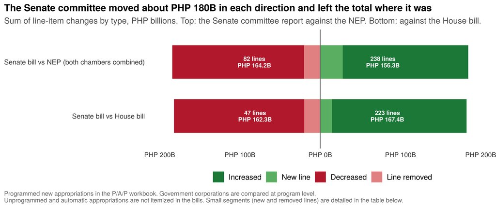

```r
sst <- bind_rows(
  ss %>% mutate(cmp = "Senate bill vs House bill", d = dS, status = ifelse(status == "Unchanged", NA, status)) %>% filter(!is.na(status)),
  ss %>% mutate(cmp = "Senate bill vs NEP (both chambers combined)", d = dSN, status = ifelse(status_n == "At the NEP level", NA, status_n)) %>% filter(!is.na(status))) %>%
  mutate(status = recode(status, "Increased" = "Increased", "New line in the Senate bill" = "New line", "Decreased" = "Decreased", "Line removed by the Senate" = "Line removed",
                         "Above the NEP" = "Increased", "New since the NEP" = "New line", "Below the NEP" = "Decreased", "Removed since the NEP" = "Line removed")) %>%
  group_by(cmp, status) %>% summarise(lines = n(), amt = sum(abs(d)), .groups = "drop") %>%
  mutate(status = factor(status, levels = c("Increased", "New line", "Decreased", "Line removed")), sign = ifelse(status %in% c("Increased", "New line"), amt, -amt),
         cmp = factor(cmp, levels = c("Senate bill vs House bill", "Senate bill vs NEP (both chambers combined)")))
ggplot(sst, aes(sign, cmp, fill = status)) +
  geom_col(width = 0.62) + geom_vline(xintercept = 0, color = "grey40") +
  geom_text(data = sst %>% filter(amt > 40), aes(label = sprintf("%s lines\nPHP %sB", lines, comma(amt, accuracy = 0.1))), position = position_stack(vjust = 0.5), size = 3.1, color = "white", fontface = "bold", lineheight = 0.9) +
  scale_fill_manual(values = c(Increased = up_col, `New line` = "#5AAE61", Decreased = dn_col, `Line removed` = "#E08080")) +
  scale_x_continuous(labels = function(x) paste0(peso, comma(abs(x)), "B"), expand = expansion(mult = c(0.08, 0.08))) +
  labs(x = NULL, y = NULL, title = "The Senate committee moved about PHP 180B in each direction and left the total where it was",
       subtitle = "Sum of line-item changes by type, PHP billions. Top: the Senate committee report against the NEP. Bottom: against the House bill.",
       caption = "Programmed new appropriations in the P/A/P workbook. Government corporations are compared at program level.\nUnprogrammed and automatic appropriations are not itemized in the bills. Small segments (new and removed lines) are detailed in the table below.") +
  theme_pbc() + theme(panel.grid.major.y = element_blank(), axis.text.y = element_text(size = 10)) + guides(fill = guide_legend(nrow = 1))
```

```r
sp <- ss %>% filter(abs(dH) > 0.0005 | abs(dS) > 0.0005) %>% group_by(path) %>%
  summarise(lines = n(), `House change` = sum(dH), `Senate change` = sum(dS), `Net vs NEP` = sum(dSN), .groups = "drop") %>%
  mutate(path = factor(path, levels = c("House change fully reversed", "House change partly reversed", "House change more than reversed", "House change kept by the Senate", "Senate moved further in the House's direction", "Senate change only"))) %>% arrange(path)
sp %>% transmute(`What happened to the line` = path, Lines = lines, `House vs NEP` = fmt_chg(`House change`, 1), `Senate vs House` = fmt_chg(`Senate change`, 1), `Senate vs NEP` = fmt_chg(`Net vs NEP`, 1)) %>%
  kbl_clean(font = 12.5, align = c("l", "r", "r", "r", "r"), caption = "How the Senate committee treated the lines the House had changed (PHP billions, net)") %>% column_spec(4, bold = TRUE)
```

How the Senate committee treated the lines the House had changed (PHP billions, net)

| What happened to the line | Lines | House vs NEP | Senate vs House | Senate vs NEP |
| --- | --- | --- | --- | --- |
| House change fully reversed | 18 | -41.5 | +41.5 | 0.00 |
| House change partly reversed | 34 | +57.3 | -48.2 | +9.1 |
| House change more than reversed | 12 | +29.4 | -42.2 | -12.8 |
| House change kept by the Senate | 107 | -41.9 | 0.00 | -41.9 |
| Senate moved further in the House’s direction | 40 | -3.3 | +1.7 | -1.6 |
| Senate change only | 358 | 0.00 | +47.3 | +47.3 |

```r
kept <- sp %>% filter(path == "House change kept by the Senate"); rev_full <- sp %>% filter(path == "House change fully reversed"); rev_part <- sp %>% filter(path == "House change partly reversed")
```

The committee’s press materials describe ₱97.5B of DPWH cuts: ₱87B of House-stage projects that failed the documentary requirements, ₱8.8B of NEP projects (295 of them), and ₱1.7B for 36 DPWH buildings. The line data show ₱99B of gross cuts in DPWH and ₱33B of gross additions, all of the latter to foreign-assisted projects, for a net cut of ₱66B. The project-by-project detail of those cuts is in Annex A-4 of the committee report, which lists each deleted and retained project under every sub-program and office; this report works at the sub-program and office level and has not yet encoded that annex.

## 3.2 The largest increases and decreases

### 3.2.1 Against the House bill

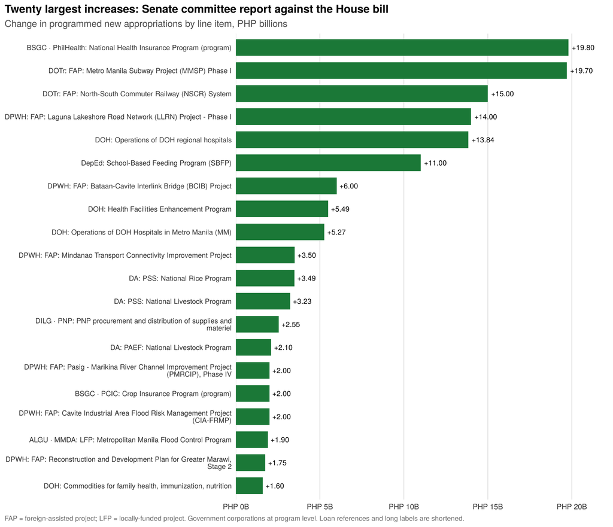

```r
top_up <- ss %>% slice_max(dS, n = 20)
ggplot(top_up, aes(dS, reorder(lab, dS))) +
  geom_col(fill = up_col, width = 0.72) +
  geom_text(aes(label = paste0("+", comma(dS, accuracy = 0.01))), hjust = -0.15, size = 3) +
  scale_x_continuous(labels = function(x) paste0(peso, comma(x), "B"), expand = expansion(mult = c(0, 0.12))) +
  labs(x = NULL, y = NULL, title = "Twenty largest increases: Senate committee report against the House bill",
       subtitle = "Change in programmed new appropriations by line item, PHP billions",
       caption = "FAP = foreign-assisted project; LFP = locally-funded project. Government corporations at program level. Loan references and long labels are shortened.") +
  theme_pbc(11) + theme(panel.grid.major.y = element_blank(), panel.grid.major.x = element_line(color = "grey90"), axis.text.y = element_text(size = 8.3, lineheight = 0.85))
```

The twenty largest increases are ₱136B of the ₱182B added, and they fall into three groups. The first is health: PhilHealth’s premium subsidy (+₱19.8B), the operations of DOH regional hospitals (+₱13.8B) and Metro Manila hospitals (+₱5.3B), HFEP (+₱5.5B), and the immunization and family-health commodities (+₱1.6B). The hospital increases are the other side of the MAP cut: the committee describes them as funding for zero balance billing, so the money reaches patients as waived hospital bills instead of guarantee letters. Annex B also rewrites the MAP provision: assistance is limited to indigent or financially incapacitated patients, the DOH central office may contract directly with the specialty, SUC and LGU hospitals, and private facilities must bill at standard or regulated rates. The second group is the foreign-assisted projects restored, led by the Subway and the NSCR, the Laguna Lakeshore road, the Bataan-Cavite bridge, and the Mindanao transport project. The third is food and farms: school feeding (+₱11.0B, enough for universal feeding in kindergarten and Grade 1), the National Rice Program’s production support (+₱3.5B), two new National Livestock Program lines replacing the ₱20B Animal Industry project, crop insurance (+₱2.0B), and the Metro Manila flood control program under the MMDA (+₱1.9B).

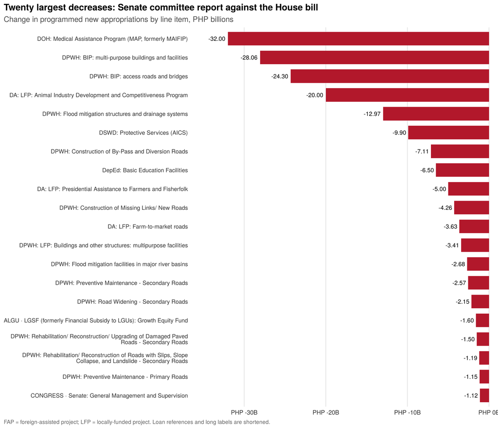

```r
top_dn <- ss %>% slice_min(dS, n = 20)
ggplot(top_dn, aes(dS, reorder(lab, -dS))) +
  geom_col(fill = dn_col, width = 0.72) +
  geom_text(aes(label = comma(dS, accuracy = 0.01)), hjust = 1.15, size = 3) +
  scale_x_continuous(labels = function(x) paste0(peso, comma(x), "B"), expand = expansion(mult = c(0.14, 0.02))) +
  labs(x = NULL, y = NULL, title = "Twenty largest decreases: Senate committee report against the House bill",
       subtitle = "Change in programmed new appropriations by line item, PHP billions",
       caption = "FAP = foreign-assisted project; LFP = locally-funded project. Loan references and long labels are shortened.") +
  theme_pbc(11) + theme(panel.grid.major.y = element_blank(), panel.grid.major.x = element_line(color = "grey90"), axis.text.y = element_text(size = 8.3, lineheight = 0.85))
```

The cuts are even more concentrated: the twenty largest are ₱171B of the ₱182B removed, and 12 of the twenty are DPWH sub-programs. MAP is the single largest cut, from ₱48.2B to ₱16.2B. The two BIP lump lines lose ₱28.1B and ₱24.3B, which takes back 73% of the ₱72B the House had added to them. Flood mitigation structures, bypass roads, missing links, and secondary-road maintenance all fall. Outside DPWH, the committee zeroed the ₱20B Animal Industry Development and Competitiveness Program, a new NEP project, and rebuilt a smaller livestock program from its parts (₱5.7B across production support, equipment, extension and research); it cut AICS by ₱9.9B, PAFF by ₱5.0B, farm-to-market roads back to the NEP’s ₱16.0B, Basic Education Facilities by a further ₱6.5B, the Growth Equity Fund by ₱1.6B, and the Senate’s own two lines by ₱2.0B.

### 3.2.2 Against the NEP

Because the Senate reversed much of what the House did, the comparison against the NEP looks different from the comparison against the House bill. It shows where the budget stands now.

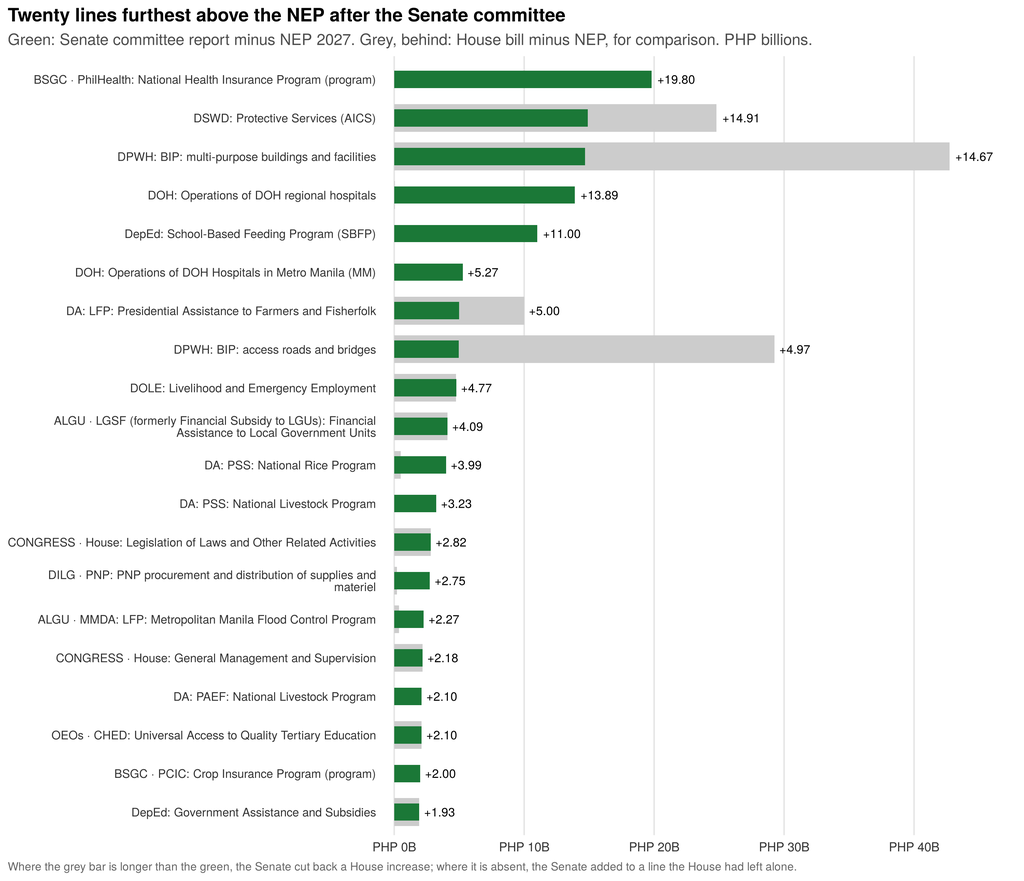

```r
top_upN <- ss %>% slice_max(dSN, n = 20) %>% mutate(lab2 = sprintf("%s\n[House %s]", lab, fmt_chg(dH)))
ggplot(top_upN, aes(dSN, reorder(lab, dSN))) +
  geom_col(aes(x = dH), fill = "grey80", width = 0.72) +
  geom_col(fill = up_col, width = 0.45) +
  geom_text(aes(x = pmax(dSN, dH), label = paste0("+", comma(dSN, accuracy = 0.01))), hjust = -0.15, size = 3) +
  scale_x_continuous(labels = function(x) paste0(peso, comma(x), "B"), expand = expansion(mult = c(0.02, 0.12))) +
  labs(x = NULL, y = NULL, title = "Twenty lines furthest above the NEP after the Senate committee",
       subtitle = "Green: Senate committee report minus NEP 2027. Grey, behind: House bill minus NEP, for comparison. PHP billions.",
       caption = "Where the grey bar is longer than the green, the Senate cut back a House increase; where it is absent, the Senate added to a line the House had left alone.") +
  theme_pbc(11) + theme(panel.grid.major.y = element_blank(), panel.grid.major.x = element_line(color = "grey90"), axis.text.y = element_text(size = 8.3, lineheight = 0.85))
```

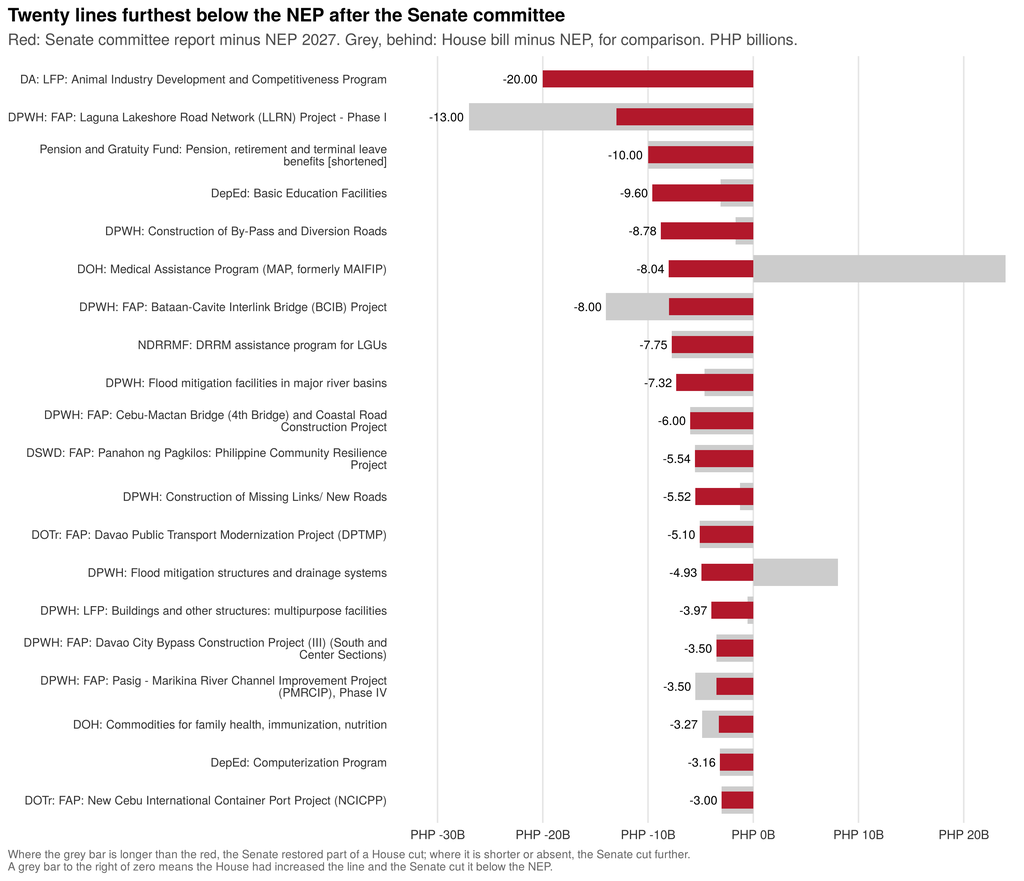

```r
top_dnN <- ss %>% slice_min(dSN, n = 20)
ggplot(top_dnN, aes(dSN, reorder(lab, -dSN))) +
  geom_col(aes(x = dH), fill = "grey80", width = 0.72) +
  geom_col(fill = dn_col, width = 0.45) +
  geom_text(aes(x = pmin(dSN, dH), label = comma(dSN, accuracy = 0.01)), hjust = 1.15, size = 3) +
  scale_x_continuous(labels = function(x) paste0(peso, comma(x), "B"), expand = expansion(mult = c(0.14, 0.02))) +
  labs(x = NULL, y = NULL, title = "Twenty lines furthest below the NEP after the Senate committee",
       subtitle = "Red: Senate committee report minus NEP 2027. Grey, behind: House bill minus NEP, for comparison. PHP billions.",
       caption = "Where the grey bar is longer than the red, the Senate restored part of a House cut; where it is shorter or absent, the Senate cut further.\nA grey bar to the right of zero means the House had increased the line and the Senate cut it below the NEP.") +
  theme_pbc(11) + theme(panel.grid.major.y = element_blank(), panel.grid.major.x = element_line(color = "grey90"), axis.text.y = element_text(size = 8.3, lineheight = 0.85))
```

Against the NEP, the lines furthest up are PhilHealth, AICS (still +₱14.9B), the BIP multi-purpose buildings (+₱14.7B), DOH hospital operations, school feeding, PAFF, the BIP access roads (+₱5.0B), TUPAD, Financial Assistance to LGUs, the rice program, the House’s two lines, and tertiary education subsidies. The lines furthest down are the Animal Industry project (−₱20B, replaced in part), the Laguna Lakeshore road (still −₱13.0B), the Pension and Gratuity Fund (−₱10B), Basic Education Facilities (−₱9.6B), DPWH’s bypass roads and flood facilities, MAP (−₱8.0B), the Bataan-Cavite bridge, the calamity fund’s LGU assistance program (−₱7.8B), and the unrestored loan projects: the Cebu-Mactan fourth bridge, DSWD’s community resilience project, the Davao bus project, the Davao bypass, and the new Cebu container port.

### 3.2.3 Foreign-assisted projects

```r
ss <- ss %>% mutate(fap = str_detect(coalesce(PAP, ""), "^Foreign-As{1,3}i?s?i?ted"))
fap_dep <- ss %>% filter(fap) %>% group_by(dep) %>%
  summarise(lines = n(), N27 = sum(N27), H27 = sum(H27), S27 = sum(S27), dH = sum(dH), dS = sum(dS), dSN = sum(dSN), .groups = "drop") %>%
  filter(N27 + H27 + S27 > 0) %>% arrange(dSN)
fap_tot <- ss %>% filter(fap) %>% summarise(lines = n(), cut_h = sum(dH < -0.0005), up_s = sum(dS > 0.0005), dn_s = sum(dS < -0.0005), still_below = sum(dSN < -0.0005),
                                            full = sum(dH < -0.0005 & abs(dSN) < 0.0005), none_back = sum(dH < -0.0005 & abs(dS) < 0.0005),
                                            N27 = sum(N27), H27 = sum(H27), S27 = sum(S27), dH = sum(dH), dS = sum(dS), dSN = sum(dSN))
```

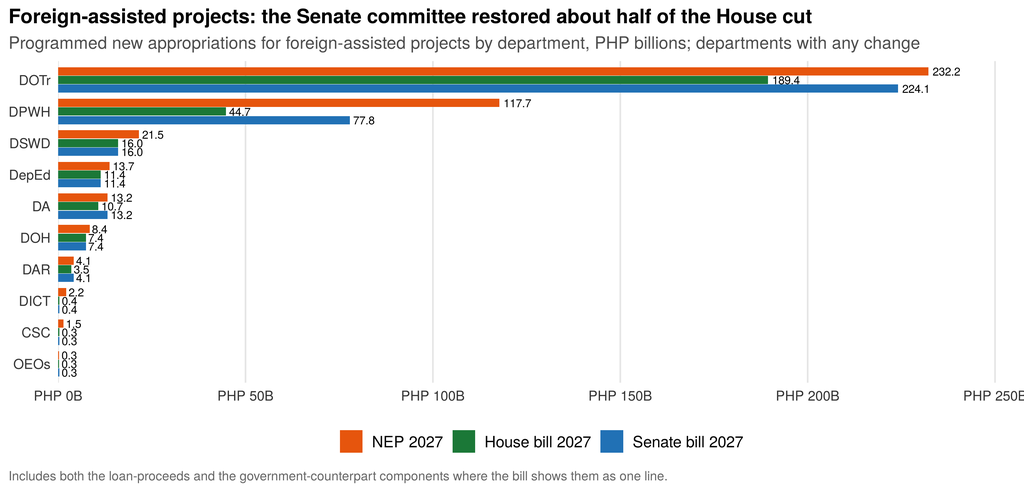

```r
fd <- fap_dep %>% filter(abs(dH) > 0.0005 | abs(dS) > 0.0005) %>% select(dep, `NEP 2027` = N27, `House bill 2027` = H27, `Senate bill 2027` = S27) %>% pivot_longer(-dep) %>%
  mutate(name = factor(name, levels = rev(names(v3_pal))))
ord_f <- fap_dep %>% filter(abs(dH) > 0.0005 | abs(dS) > 0.0005) %>% arrange(N27) %>% pull(dep)
ggplot(fd, aes(value, factor(dep, levels = ord_f), fill = name)) +
  geom_col(position = position_dodge(width = 0.82), width = 0.78) +
  geom_text(aes(label = comma(value, accuracy = 0.1)), position = position_dodge(width = 0.82), hjust = -0.15, size = 2.8) +
  scale_fill_manual(values = v3_pal, breaks = names(v3_pal)) +
  scale_x_continuous(labels = function(x) paste0(peso, comma(x), "B"), expand = expansion(mult = c(0, 0.1))) +
  labs(x = NULL, y = NULL, title = "Foreign-assisted projects: the Senate committee restored about half of the House cut",
       subtitle = "Programmed new appropriations for foreign-assisted projects by department, PHP billions; departments with any change",
       caption = "Includes both the loan-proceeds and the government-counterpart components where the bill shows them as one line.") +
  theme_pbc() + theme(panel.grid.major.y = element_blank(), panel.grid.major.x = element_line(color = "grey90")) + guides(fill = guide_legend(nrow = 1))
```

The House had cut 31 foreign-assisted projects by ₱130.7B in all. The Senate committee raised 20 foreign-assisted lines by ₱70.9B and cut none, so foreign-assisted appropriations stand at ₱355.9B against ₱415.6B in the NEP, still ₱59.8B short. Back exactly at their NEP amounts are 10 projects, including the Metro Manila Subway (₱67.4B), the NSCR (₱123.8B), the World Bank’s Mindanao Transport Connectivity Improvement Project, the Marawi reconstruction loan, and DA’s PRDP Scale-Up. Others were only partly restored: the Laguna Lakeshore Road Network goes from ₱8.2B to ₱22.2B against ₱35.2B proposed, the Bataan-Cavite bridge from ₱8.5B to ₱14.5B against ₱22.5B, and the Pasig-Marikina and Cavite flood projects recover ₱2B each of the ₱5.5B and ₱3.5B the House took. That leaves 20 projects below the NEP, 12 of which got nothing back at all.

The committee’s own accounting puts the restorations at ₱68.8B, close to the ₱70.9B measured here. The argument PBC made at the House stage still applies to the ₱60B that remains cut: these are signed loans whose proceeds can only finance the projects they were borrowed for, so cutting their appropriation frees no cash for anything else, delays drawdowns, and leaves the government paying commitment fees on undrawn balances. Whether the unrestored projects reappear under unprogrammed appropriations, as they did in 2024 and 2025, is answered in the committee report’s unprogrammed annex, taken up next: some do, in part.

```r
ss %>% filter(fap, abs(dH) > 0.0005 | abs(dS) > 0.0005) %>% arrange(dSN) %>%
  transmute(Department = dep, `Foreign-assisted project` = PAP, `NEP 2027` = bn(N27, 2), `House bill 2027` = bn(H27, 2), `Senate bill 2027` = bn(S27, 2), `Senate vs House` = fmt_chg(dS), `Senate vs NEP` = fmt_chg(dSN)) %>%
  kbl_clean(font = 11.5, align = c("l", "l", "r", "r", "r", "r", "r"), caption = "Every foreign-assisted line changed by either chamber (PHP billions)") %>%
  column_spec(2, width = "46%") %>% column_spec(6, bold = TRUE)
```

Every foreign-assisted line changed by either chamber (PHP billions)

| Department | Foreign-assisted project | NEP 2027 | House bill 2027 | Senate bill 2027 | Senate vs House | Senate vs NEP |
| --- | --- | --- | --- | --- | --- | --- |
| DPWH | Foreign-Assisted Project: Laguna Lakeshore Road Network (LLRN) Project - Phase I, KEDCF Loan No. PHL-27, ADB Loan No. 4523-PHI and AIIB Loan No. L0725A | 35.21 | 8.21 | 22.21 | +14.00 | -13.00 |
| DPWH | Foreign-Assisted Project: Bataan-Cavite Interlink Bridge (BCIB) Project, ADB Loan No. 4432 - PHI and AIIB Loan No. L0724A | 22.49 | 8.49 | 14.49 | +6.00 | -8.00 |
| DPWH | Foreign-Assisted Project: Cebu-Mactan Bridge (4th Bridge) and Coastal Road Construction Project, JICA Loan No. PH - P274 | 8.57 | 2.57 | 2.57 | 0.00 | -6.00 |
| DSWD | Foreign-Assisted Project: Panahon ng Pagkilos: Philippine Community Resilience Project WB Loan No. 98460-PH | 17.66 | 12.12 | 12.12 | 0.00 | -5.54 |
| DOTr | Foreign-Assisted Project: Davao Public Transport Modernization Project (DPTMP) ADB Loan Nos. 4324-PHI, 8450-PHI and 8449-PHI | 15.08 | 9.98 | 9.98 | 0.00 | -5.10 |
| DPWH | Foreign-Assisted Project: Davao City Bypass Construction Project (III) (South and Center Sections), Package I, JICA Loan No. PH-P282 | 7.42 | 3.92 | 3.92 | 0.00 | -3.50 |
| DPWH | Foreign-Assisted Project: Pasig - Marikina River Channel Improvement Project (PMRCIP), Phase IV, JICA Loan Nos. PH-P271 and PH-P283 | 8.54 | 3.04 | 5.04 | +2.00 | -3.50 |
| DOTr | Foreign-Assisted Project: New Cebu International Container Port Project (NCICPP) Korea EDCF Loan No. PHL-19 | 8.99 | 5.99 | 5.99 | 0.00 | -3.00 |
| DPWH | Foreign-Assisted Project: Davao City Bypass Construction Project (II) (South and Center Sections), Package I, JICA Loan No. PH-P273 | 4.39 | 2.39 | 2.39 | 0.00 | -2.00 |
| DICT | Foreign-Assisted Project: Philippine Digital Infrastructure Project IBRD Loan No. 9730-PH | 2.16 | 0.36 | 0.36 | 0.00 | -1.80 |
| DPWH | Foreign-Assisted Project: Cavite Industrial Area Flood Risk Management Project (CIA-FRMP) | 6.57 | 3.07 | 5.07 | +2.00 | -1.50 |
| DepEd | Foreign-Assisted Project: Project for Learning Upgrade Support and Decentralization (PLUS-D) WB Loan No. 9933-PH | 10.81 | 9.41 | 9.41 | 0.00 | -1.40 |
| DPWH | Foreign-Assisted Project: Integrated Flood Resilience and Adaptation 1 (InFRA I) Project, ADB Loan No. 4345-PHI | 3.08 | 1.58 | 1.83 | +0.25 | -1.25 |
| CSC | Foreign-Assisted Project: Philippine Civil Service Modernization Project IBRD Loan No. 9766-PH | 1.45 | 0.33 | 0.33 | 0.00 | -1.12 |
| DOH | Foreign-Assisted Project: Philippines Health System Resilience Project, Phase 1 WB Loan No. 9781-PH | 7.73 | 6.73 | 6.73 | 0.00 | -1.00 |
| DPWH | Foreign-Assisted Project: Metro Manila Priority Bridges for Seismic Design Improvement Project, JICA, PH-P260 | 2.86 | 0.86 | 1.86 | +1.00 | -1.00 |
| DepEd | Foreign-Assisted Project: Infrastructure for Safer and Resilient Schools (ISRS) Project WB Loan No. 9704-PH | 2.16 | 1.22 | 1.22 | 0.00 | -0.94 |
| DPWH | Foreign-Assisted Project: Dalton Pass East Alignment Road Project, JICA Loan No. PH - P280 | 1.05 | 0.55 | 0.55 | 0.00 | -0.50 |
| DPWH | Foreign-Assisted Project: Samar-Pacific Coastal Road (SPCR) II Project, Provinces of Northern Samar and Eastern Samar in the Eastern Visayas Region | 1.06 | 0.56 | 0.66 | +0.10 | -0.40 |
| DPWH | Foreign-Assisted Project: Accelerated Bridge Construction Project for Greater Economic Mobility and Calamity Response, Proposed for French ODA | 1.76 | 0.96 | 1.46 | +0.50 | -0.31 |
| DAR | Foreign-Assisted Project: Value Chain Innovation for Sustainable Transformation in Agrarian Reform Communities (VISTA) IFAD Loan No. 200000501900 and IFAD Loan No. 200000502000 | 2.00 | 1.40 | 2.00 | +0.60 | 0.00 |
| DA | Foreign-Assisted Project: Mindanao Inclusive Agriculture Development Project (MIADP) IBRD Loan No. 9488-PH | 1.51 | 1.21 | 1.51 | +0.30 | 0.00 |
| DA | Foreign-Assisted Project: Philippine Rural Development Project Scale-Up (PRDP-SU) IBRD Loan No. 9577-PH | 8.86 | 7.37 | 8.86 | +1.49 | 0.00 |
| DA | Foreign-Asssited Project: Philippine Fisheries and Coastal Resiliency Project (FishCORE) IBRD Loan No. 9480-PH | 1.80 | 1.10 | 1.80 | +0.70 | 0.00 |
| DOTr | Foreign-Assisted Project: Metro Manila Subway Project (MMSP) Phase I JICA Loan Nos. PH-P267, PH-P275, PH-P279 and PH-P286 | 67.44 | 47.74 | 67.44 | +19.70 | 0.00 |
| DOTr | Foreign-Assisted Project: North-South Commuter Railway (NSCR) System ADB Loan Nos. 3796-PHI, 4188-PHI and 4589-PHI, and JICA Loan Nos. PH-P262, PH-P270, PH-P276 and PH-P277 | 123.84 | 108.84 | 123.84 | +15.00 | 0.00 |
| DPWH | Foreign-Assisted Project: Mindanao Transport Connectivity Improvement Project, IBRD Loan No. 9775-PH | 5.21 | 1.71 | 5.21 | +3.50 | 0.00 |
| DPWH | Foreign-Assisted Project: Reconstruction and Development Plan for Greater Marawi, Stage 2, ADB Loan No. 3769-PHI | 2.87 | 1.12 | 2.87 | +1.75 | 0.00 |
| DPWH | Foreign-Assisted Project: Samar Pacific Coastal Road II Project (Laoang II Bridge and Calomotan Bridge), KEDCF Loan No. PHL-26 | 1.46 | 0.71 | 1.46 | +0.75 | 0.00 |
| DPWH | Foreign-Assisted Project: Infrastructure Preparation and Innovation Facility (IPIF)-Second Additional Financing, Output 2: Water Projects ADB Loan No. 4424-PHI | 1.15 | 0.90 | 1.15 | +0.25 | 0.00 |
| OEOs | Foreign-Assisted Project: Capacity Building to Foster Competition | 0.28 | 0.28 | 0.31 | +0.03 | +0.03 |
| DPWH | Foreign-Assisted Project: Samal Island Davao City Connector Project CEXIM Loan No GCL20220060763 | 0.00 | 0.05 | 0.05 | 0.00 | +0.05 |
| DPWH | Foreign-Assisted Project: Road Network Development Project in Conflict-Affected Areas in Mindanao (RNDP-CAAM), JICA-Assisted | 0.00 | 0.12 | 0.12 | 0.00 | +0.12 |
| DPWH | Foreign-Assisted Project: Improving Growth Corridors in Mindanao Road Sector Project (IGCMRSP), ADB Loan No. 3631-PHI | 2.11 | 1.36 | 2.36 | +1.00 | +0.25 |
| DPWH | Foreign-Assisted Project: Metro Manila Bridges Project (MMPB), ADB Loan No 4168-PHI | 0.00 | 0.31 | 0.31 | 0.00 | +0.31 |
| DPWH | Foreign-Assisted Project: Priority Bridges crossing Pasig-Marikina River and Manggahan Floodway Bridges Construction Project, under China Government Financing Facility | 0.00 | 0.33 | 0.33 | 0.00 | +0.33 |

### 3.2.4 Unprogrammed appropriations: standby cover for 41 loan projects

```r
# Unprogrammed appropriations in Committee Report No. 131 (Annex A, pp. 152-156; PHP thousands in the source).
# The committee deleted three purposes and inserted an itemized list of foreign-assisted projects.
ua_del <- tibble::tribble(~item, ~H,
  "Restoration of the fund balances of the Philippine Deposit Insurance Corporation", 57000000,
  "Program on Risk Management", 3600000,
  "Support to Foreign-Assisted Projects (one lump line)", 42553494) %>% mutate(H = H / 1e6)
ua_items <- tibble::tribble(~dep, ~project, ~ua, ~rx,
  "DAR",  "Pang-Agraryong Tulay para sa Bagong Bayanihan ng mga Magsasaka (PBBM) Bridges Project", 10877270, "Pang-Agraryong Tulay",
  "DA",   "Farm-to-Market Bridges Development Program", 8161386, "Farm-to-Market Bridges",
  "DA",   "Mindanao Inclusive Agriculture Development Project (MIADP), IBRD 9488-PH", 1514020, "Mindanao Inclusive Agriculture",
  "DA",   "Philippine Rural Development Project Scale-Up (PRDP-SU), IBRD 9577-PH", 8864513, "Rural Development Project Scale-Up",
  "DA",   "BFAR: Philippine Fisheries and Coastal Resiliency Project (FishCORE), IBRD 9480-PH", 1798079, "FishCORE",
  "DepEd","Infrastructure for Safer and Resilient Schools (ISRS), WB 9704-PH", 1944335, "Safer and Resilient Schools",
  "DepEd","Project for Learning Upgrade Support and Decentralization (PLUS-D), WB 9933-PH", 7479656, "Learning Upgrade Support",
  "DOH",  "Philippines: Health System Resilience Project, Phase 1, WB 9781-PH", 1000000, "Health System Resilience",
  "DICT", "Philippine Digital Infrastructure Project, IBRD 9730-PH", 1163595, "Philippine Digital Infrastructure Project",
  "DILG", "Accelerated Water and Sanitation Project in Selected Areas (AWSPSA)", 235493, "^$",
  "OEOs", "TESDA: Boosting Employability in Strategic Technical and Vocational Education and Training Sectors", 3186778, "^$",
  "DPWH", "Davao City Bypass Construction Project (South and Center Sections), Package I, JICA PH-P261", 2572759, "^$",
  "DPWH", "Panglao Island-Tagbilaran City Offshore Bridge Connector, main bridge and Dupinga bridge", 2639146, "Panglao",
  "DPWH", "Accelerated Bridge Construction Project for Greater Economic Mobility and Calamity Response", 1805533, "Accelerated Bridge Construction",
  "DPWH", "Accelerated Water and Sanitation Project in Selected Areas (AWSPSA)", 1865766, "Accelerated Water and Sanitation",
  "DPWH", "Philippine Seismic Risk Reduction and Resilience Project (PSRRRP), IBRD 9251-PH", 9504573, "Seismic Risk Reduction",
  "DPWH", "Davao City Bypass Construction Project (II), Package I, JICA PH-P273", 640953, "Davao City Bypass Construction Project \\(II\\)",
  "DPWH", "Davao City Bypass Construction Project (III), Package I, JICA PH-P282", 706390, "Davao City Bypass Construction Project \\(III\\)",
  "DPWH", "Cebu-Mactan Bridge (4th Bridge) and Coastal Road Construction Project, JICA PH-P274", 1055623, "Cebu-Mactan Bridge \\(4th",
  "DPWH", "Philippines-Korea Project Preparation Facility (PK-PPF), Output 3, KEDCF PHL-20", 192052, "PK-PPF\\), KEDCF Loan",
  "DPWH", "Dalton Pass East Alignment Road Project, JICA PH-P280", 376690, "Dalton Pass",
  "DPWH", "Central Mindanao High Standard Highway, Cagayan de Oro-Malaybalay section, JICA PH-P287", 73191, "Central Mindanao High Standard",
  "DPWH", "Bataan-Cavite Interlink Bridge (BCIB), ADB 4432-PHI and AIIB L0724A", 10176106, "Bataan-Cavite",
  "DPWH", "Laguna Lakeshore Road Network (LLRN), KEDCF PHL-27, ADB 4523-PHI, AIIB L0725A", 2231596, "Laguna Lakeshore",
  "DPWH", "Infrastructure Preparation and Innovation Facility (IPIF), 2nd additional financing, Output 1, ADB 4424-PHI", 532832, "IPIF\\)-Second",
  "DPWH", "Improving Growth Corridors in Mindanao Road Sector Project, ADB 3631-PHI", 1006836, "Improving Growth Corridors",
  "DPWH", "Reconstruction and Development Plan for a Greater Marawi, Stage 2, ADB 3769-PHI", 669101, "Greater Marawi, Stage 2",
  "DPWH", "Mindanao Transport Connectivity Improvement Project, IBRD 9785-PH", 898743, "Mindanao Transport Connectivity",
  "DPWH", "Samar Pacific Coastal Road, Phase II (SPCR 2), KEDCF PHL-26", 276612, "Samar-Pacific Coastal Road \\(SPCR\\) II",
  "DPWH", "IPIF additional financing, Output 2 (water projects), ADB 3886-PHI", 248402, "IPIF\\), Output 2 \\(.*3886",
  "DPWH", "Road Network Development Project in Conflict-Affected Areas in Mindanao, JICA PH-FP1", 500000, "Conflict-Affected",
  "DOTr", "Acquisition of forty (40) units of fast patrol crafts", 1636638, "Forty \\(40\\) Units Fast Patrol",
  "DOTr", "Maritime Safety Enhancement Project (MSEP), Korea EDCF PHL-21", 68152, "Maritime Safety Enhancement",
  "DOTr", "Metro Manila Subway Project (MMSP) Phase I, JICA PH-P267/275/279/286", 2315342, "Metro Manila Subway",
  "DOTr", "North-South Commuter Railway (NSCR) System, ADB and JICA loans", 3175200, "North-South Commuter Railway \\(NSCR\\) System",
  "DOTr", "New Cebu International Container Port Project (NCICPP), Korea EDCF PHL-19", 1000000, "New Cebu International Container Port Project \\(NCICPP\\) Korea",
  "DOTr", "Davao Public Transport Modernization Project (DPTMP), ADB loans", 5447247, "Davao Public Transport",
  "DOTr", "New Dumaguete Airport Development Project (NDADP), Korea EDCF PHL-25", 1000000, "New Dumaguete Airport",
  "DOTr", "Maritime Safety Capability Improvement Project (MSCIP) Phase III, JICA PH-P281", 1000000, "MSCIP\\) Phase III",
  "DOTr", "Infrastructure Preparation and Innovation Facility (IPIF), second additional financing, ADB 4424-PHI", 1999740, "\\(IPIF\\) - Second Ad",
  "DOTr", "Metro Rail Transit (MRT) Line 3 Rehabilitation Project, JICA PH-P269/278/285", 500350, "MRT\\) Line 3 Rehabilitation Project JICA") %>%
  mutate(ua = ua / 1e6)
prog_of <- function(rx, dep_) { if (rx == "^$") return(c(N27 = 0, H27 = 0, S27 = 0))
  d <- ss %>% filter(dep == dep_, fap, str_detect(PAP, regex(rx))); if (nrow(d) == 0) return(c(N27 = NA, H27 = NA, S27 = NA)); c(N27 = sum(d$N27), H27 = sum(d$H27), S27 = sum(d$S27)) }
ua_m <- ua_items %>% rowwise() %>% mutate(pr = list(prog_of(rx, dep))) %>% ungroup() %>%
  mutate(N27 = map_dbl(pr, "N27"), H27 = map_dbl(pr, "H27"), S27 = map_dbl(pr, "S27"), gap = S27 - N27,
         cover = case_when(N27 == 0 ~ "No programmed line in the NEP", gap >= -0.0005 & ua > 0 ~ "At or above NEP in programmed; UA is additional",
                           ua >= -gap - 0.0005 ~ "Programmed cut fully covered by UA", TRUE ~ "Programmed cut partly covered by UA")) %>% select(-pr, -rx)
ua_tot <- tibble::tibble(H = 111.984494, S = 111.171698, del = sum(ua_del$H), ins = sum(ua_m$ua))
ua_cov <- ua_m %>% filter(gap < -0.0005) %>% summarise(n = n(), covered = sum(pmin(ua, -gap)), gap = sum(gap), ua = sum(ua))
ua_notcov <- ss %>% filter(fap, dSN < -0.0005) %>% filter(!str_detect(PAP, regex(paste(ua_items$rx[ua_items$rx != "^$"], collapse = "|")))) %>% summarise(n = n(), gap = sum(dSN))
# carry the Senate figure into the red-flag basket
ua_row <- ua_row %>% mutate(S27 = ua_tot$S, dS = S27 - H27, dSN = S27 - N27)
hrf_tu <- hrf_t %>% mutate(across(c(N26, G26, N27, H27, S27), ~ .x + ua_row[[cur_column()]]), dS = hrf_t$dS + ua_row$dS, dSN = hrf_t$dSN + ua_row$dSN)
```

The committee report’s unprogrammed appropriations annex shows where the unrestored loan projects went. The total barely moves, from ₱111.98B to ₱111.17B, but almost everything inside it changes. The committee deleted three purposes worth ₱103.2B: the ₱57.0B restoration of PDIC’s fund balances, the ₱3.6B Program on Risk Management, and the NEP’s single ₱42.6B “Support to Foreign-Assisted Projects” line. In their place it inserted ₱102.3B of standby cover itemized across 41 named loan projects, each with its own amount. Unprogrammed appropriations can only be released when the revenue or loan proceeds that back them materialize, so these are not appropriations in the same sense as the programmed lines, but for a foreign-assisted project an itemized standby amount is the normal route to drawing on a signed loan without a programmed appropriation. The committee rewrote the governing special provision to match (Annex B): releases under the new Purpose 1 are to cover the loan-proceeds requirements of approved loans, a SARO is issued only against a budget request supported by the perfected loan agreement, and releases are valid until 31 December 2027. The remaining ₱8.8B of the unprogrammed total is the conversion of national government advances to the National Food Authority into subsidy, a book entry.

```r
ua_m %>% arrange(desc(ua)) %>%
  transmute(Department = dep, `Project (as itemized in the unprogrammed annex)` = project, `Programmed: NEP` = bn(N27, 2), `Programmed: House` = bn(H27, 2), `Programmed: Senate` = bn(S27, 2),
            `Programmed, Senate vs NEP` = fmt_chg(gap), `Unprogrammed (Senate)` = bn(ua, 2), `Reading` = cover) %>%
  kbl_clean(font = 11, align = c("l", "l", rep("r", 5), "l"), caption = "Standby appropriations for foreign-assisted projects in the Senate committee report, against the programmed lines (PHP billions)") %>%
  column_spec(2, width = "34%") %>% column_spec(7, bold = TRUE) %>% column_spec(8, width = "16%")
```

Standby appropriations for foreign-assisted projects in the Senate committee report, against the programmed lines (PHP billions)

| Department | Project (as itemized in the unprogrammed annex) | Programmed: NEP | Programmed: House | Programmed: Senate | Programmed, Senate vs NEP | Unprogrammed (Senate) | Reading |
| --- | --- | --- | --- | --- | --- | --- | --- |
| DAR | Pang-Agraryong Tulay para sa Bagong Bayanihan ng mga Magsasaka (PBBM) Bridges Project | 1.42 | 1.42 | 1.42 | 0.00 | 10.88 | At or above NEP in programmed; UA is additional |
| DPWH | Bataan-Cavite Interlink Bridge (BCIB), ADB 4432-PHI and AIIB L0724A | 22.49 | 8.49 | 14.49 | -8.00 | 10.18 | Programmed cut fully covered by UA |
| DPWH | Philippine Seismic Risk Reduction and Resilience Project (PSRRRP), IBRD 9251-PH | 0.18 | 0.18 | 0.18 | 0.00 | 9.50 | At or above NEP in programmed; UA is additional |
| DA | Philippine Rural Development Project Scale-Up (PRDP-SU), IBRD 9577-PH | 8.86 | 7.37 | 8.86 | 0.00 | 8.86 | At or above NEP in programmed; UA is additional |
| DA | Farm-to-Market Bridges Development Program | 1.00 | 1.00 | 1.00 | 0.00 | 8.16 | At or above NEP in programmed; UA is additional |
| DepEd | Project for Learning Upgrade Support and Decentralization (PLUS-D), WB 9933-PH | 10.81 | 9.41 | 9.41 | -1.40 | 7.48 | Programmed cut fully covered by UA |
| DOTr | Davao Public Transport Modernization Project (DPTMP), ADB loans | 15.08 | 9.98 | 9.98 | -5.10 | 5.45 | Programmed cut fully covered by UA |
| OEOs | TESDA: Boosting Employability in Strategic Technical and Vocational Education and Training Sectors | 0.00 | 0.00 | 0.00 | 0.00 | 3.19 | No programmed line in the NEP |
| DOTr | North-South Commuter Railway (NSCR) System, ADB and JICA loans | 123.84 | 108.84 | 123.84 | 0.00 | 3.18 | At or above NEP in programmed; UA is additional |
| DPWH | Panglao Island-Tagbilaran City Offshore Bridge Connector, main bridge and Dupinga bridge | 0.17 | 0.17 | 0.17 | 0.00 | 2.64 | At or above NEP in programmed; UA is additional |
| DPWH | Davao City Bypass Construction Project (South and Center Sections), Package I, JICA PH-P261 | 0.00 | 0.00 | 0.00 | 0.00 | 2.57 | No programmed line in the NEP |
| DOTr | Metro Manila Subway Project (MMSP) Phase I, JICA PH-P267/275/279/286 | 67.44 | 47.74 | 67.44 | 0.00 | 2.32 | At or above NEP in programmed; UA is additional |
| DPWH | Laguna Lakeshore Road Network (LLRN), KEDCF PHL-27, ADB 4523-PHI, AIIB L0725A | 35.21 | 8.21 | 22.21 | -13.00 | 2.23 | Programmed cut partly covered by UA |
| DOTr | Infrastructure Preparation and Innovation Facility (IPIF), second additional financing, ADB 4424-PHI | 2.00 | 2.00 | 2.00 | 0.00 | 2.00 | At or above NEP in programmed; UA is additional |
| DepEd | Infrastructure for Safer and Resilient Schools (ISRS), WB 9704-PH | 2.16 | 1.22 | 1.22 | -0.94 | 1.94 | Programmed cut fully covered by UA |
| DPWH | Accelerated Water and Sanitation Project in Selected Areas (AWSPSA) | 0.07 | 0.07 | 0.07 | 0.00 | 1.87 | At or above NEP in programmed; UA is additional |
| DPWH | Accelerated Bridge Construction Project for Greater Economic Mobility and Calamity Response | 1.76 | 0.96 | 1.46 | -0.31 | 1.81 | Programmed cut fully covered by UA |
| DA | BFAR: Philippine Fisheries and Coastal Resiliency Project (FishCORE), IBRD 9480-PH | 1.80 | 1.10 | 1.80 | 0.00 | 1.80 | At or above NEP in programmed; UA is additional |
| DOTr | Acquisition of forty (40) units of fast patrol crafts | 5.53 | 5.53 | 5.53 | 0.00 | 1.64 | At or above NEP in programmed; UA is additional |
| DA | Mindanao Inclusive Agriculture Development Project (MIADP), IBRD 9488-PH | 1.51 | 1.21 | 1.51 | 0.00 | 1.51 | At or above NEP in programmed; UA is additional |
| DICT | Philippine Digital Infrastructure Project, IBRD 9730-PH | 2.16 | 0.36 | 0.36 | -1.80 | 1.16 | Programmed cut partly covered by UA |
| DPWH | Cebu-Mactan Bridge (4th Bridge) and Coastal Road Construction Project, JICA PH-P274 | 8.57 | 2.57 | 2.57 | -6.00 | 1.06 | Programmed cut partly covered by UA |
| DPWH | Improving Growth Corridors in Mindanao Road Sector Project, ADB 3631-PHI | 2.11 | 1.36 | 2.36 | +0.25 | 1.01 | At or above NEP in programmed; UA is additional |
| DOH | Philippines: Health System Resilience Project, Phase 1, WB 9781-PH | 7.73 | 6.73 | 6.73 | -1.00 | 1.00 | Programmed cut fully covered by UA |
| DOTr | New Cebu International Container Port Project (NCICPP), Korea EDCF PHL-19 | 8.99 | 5.99 | 5.99 | -3.00 | 1.00 | Programmed cut partly covered by UA |
| DOTr | New Dumaguete Airport Development Project (NDADP), Korea EDCF PHL-25 | 1.41 | 1.41 | 1.41 | 0.00 | 1.00 | At or above NEP in programmed; UA is additional |
| DOTr | Maritime Safety Capability Improvement Project (MSCIP) Phase III, JICA PH-P281 | 3.60 | 3.60 | 3.60 | 0.00 | 1.00 | At or above NEP in programmed; UA is additional |
| DPWH | Mindanao Transport Connectivity Improvement Project, IBRD 9785-PH | 5.21 | 1.71 | 5.21 | 0.00 | 0.90 | At or above NEP in programmed; UA is additional |
| DPWH | Davao City Bypass Construction Project (III), Package I, JICA PH-P282 | 7.42 | 3.92 | 3.92 | -3.50 | 0.71 | Programmed cut partly covered by UA |
| DPWH | Reconstruction and Development Plan for a Greater Marawi, Stage 2, ADB 3769-PHI | 2.87 | 1.12 | 2.87 | 0.00 | 0.67 | At or above NEP in programmed; UA is additional |
| DPWH | Davao City Bypass Construction Project (II), Package I, JICA PH-P273 | 4.39 | 2.39 | 2.39 | -2.00 | 0.64 | Programmed cut partly covered by UA |
| DPWH | Infrastructure Preparation and Innovation Facility (IPIF), 2nd additional financing, Output 1, ADB 4424-PHI | 1.15 | 0.90 | 1.15 | 0.00 | 0.53 | At or above NEP in programmed; UA is additional |
| DOTr | Metro Rail Transit (MRT) Line 3 Rehabilitation Project, JICA PH-P269/278/285 | 1.94 | 1.94 | 1.94 | 0.00 | 0.50 | At or above NEP in programmed; UA is additional |
| DPWH | Road Network Development Project in Conflict-Affected Areas in Mindanao, JICA PH-FP1 | 0.00 | 0.12 | 0.12 | +0.12 | 0.50 | No programmed line in the NEP |
| DPWH | Dalton Pass East Alignment Road Project, JICA PH-P280 | 1.05 | 0.55 | 0.55 | -0.50 | 0.38 | Programmed cut partly covered by UA |
| DPWH | Samar Pacific Coastal Road, Phase II (SPCR 2), KEDCF PHL-26 | 1.06 | 0.56 | 0.66 | -0.40 | 0.28 | Programmed cut partly covered by UA |
| DPWH | IPIF additional financing, Output 2 (water projects), ADB 3886-PHI | 0.19 | 0.19 | 0.19 | 0.00 | 0.25 | At or above NEP in programmed; UA is additional |
| DILG | Accelerated Water and Sanitation Project in Selected Areas (AWSPSA) | 0.00 | 0.00 | 0.00 | 0.00 | 0.24 | No programmed line in the NEP |
| DPWH | Philippines-Korea Project Preparation Facility (PK-PPF), Output 3, KEDCF PHL-20 | 0.28 | 0.28 | 0.28 | 0.00 | 0.19 | At or above NEP in programmed; UA is additional |
| DPWH | Central Mindanao High Standard Highway, Cagayan de Oro-Malaybalay section, JICA PH-P287 | 0.09 | 0.09 | 0.09 | 0.00 | 0.07 | At or above NEP in programmed; UA is additional |
| DOTr | Maritime Safety Enhancement Project (MSEP), Korea EDCF PHL-21 | 0.02 | 0.02 | 0.02 | 0.00 | 0.07 | At or above NEP in programmed; UA is additional |

Programmed amounts are the matching P/A/P lines in the three versions; “no programmed line” means the project has no NEP line (TESDA’s Boosting Employability project, DILG’s water and sanitation project) or its programmed line carries no amount (the first Davao bypass package). Amounts from Annex A of Committee Report No. 131, pp. 152 to 156, converted from PHP thousands.

First, 14 of the itemized projects are ones the Senate left below the NEP in the programmed budget, with a combined programmed gap of ₱47.0B; their standby amounts total ₱35.3B and cover ₱24.2B of the gap. The Bataan-Cavite bridge (₱10.2B standby against an ₱8.0B programmed gap), the Davao bus project and the DOH health system loan are fully covered; the Laguna Lakeshore road (₱2.2B against ₱13.0B), the Cebu-Mactan bridge, the two Davao bypass packages, the Cebu container port and DICT’s digital infrastructure loan are covered only in part. Another 6 foreign-assisted lines that are below the NEP, worth ₱13.9B, get no standby cover at all; DSWD’s Panahon ng Pagkilos community resilience project (₱5.5B short) and the Pasig-Marikina and Cavite flood projects are the largest.

Second, the biggest standby amounts are not for the House’s cuts. The DAR bridges project (₱10.9B standby against ₱1.4B programmed), DPWH’s seismic risk reduction project (₱9.5B against ₱0.18B), DA’s farm-to-market bridges (₱8.2B against ₱1.0B), PRDP Scale-Up (₱8.9B on top of a fully restored ₱8.9B), DepEd’s PLUS-D and the Panglao bridge together take ₱48B of the ₱102B. These are projects whose programmed lines are small or already whole; the standby amounts expand what they can draw in 2027 if the loans disburse. Bridges in particular (DAR’s, DA’s, Panglao, the accelerated bridge project) are ₱23B of it. Unlike the DPWH, farm-to-market road, HFEP and NIA lines, the DAR and DA bridge programs come with no project annex in the committee report.

Third, the ₱57B PDIC item is gone. The NEP had used it to describe the unprogrammed total as “a historic low” that was mostly a known obligation; the committee removed it without a replacement in the programmed budget, so the obligation is either deferred or will have to be met some other way. With it gone and the loan projects itemized, unprogrammed appropriations are now almost entirely a foreign-assisted standby list, ₱102.3B of the ₱111.2B.

For the red-flag basket this means the Senate’s unprogrammed figure is known and is ₱0.81B below the House’s. The basket including unprogrammed appropriations is therefore ₱944B, against ₱1,060B after the House and ₱976B in the NEP. The composition point stands either way: ₱102B of standby authority tied to named loans is less discretionary than the lump “support to foreign-assisted projects” line it replaces, and considerably less so than the ₱97.3B lump Congress enacted for 2026 and the executive released at ₱120.1B.

## 3.3 By department and special purpose fund

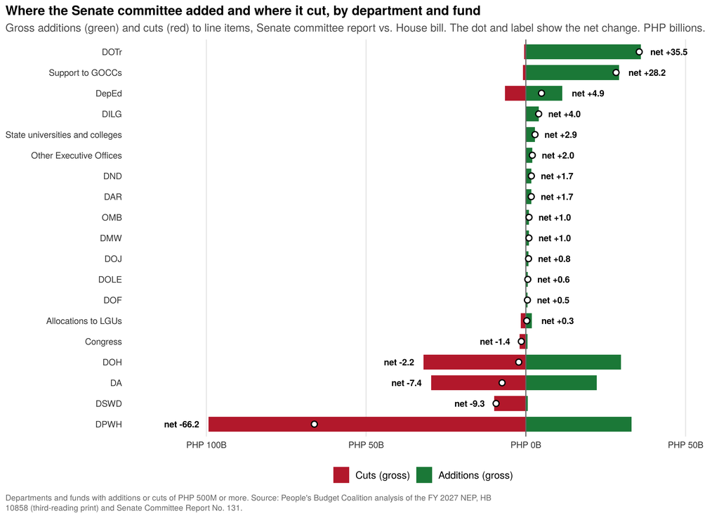

```r
sdp <- ss %>% group_by(dep) %>% summarise(N27 = sum(N27), H27 = sum(H27), S27 = sum(S27), up = sum(pmax(dS, 0)), dn = sum(pmin(dS, 0)), net = sum(dS), netN = sum(dSN), upN = sum(pmax(dSN, 0)), dnN = sum(pmin(dSN, 0)), .groups = "drop") %>%
  filter(abs(net) > 0.005 | up > 0.005 | dn < -0.005 | abs(netN) > 0.005) %>%
  mutate(dep_lab = recode(dep, "ALGU" = "Allocations to LGUs", "BSGC" = "Support to GOCCs", "NDRRMF" = "NDRRM (calamity) fund", "OEOs" = "Other Executive Offices", "CONGRESS" = "Congress", "SUCs" = "State universities and colleges"))
sdc <- sdp %>% filter(up >= 0.5 | dn <= -0.5)
ord_s <- sdc %>% arrange(net) %>% pull(dep_lab)
sdl <- sdc %>% select(dep_lab, Increases = up, Decreases = dn) %>% pivot_longer(-dep_lab) %>% mutate(name = factor(name, levels = c("Decreases", "Increases")))
pad <- max(abs(c(sdc$up, sdc$dn))) * 0.03
sdc <- sdc %>% mutate(lx = ifelse(net >= 0, up + pad, dn - pad),
                      lab = case_when(abs(net) < 0.05 ~ "net 0", net > 0 ~ paste0("net +", comma(net, accuracy = 0.1)), TRUE ~ paste0("net ", comma(net, accuracy = 0.1))))
ggplot() +
  geom_col(data = sdl, aes(value, factor(dep_lab, levels = ord_s), fill = name), width = 0.72) +
  geom_vline(xintercept = 0, color = "grey40") +
  geom_point(data = sdc, aes(net, factor(dep_lab, levels = ord_s)), shape = 21, fill = "white", color = "black", size = 2.2, stroke = 0.9) +
  geom_text(data = sdc, aes(lx, factor(dep_lab, levels = ord_s), label = lab, hjust = ifelse(net >= 0, 0, 1)), size = 3.1, fontface = "bold") +
  scale_fill_manual(values = c(Decreases = dn_col, Increases = up_col), labels = c("Cuts (gross)", "Additions (gross)")) +
  scale_x_continuous(labels = function(x) paste0(peso, comma(abs(x)), "B"), expand = expansion(mult = c(0.16, 0.14))) +
  labs(x = NULL, y = NULL, title = "Where the Senate committee added and where it cut, by department and fund",
       subtitle = "Gross additions (green) and cuts (red) to line items, Senate committee report vs. House bill. The dot and label show the net change. PHP billions.",
       caption = str_wrap(paste0("Departments and funds with additions or cuts of PHP 500M or more. Source: People's Budget Coalition analysis of the FY 2027 NEP, HB 10858 (third-reading print) and Senate Committee Report No. 131."), 135)) +
  theme_pbc(11) + theme(panel.grid.major.y = element_blank(), panel.grid.major.x = element_line(color = "grey90"), plot.caption = element_text(lineheight = 1.05))
```

```r
sdp %>% arrange(desc(net)) %>%
  transmute(`Department or fund` = dep_lab, `NEP 2027` = N27, `House bill 2027` = H27, `Senate bill 2027` = S27, `Senate additions` = up, `Senate cuts` = dn, `Senate vs House` = net, `Senate vs House (%)` = net / H27 * 100,
            `House vs NEP` = H27 - N27, `Senate vs NEP` = netN, `Senate vs NEP (%)` = netN / N27 * 100) %>%
  dt_table(caption = "Changes by department and special purpose fund across the three versions (PHP billions)", page = 15,
           money_cols = c("NEP 2027", "House bill 2027", "Senate bill 2027", "Senate additions", "Senate cuts", "Senate vs House", "House vs NEP", "Senate vs NEP"), money_digits = 2, pct_cols = c("Senate vs House (%)", "Senate vs NEP (%)"))
```

| Department or fund | NEP 2027 | House bill 2027 | Senate bill 2027 | Senate additions | Senate cuts | Senate vs House | Senate vs House (%) | House vs NEP | Senate vs NEP | Senate vs NEP (%) |
| --- | --- | --- | --- | --- | --- | --- | --- | --- | --- | --- |
| DOTr | 299.526428 | 259.075428 | 294.568744 | 35.99331599999999 | -0.4999999999999999 | 35.49331599999999 | 13.69999319271606 | -40.45100000000002 | -4.957684 | -1.655174147103974 |
| Support to GOCCs | 181.970095 | 179.51411 | 207.76063 | 29.14652 | -0.8999999999999996 | 28.24652 | 15.73498595737126 | -2.455984999999998 | 25.790535 | 14.17295242935385 |
| DepEd | 916.757759 | 910.586984 | 915.499946 | 11.412962 | -6.5 | 4.912962 | 0.5395379119541642 | -6.170774999999935 | -1.257813000000004 | -0.1372023293669232 |
| DILG | 330.465504 | 330.879584 | 334.903393 | 4.023808999999998 | 0 | 4.023808999999998 | 1.216094674490402 | 0.4140800000000127 | 4.437888999999998 | 1.342920500410232 |
| State universities and colleges | 134.561464 | 135.427464 | 138.299302 | 2.871837999999999 | 0 | 2.871837999999999 | 2.120572825612388 | 0.8659999999999854 | 3.737838 | 2.777792310583065 |
| Other Executive Offices | 64.641554 | 68.585419 | 70.61231 | 2.026891 | 0 | 2.026891 | 2.955279751225257 | 3.943865000000002 | 5.970755999999999 | 9.236714822790304 |
| DND | 324.632679 | 325.186444 | 326.915642 | 1.729198 | 0 | 1.729198 | 0.5317558686425442 | 0.5537649999999985 | 2.282963000000001 | 0.7032449742990909 |
| DAR | 14.690735 | 14.421735 | 16.121735 | 1.7 | 0 | 1.7 | 11.78776340017342 | -0.2690000000000001 | 1.431 | 9.740833253067324 |
| OMB | 7.062 | 7.262 | 8.262 | 1 | 0 | 1 | 13.77031120903333 | 0.1999999999999993 | 1.2 | 16.99235344095157 |
| DMW | 10.675431 | 10.925431 | 11.894726 | 0.9692950000000001 | 0 | 0.9692950000000001 | 8.871915442054416 | 0.25 | 1.219295 | 11.42150607315059 |

[output cut: 25 more lines]

Net of its own cuts, the committee added most to DOTr (₱35.5B, the two rail loans), support to GOCCs (₱28.2B: PhilHealth, crop insurance, NIA, the specialty hospitals), DepEd (₱4.9B net, because the ₱11B feeding increase is offset by the ₱6.5B classroom cut), DILG (₱4.0B, mostly PNP supplies and BFP benefits), the SUCs (₱2.9B across 149 lines), the CHED and TESDA lines under Other Executive Offices, DND, DAR, and the Ombudsman. It took most from DPWH (₱66.2B net), DSWD (₱9.3B, the AICS cut), DA (₱7.4B net, the Animal Industry project less the new livestock lines and rice support), DOH (₱2.2B net, because the ₱32.0B MAP cut slightly exceeds the hospital, HFEP and commodity additions), and Congress (₱1.4B, the Senate’s own lines). The Pension and Gratuity Fund, the calamity fund, DICT, DEPDev and the DFA stay where the House left them, below the NEP.

Measured from the NEP, the departments now furthest above the proposal are support to GOCCs (+₱25.8B), DSWD (+₱12.9B), DOH (+₱10.0B), DOLE (+₱6.8B), Other Executive Offices, DILG, Allocations to LGUs, DA, SUCs, and Congress (+₱3.6B). Furthest below are DPWH (−₱54.7B), the Pension and Gratuity Fund (−₱10B), the calamity fund (−₱9.5B), DOTr (−₱5.0B, the unrestored Davao and Cebu loans), DICT, the DFA, DepEd (−₱1.3B) and DEPDev.

### 3.3.1 By expense class

```r
hc <- long %>% filter(year == 2027, cls != "TOTAL", src %in% c("NEP", "HGAB", "SGAB")) %>% group_by(src, cls) %>% summarise(amt = sum(amt, na.rm = TRUE) / 1e9, .groups = "drop") %>%
  pivot_wider(names_from = src, values_from = amt) %>% mutate(cls = factor(cls, levels = c("PS", "MOOE", "FE", "CO"))) %>% arrange(cls) %>%
  mutate(chgH = HGAB - NEP, chgS = SGAB - HGAB, chgN = SGAB - NEP)
hc %>% transmute(`Expense class` = recode(as.character(cls), PS = "Personnel services", MOOE = "Maintenance and other operating expenses", FE = "Financial expenses", CO = "Capital outlays"),
                 `NEP 2027` = bn(NEP), `House bill 2027` = bn(HGAB), `Senate bill 2027` = bn(SGAB), `House vs NEP` = fmt_chg(chgH, 1), `Senate vs House` = fmt_chg(chgS, 1), `Senate vs NEP` = fmt_chg(chgN, 1), `Senate vs NEP (%)` = sprintf("%+.1f", chgN / NEP * 100)) %>%
  kbl_clean(align = c("l", rep("r", 7)), caption = "Programmed new appropriations by expense class (PHP billions)") %>% column_spec(6, bold = TRUE)
```

Programmed new appropriations by expense class (PHP billions)

| Expense class | NEP 2027 | House bill 2027 | Senate bill 2027 | House vs NEP | Senate vs House | Senate vs NEP | Senate vs NEP (%) |
| --- | --- | --- | --- | --- | --- | --- | --- |
| Personnel services | 1,891.0 | 1,882.6 | 1,883.9 | -8.4 | +1.3 | -7.1 | -0.4 |
| Maintenance and other operating expenses | 1,480.4 | 1,524.7 | 1,551.6 | +44.3 | +26.8 | +71.2 | +4.8 |
| Financial expenses | 0.0 | 0.0 | 0.0 | 0.00 | 0.00 | 0.00 | +0.0 |
| Capital outlays | 1,122.6 | 1,086.7 | 1,058.6 | -36.0 | -28.1 | -64.1 | -5.7 |

The Senate committee moved another ₱28B out of capital outlays and ₱27B into MOOE, on top of the House’s ₱36B. That looks like the House pattern, but the composition differs: the House’s MOOE went to AICS and MAP, the Senate’s to PhilHealth premiums, hospital operations, school feeding and crop insurance, while its capital-outlay cut fell on DPWH’s locally funded sub-programs and was partly offset by restored foreign-assisted capital. Capital outlays now stand at ₱1,059B, 5.7% below the NEP.

## 3.4 Every line changed

```r
ss %>% filter(status != "Unchanged" | status_n != "At the NEP level") %>% arrange(desc(dS)) %>%
  transmute(Department = dep, Agency = agy, `Program / Activity / Project` = PAP, `Senate vs House: status` = status,
            `GAA 2026` = G26, `NEP 2027` = N27, `House bill 2027` = H27, `Senate bill 2027` = S27, `Senate vs House` = dS, `Senate vs House (%)` = ifelse(H27 > 0, dS / H27 * 100, NA_real_),
            `House vs NEP` = dH, `Senate vs NEP` = dSN, `Senate vs NEP (%)` = ifelse(N27 > 0, dSN / N27 * 100, NA_real_)) %>%
  dt_table(caption = "Every line item changed by the House or the Senate committee, including new and removed lines (PHP billions). Sort by any column; filter by department or keyword; export with the buttons.", page = 20,
           money_cols = c("GAA 2026", "NEP 2027", "House bill 2027", "Senate bill 2027", "Senate vs House", "House vs NEP", "Senate vs NEP"), money_digits = 3, pct_cols = c("Senate vs House (%)", "Senate vs NEP (%)"))
```

| Department | Agency | Program / Activity / Project | Senate vs House: status | GAA 2026 | NEP 2027 | House bill 2027 | Senate bill 2027 | Senate vs House | Senate vs House (%) | House vs NEP | Senate vs NEP | Senate vs NEP (%) |
| --- | --- | --- | --- | --- | --- | --- | --- | --- | --- | --- | --- | --- |
| BSGC | Philippine Health Insurance Corporation | National Health Insurance Program [program total] | Increased | 129.782163 | 74.448505 | 74.448505 | 94.248505 | 19.8 | 26.59556427627392 | 0 | 19.8 | 26.59556427627392 |
| DOTr | OSEC | Foreign-Assisted Project: Metro Manila Subway Project (MMSP) Phase I JICA Loan Nos. PH-P267, PH-P275, PH-P279 and PH-P286 | Increased | 20.388478 | 67.441768 | 47.741768 | 67.441768 | 19.7 | 41.26365827088765 | -19.7 | 0 | 0 |
| DOTr | OSEC | Foreign-Assisted Project: North-South Commuter Railway (NSCR) System ADB Loan Nos. 3796-PHI, 4188-PHI and 4589-PHI, and JICA Loan Nos. PH-P262, PH-P270, PH-P276 and PH-P277 | Increased | 28.79361 | 123.84345 | 108.84345 | 123.84345 | 15 | 13.7812610680753 | -15 | 0 | 0 |
| DPWH | OSEC | Foreign-Assisted Project: Laguna Lakeshore Road Network (LLRN) Project - Phase I, KEDCF Loan No. PHL-27, ADB Loan No. 4523-PHI and AIIB Loan No. L0725A | Increased | 0.75798 | 35.209919 | 8.209919 | 22.209919 | 14 | 170.5254339293725 | -27 | -13 | -36.92141410492879 |
| DOH | OSEC | Operations of DOH Regional Hospitals and Other Health Facilities | Increased | 101.749437 | 102.867031 | 102.917031 | 116.756479 | 13.839448 | 13.4471893189379 | 0.04999999999999716 | 13.889448 | 13.50233195706796 |
| DepEd | OSEC | School-Based Feeding Program (SBFP) | Increased | 25.695443 | 11.431217 | 11.431217 | 22.431217 | 11 | 96.22772448462837 | 0 | 11 | 96.22772448462837 |
| DPWH | OSEC | Foreign-Assisted Project: Bataan-Cavite Interlink Bridge (BCIB) Project, ADB Loan No. 4432 - PHI and AIIB Loan No. L0724A | Increased | 0.866362 | 22.494406 | 8.494406 | 14.494406 | 6 | 70.6347212506678 | -14 | -8.000000000000002 | -35.56439765513257 |
| DOH | OSEC | Health Facilities Enhancement Program | Increased | 22.294967 | 14.539832 | 10.088832 | 15.580232 | 5.491400000000001 | 54.43048313223969 | -4.451000000000001 | 1.0404 | 7.155515964696153 |
| DOH | OSEC | Operations of DOH Hospitals in Metro Manila (MM) | Increased | 29.980564 | 26.929375 | 26.929375 | 32.198406 | 5.269030999999998 | 19.56610949938496 | 0 | 5.269030999999998 | 19.56610949938496 |
| DPWH | OSEC | Foreign-Assisted Project: Mindanao Transport Connectivity Improvement Project, IBRD Loan No. 9775-PH | Increased | 0 | 5.211754 | 1.711754 | 5.211754 | 3.5 | 204.4686327591465 | -3.5 | 0 | 0 |

[output cut: 559 more lines]

Amounts in PHP billions to three decimals (millions). A blank percentage means the line had no amount in the base version. SUC lines are included. Government corporations appear as program totals, because PBC’s encoding of the two bills stops at the program for them. Row counts are not project counts: a DPWH locally funded line is a sub-program covering many projects, and the DA’s farm-to-market roads are a single national line.

## 3.5 Changes to the red-flag items

```r
hst2 <- bind_rows(hrf %>% mutate(group = factor(group, levels = c(PG, PO, IN))), hrf_g %>% mutate(item = "Subtotal")) %>% arrange(group, item == "Subtotal")
idx_r <- table(hst2$group)
bind_rows(hst2 %>% select(item, G26, N27, H27, S27, dS, dSN), hrf_t %>% mutate(item = "Total red-flag basket, excluding unprogrammed appropriations"),
          ua_row %>% mutate(item = "Unprogrammed appropriations (kept at the NEP figure by the House; restructured by the Senate, see the unprogrammed subsection)"),
          hrf_tu %>% mutate(item = "Total red-flag basket, including unprogrammed appropriations")) %>%
  transmute(` ` = item, `GAA 2026` = bn(G26), `NEP 2027` = bn(N27), `House bill 2027` = bn(H27), `Senate bill 2027` = bn(S27), `Senate vs House` = fmt_chg(dS, 1), `Senate vs NEP` = fmt_chg(dSN, 1)) %>%
  kbl_clean(font = 12, align = c("l", rep("r", 6)), caption = "PBC's red-flag basket through the Senate committee report (PHP billions)") %>%
  pack_rows(index = c(setNames(as.integer(idx_r), names(idx_r)), "Totals" = 3)) %>%
  row_spec(which(hst2$item == "Subtotal"), bold = TRUE) %>% row_spec(nrow(hst2) + c(1, 3), bold = TRUE) %>% column_spec(6, bold = TRUE)
```

PBC’s red-flag basket through the Senate committee report (PHP billions)

|  | GAA 2026 | NEP 2027 | House bill 2027 | Senate bill 2027 | Senate vs House | Senate vs NEP |
| --- | --- | --- | --- | --- | --- | --- |
| **Programs at high risk of political patronage** |  |  |  |  |  |  |
| DSWD Protective Services (AICS) | 63.9 | 33.3 | 58.1 | 48.2 | -9.9 | +14.9 |
| DOLE TUPAD* | 22.4 | 14.2 | 19.0 | 19.0 | 0.00 | +4.8 |
| DOH Medical Assistance Program (MAP, formerly MAIFIP) | 51.6 | 24.2 | 48.2 | 16.2 | -32.0 | -8.0 |
| CHED Tulong Dunong | 2.7 | 0.0 | 1.8 | 1.8 | 0.00 | +1.8 |
| DA Presidential Assistance to Farmers and Fisherfolk | 10.0 | 0.0 | 10.0 | 5.0 | -5.0 | +5.0 |
| Confidential and intelligence funds, all agencies* | 11.8 | 10.8 | 10.9 | 11.3 | +0.4 | +0.5 |
| Financial Assistance to LGUs | 37.5 | 37.5 | 41.6 | 41.6 | 0.00 | +4.1 |
| NTF-ELCAC support to barangays | 8.1 | 9.7 | 9.7 | 9.7 | 0.00 | 0.00 |
| Growth Equity Fund | 11.3 | 10.3 | 10.3 | 8.7 | -1.6 | -1.6 |
| Subtotal | 219.4 | 140.1 | 209.6 | 161.5 | -48.1 | +21.4 |
| **Political offices** |  |  |  |  |  |  |
| Office of the President | 28.0 | 10.1 | 10.1 | 10.1 | 0.00 | 0.00 |
| Office of the Vice President | 0.9 | 0.8 | 0.8 | 0.8 | 0.00 | 0.00 |
| Congress | 38.6 | 27.0 | 32.0 | 30.6 | -1.4 | +3.6 |
| Subtotal | 67.5 | 37.9 | 42.9 | 41.5 | -1.4 | +3.6 |
| **Infrastructure requiring project-level disclosure** |  |  |  |  |  |  |
| DA farm-to-market roads | 33.0 | 16.0 | 19.6 | 16.0 | -3.6 | 0.00 |
| DA and BFAR equipment, postharvest facilities, and cold storage | 4.8 | 5.7 | 5.8 | 8.8 | +3.1 | +3.2 |
| National Irrigation Administration (program level)** | 63.2 | 46.4 | 45.2 | 47.5 | +2.3 | +1.1 |
| DOH Health Facilities Enhancement Program | 22.3 | 14.5 | 10.1 | 15.6 | +5.5 | +1.0 |
| DepEd Basic Education Facilities | 85.4 | 30.6 | 27.5 | 21.0 | -6.5 | -9.6 |
| DPWH Asset Preservation Program | 99.4 | 76.5 | 82.6 | 78.5 | -4.0 | +2.0 |
| DPWH Network Development Program | 96.8 | 176.6 | 122.0 | 128.4 | +6.4 | -48.2 |
| DPWH Bridge Program | 34.1 | 44.4 | 40.9 | 40.8 | -0.1 | -3.6 |
| DPWH Flood Management Program | 4.8 | 103.5 | 96.1 | 85.0 | -11.2 | -18.5 |
| DPWH Convergence and Special Support Program (BIP, SIPAG, other convergence roads) | 240.5 | 157.3 | 231.4 | 177.5 | -54.0 | +20.2 |
| DPWH Local Program | 7.8 | 14.6 | 14.1 | 10.6 | -3.4 | -4.0 |
| Subtotal | 692.1 | 686.0 | 695.2 | 629.8 | -65.4 | -56.3 |
| **Totals** |  |  |  |  |  |  |
| Total red-flag basket, excluding unprogrammed appropriations | 979.0 | 864.0 | 947.7 | 832.7 | -114.9 | -31.3 |
| Unprogrammed appropriations (kept at the NEP figure by the House; restructured by the Senate, see the unprogrammed subsection) | 150.9 | 112.0 | 112.0 | 111.2 | -0.8 | -0.8 |
| Total red-flag basket, including unprogrammed appropriations | 1,129.9 | 976.0 | 1,059.7 | 943.9 | -115.8 | -32.1 |

*TUPAD and confidential and intelligence funds are sub-line figures: TUPAD applies the change in DOLE’s livelihood and emergency employment line to PBC’s NEP sub-line figure; the House CIF change (₱140M) is from the BARSc livestream; the Senate’s (+₱390M: PNP intelligence +₱100M, NBI confidential +₱275M, DOJ, AMLC, and a new ₱6M confidential line at the Anti-Red Tape Authority) is read from Annex A of the committee report. **NIA is compared at program level. Unprogrammed appropriations are derived from the budget totals for 2026 and the NEP; the House bill kept the NEP figure; the Senate figure is from Annex A of the committee report, which deletes the ₱57B PDIC item and the lump support to foreign-assisted projects and inserts ₱102.3B of itemized loan-project standby cover.

The patronage group falls from ₱209.6B in the House bill to ₱161.5B, giving back ₱48.1B of the ₱69.5B the House had added, but it remains ₱21.4B above the NEP and within ₱58B of what Congress enacted for these lines in 2026. The reversal is uneven. MAP is cut below the NEP; AICS gives back ₱9.9B of its ₱24.8B increase; PAFF is halved; the Growth Equity Fund, the one LGU window with a published formula, is cut by ₱1.6B; and TUPAD, Tulong Dunong, Financial Assistance to LGUs and the NTF-ELCAC barangay program keep the House’s figures. The political offices fall by ₱1.4B net: the Senate cut its own two lines by ₱2.0B while the Commission on Appointments and the Senate Electoral Tribunal gain ₱0.5B, and the House’s ₱5.0B self-increase stands. The infrastructure group is down ₱65B against the House bill and ₱56B against the NEP, with the two BIP lump lines losing ₱52B and the national network and flood programs regaining some of their foreign-assisted funding. The basket as a whole is ₱833B, against ₱948B after the House and ₱864B in the NEP.

The committee’s documentary safeguards for DPWH projects are a process condition, not a cut in the lump lines as such: ₱166B remains in the two BIP lines. What has changed is that the projects behind that amount are now listed, by office and with coordinates, in Annex A-4 of the committee report, so the infrastructure group’s “requires project-level disclosure” label is, for the Senate version, a request to keep that annex in the enrolled bill; the annex itself exists. PBC and BetterGov.PH are now evaluating the listed projects one by one against the same documentary standard; lines whose projects pass will be moved out of the red-flag basket in the next edition, so the ₱833B here is a ceiling for the Senate version, not a verdict on it. And the unprogrammed figure, ₱111.2B, now carries ₱102.3B of itemized standby cover for loan projects; it is smaller than the House’s by ₱0.8B but its use has changed entirely, as the unprogrammed subsection above sets out.

## 3.6 Changes to the El Niño and crisis-response items

```r
bind_rows(
  pick("Fuel Subsidy to Transport Sector", dep = "DOTr"),
  pick("Fuel Assistance to Fisherfolk", dep = "DA"),
  pick("Service Contracting", dep = "DOTr"),
  pick("Public Transport Modernization Program", dep = "DOTr"),
  pick("NCR Busway|EDSA Busway", dep = "DOTr", label = "NCR / EDSA Busway"),
  pick("^Quick Response Fund", dep = "DA", agy = "OSEC"),
  pick("^Quick Response Fund", dep = "DAR"),
  pick("^Quick Response Fund", dep = "DSWD"),
  pick("^Support to Operations", dep = "BSGC", agy = "National Irrigation", label = "NIA support to operations (incl. quick response fund), program"),
  pick(".", dep = "BSGC", agy = "Crop Insurance", label = "PCIC crop insurance program"),
  pick("^Local palay|Buffer Stocking", dep = "BSGC", agy = "National Food", label = "NFA buffer stocking program (palay procurement)"),
  pick("Production Support Services \\(PSS\\) on the National Rice Program", dep = "DA"),
  pick("Expanded Fertilizer|Fertilizer Assistance", dep = "DA", label = "DA fertilizer assistance lines"),
  pick("Solar-Powered Irrigation", dep = "DA"),
  pick("Small Water Irrigation and Impounding", dep = "DA"),
  pick("Climate Resilient Farm", dep = "DAR"),
  pick("Sugarcane Industry Development", dep = "BSGC", agy = "Sugar", label = "SRA sugarcane program (new El Niño mitigation and pest control project)"),
  pick("Water Supply/ Septage", dep = "DPWH"),
  pick(".", dep = "BSGC", agy = "Local Water", label = "Local Water Utilities Administration, all programs"),
  pick(".", dep = "BSGC", agy = "National Irrigation", label = "National Irrigation Administration, all programs"),
  pick("Irrigation Systems Restoration", dep = "BSGC", agy = "National Irrigation", label = "NIA Irrigation Systems Restoration Program (repairs)"),
  pick("Irrigation Systems Development", dep = "BSGC", agy = "National Irrigation", label = "NIA Irrigation Systems Development Program (new systems, pumps)"),
  pick("Walang Gutom", dep = "DSWD"),
  pick("^Pantawid Pamilyang", dep = "DSWD"),
  pick("^Social Pension for Indigent", dep = "DSWD"),
  pick("School-Based Feeding Program \\(SBFP\\)$", dep = "DepEd"),
  pick("Milk Feeding", dep = c("BSGC", "DA"), label = "Milk feeding component of school feeding (NDA, Carabao Center)"),
  pick(".", dep = "BSGC", agy = "Philippine Health Insurance", label = "PhilHealth premium subsidy (program)"),
  pick(".", dep = "DOE", label = "Department of Energy: all lines"),
  pick(".", dep = "BSGC", agy = "National Electrification", label = "National Electrification Administration, all programs"),
  pick(".", dep = "NDRRMF", label = "National Disaster Risk Reduction and Management Fund (calamity fund), all lines"),
  pick("Fire ?trucks|Ambulances|Search and Rescue", dep = "DILG", label = "BFP fire trucks, ambulances, search and rescue vehicles"),
  pick("Worker's Welfare and Government Placement", dep = "DMW")
) %>% show_lines()
```

| Agency | Program / Activity / Project | GAA 2026 | NEP 2027 | House 2027 | Senate 2027 | Senate vs House | Senate vs NEP |
| --- | --- | --- | --- | --- | --- | --- | --- |
| DOTr · OSEC | Locally-Funded Project: Fuel Subsidy to Transport Sector Affected by Rising Fuel Prices | 0.00 | 0.00 | 1.00 | 1.00 | 0.00 | +1.00 |
| DA · Bureau of Fisheries and Aquatic Resources | Locally-Funded Project: Fuel Assistance to Fisherfolk | 0.00 | 0.00 | 0.00 | 0.00 | 0.00 | 0.00 |
| DOTr · OSEC | Locally-Funded Project: Service Contracting of Public Utility Vehicle Program | 0.00 | 0.00 | 0.00 | 0.00 | 0.00 | 0.00 |
| DOTr · OSEC | Locally-Funded Project: Service Contracting Program for Public Transport (Intermodal and Multimodal) | 1.00 | 0.00 | 0.50 | 0.50 | 0.00 | +0.50 |
| DOTr · OSEC | Locally-Funded Project: Public Transport Modernization Program (PTMP) | 1.53 | 0.18 | 0.18 | 0.18 | 0.00 | 0.00 |
| DOTr · OSEC | NCR / EDSA Busway | 0.09 | 0.00 | 0.07 | 0.15 | +0.07 | +0.15 |
| DA · OSEC | Quick Response Fund | 1.00 | 1.00 | 1.00 | 2.00 | +1.00 | +1.00 |
| DAR · OSEC | Quick Response Fund | 0.00 | 0.00 | 0.00 | 0.60 | +0.60 | +0.60 |
| DSWD · OSEC | Quick Response Fund | 3.00 | 1.25 | 3.00 | 3.00 | 0.00 | +1.75 |
| BSGC · National Irrigation Administration | NIA support to operations (incl. quick response fund), program | 2.46 | 3.42 | 3.32 | 4.42 | +1.10 | +1.00 |
| BSGC · Philippine Crop Insurance Corporation | PCIC crop insurance program | 6.50 | 4.50 | 4.50 | 6.50 | +2.00 | +2.00 |
| BSGC · National Food Authority | NFA buffer stocking program (palay procurement) | 11.29 | 11.18 | 11.18 | 11.18 | 0.00 | 0.00 |
| DA · OSEC | Production Support Services (PSS) on the National Rice Program | 26.41 | 25.62 | 26.12 | 29.61 | +3.49 | +3.99 |
| DA · OSEC | Locally-Funded Project: Solar-Powered Irrigation System | 0.00 | 0.00 | 0.12 | 0.12 | 0.00 | +0.12 |
| DA · OSEC | Locally-Funded Project: Development of Upland Irrigation Systems and Small Water Irrigation and Impounding Project | 0.50 | 0.46 | 0.46 | 0.46 | 0.00 | 0.00 |
| DAR · OSEC | Climate Resilient Farm Productivity Support | 0.88 | 0.95 | 1.28 | 1.28 | 0.00 | +0.33 |
| BSGC · Sugar Regulatory Administration | SRA sugarcane program (new El Niño mitigation and pest control project) | 1.02 | 1.00 | 1.00 | 1.35 | +0.35 | +0.35 |
| DPWH · OSEC | Construction/ Rehabilitation of Water Supply/ Septage and Sewerage/ Rain Water Collectors | 1.87 | 7.30 | 8.87 | 7.77 | -1.10 | +0.47 |
| BSGC · Local Water Utilities Administration | Local Water Utilities Administration, all programs | 0.00 | 0.03 | 0.13 | 0.18 | +0.05 | +0.15 |
| BSGC · National Irrigation Administration | National Irrigation Administration, all programs | 63.25 | 46.36 | 45.17 | 47.51 | +2.33 | +1.15 |
| BSGC · National Irrigation Administration | NIA Irrigation Systems Restoration Program (repairs) | 21.90 | 9.28 | 9.17 | 9.43 | +0.26 | +0.15 |
| BSGC · National Irrigation Administration | NIA Irrigation Systems Development Program (new systems, pumps) | 28.23 | 21.15 | 20.18 | 21.15 | +0.98 | 0.00 |
| DSWD · OSEC | Locally-Funded Project: Walang Gutom 2027: Food STAMP Program | 1.89 | 1.89 | 1.89 | 1.89 | 0.00 | 0.00 |
| DSWD · OSEC | Pantawid Pamilyang Pilipino Program (Implementation of Conditional Cash Transfer) | 113.00 | 99.08 | 99.08 | 99.08 | 0.00 | 0.00 |
| DSWD · OSEC | Social Pension for Indigent Senior Citizens | 51.86 | 51.64 | 51.64 | 51.64 | 0.00 | 0.00 |
| DepEd · OSEC | School-Based Feeding Program (SBFP) | 25.70 | 11.43 | 11.43 | 22.43 | +11.00 | +11.00 |
| DA · Philippine Carabao Center | Milk feeding component of school feeding (NDA, Carabao Center) | 1.12 | 0.65 | 0.65 | 1.78 | +1.13 | +1.13 |
| BSGC · Philippine Health Insurance Corporation | PhilHealth premium subsidy (program) | 129.78 | 74.45 | 74.45 | 94.25 | +19.80 | +19.80 |
| DOE · OSEC | Department of Energy: all lines | 2.96 | 2.03 | 2.03 | 2.04 | +0.01 | +0.01 |
| BSGC · National Electrification Administration | National Electrification Administration, all programs | 10.13 | 6.49 | 6.49 | 6.49 | 0.00 | 0.00 |
| NDRRMF · National Disaster Risk Reduction and Management Fund ( Calamity Fund ) | National Disaster Risk Reduction and Management Fund (calamity fund), all lines | 39.82 | 45.67 | 36.17 | 36.17 | 0.00 | -9.50 |
| DILG · Bureau of Fire Protection | BFP fire trucks, ambulances, search and rescue vehicles | 0.49 | 0.00 | 0.27 | 0.37 | +0.11 | +0.37 |
| DMW · OSEC | Worker’s Welfare and Government Placement Services | 4.80 | 4.65 | 4.80 | 5.13 | +0.33 | +0.49 |

The list of lines that did not move is longer. The fuel subsidy for transport stays at the House’s ₱1.0B and fuel assistance for farmers and fisherfolk at zero. 4Ps, social pension, the food stamp program, DOE and NEA are exactly as the NEP left them. The calamity fund keeps the House’s ₱9.5B cut and the Pension and Gratuity Fund its ₱10B cut. PhilHealth’s ₱19.8B is the largest single social addition in the committee report, and still leaves the premium subsidy ₱35.5B below the 2026 GAA.

## 3.7 Government corporations, at program level

```r
ss %>% filter(tab == "BSGC", abs(dS) > 0.0005 | abs(dH) > 0.0005) %>% arrange(desc(dS)) %>%
  transmute(Corporation = agy, Program = str_remove(PAP, " \\[program total\\]"), `GAA 2026` = bn(G26, 2), `NEP 2027` = bn(N27, 2), `House bill 2027` = bn(H27, 2), `Senate bill 2027` = bn(S27, 2), `Senate vs House` = fmt_chg(dS), `Senate vs NEP` = fmt_chg(dSN)) %>%
  kbl_clean(font = 11.5, align = c("l", "l", rep("r", 6)), caption = "Budgetary support to government corporations: every program changed by either chamber (PHP billions)") %>%
  column_spec(1, width = "22%") %>% column_spec(2, width = "26%") %>% column_spec(7, bold = TRUE)
```

Budgetary support to government corporations: every program changed by either chamber (PHP billions)

| Corporation | Program | GAA 2026 | NEP 2027 | House bill 2027 | Senate bill 2027 | Senate vs House | Senate vs NEP |
| --- | --- | --- | --- | --- | --- | --- | --- |
| Philippine Health Insurance Corporation | National Health Insurance Program | 129.78 | 74.45 | 74.45 | 94.25 | +19.80 | +19.80 |
| Philippine Crop Insurance Corporation | Crop Insurance Program | 6.50 | 4.50 | 4.50 | 6.50 | +2.00 | +2.00 |
| National Irrigation Administration | Support to Operations | 2.46 | 3.42 | 3.32 | 4.42 | +1.10 | +1.00 |
| National Irrigation Administration | Irrigation Systems Development Program | 28.23 | 21.15 | 20.18 | 21.15 | +0.98 | 0.00 |
| National Dairy Authority | Dairy Industry Development Program | 2.32 | 2.19 | 2.19 | 2.79 | +0.59 | +0.59 |
| Philippine Children’s Medical Center | Hospital Services Program | 3.29 | 1.66 | 1.66 | 2.17 | +0.52 | +0.52 |
| Social Housing Finance Corporation | Community Mortgage Program | 0.09 | 0.09 | 0.59 | 1.09 | +0.50 | +1.00 |
| Lung Center of the Philippines | Hospital Services Program | 2.75 | 1.18 | 1.18 | 1.68 | +0.50 | +0.50 |
| National Kidney and Transplant Institute | Hospital Services Program | 3.21 | 2.11 | 2.11 | 2.61 | +0.50 | +0.50 |
| Philippine Heart Center | Hospital Services Program | 4.09 | 2.92 | 2.92 | 3.42 | +0.50 | +0.50 |
| National Housing Authority | Comprehensive and Integrated Housing Program | 3.40 | 2.27 | 2.37 | 2.77 | +0.40 | +0.50 |
| Sugar Regulatory Administration | Sugarcane Industry Development Program | 1.02 | 1.00 | 1.00 | 1.35 | +0.35 | +0.35 |
| National Irrigation Administration | Irrigation Systems Restoration Program | 21.90 | 9.28 | 9.17 | 9.43 | +0.26 | +0.15 |
| Philippine Institute for Development Studies | General Administration and Support | 0.12 | 0.12 | 0.12 | 0.36 | +0.24 | +0.24 |
| Intercontinental Broadcasting Corporation | General Administration and Support | 0.12 | 0.00 | 0.04 | 0.26 | +0.22 | +0.26 |
| National Power Corporation | Missionary Electrification Program | 1.95 | 2.00 | 2.00 | 2.20 | +0.20 | +0.20 |
| Development Academy of the Philippines | Education and Training Program | 0.90 | 0.61 | 0.69 | 0.85 | +0.16 | +0.24 |
| National Home Mortgage Finance Corporation | Socialized Housing Loan Take-out of Receivables (SHELTER) Program | 0.00 | 0.00 | 0.00 | 0.10 | +0.10 | +0.10 |
| Southern Philippines Development Authority | General Administration and Support | 0.16 | 0.09 | 0.09 | 0.14 | +0.05 | +0.05 |
| Local Water Utilities Administration | Water Supply and Sanitation Program | 0.00 | 0.03 | 0.13 | 0.18 | +0.05 | +0.15 |
| Cultural Center of the Philippines | Philippine Arts and Culture Promotion and Development Program | 0.57 | 0.28 | 0.38 | 0.41 | +0.03 | +0.13 |
| Philippine Tax Academy | Specialized Tax Training and Education Management Program | 0.06 | 0.06 | 0.06 | 0.09 | +0.03 | +0.03 |
| Philippine Institute for Development Studies | Socio-Economic Policy Research Program | 0.22 | 0.25 | 0.25 | 0.27 | +0.02 | +0.02 |
| Philippine Center for Economic Development | General Administration and Support | 0.06 | 0.03 | 0.03 | 0.05 | +0.02 | +0.02 |
| Tourism Promotions Board | Marketing and Promotions Program | 0.03 | 0.00 | 0.00 | 0.01 | +0.01 | +0.01 |
| Tourism Infrastructure and Enterprise Zone Authority | Historical, Cultural, Religious, Heritage Sites and Prime Tourist Destinations Program | 0.00 | 0.00 | 0.00 | 0.01 | +0.01 | +0.01 |
| Philippine Reclamation Authority | Tourism Development Program | 0.00 | 5.00 | 2.50 | 2.50 | 0.00 | -2.50 |
| Small Business Corporation | Pondo sa Pagbabago at Pag-asenso Program | 1.00 | 0.84 | 0.89 | 0.89 | 0.00 | +0.05 |
| People’s Television Network, Inc. | General Administration and Support | 0.14 | 0.14 | 0.74 | 0.74 | 0.00 | +0.60 |
| Bases Conversion and Development Authority | Infrastructure Development Program | 1.15 | 1.98 | 1.15 | 1.15 | 0.00 | -0.84 |
| BSGC - Others | BSGC - Others | 0.03 | 0.50 | 0.50 | 0.10 | -0.40 | -0.40 |
| Philippine Fisheries Development Authority | Fisheries Infrastructure Development Program | 4.53 | 3.81 | 4.31 | 3.81 | -0.50 | 0.00 |

Budgetary support to government corporations rises from ₱179.5B to ₱207.8B, the largest departmental increase after DOTr. PhilHealth accounts for ₱19.8B of the ₱28.2B. The four specialty hospitals (Heart Center, Kidney Institute, Lung Center, Children’s Medical Center) get ₱500M each for their indigent-patient programs, which is where the “legacy hospitals” share of the zero-balance-billing package sits. Crop insurance, NIA, the Dairy Authority, the Social Housing Finance Corporation’s community mortgage program and the National Housing Authority gain; the Fisheries Development Authority loses the ₱500M the House gave its fish-port projects; and the lump “rest of budgetary support” line is cut from ₱500M to ₱100M. Because PBC’s encoding carries these corporations at program level, the table shows program totals; the activity and project detail is in the bills (and, for NIA, in Annex A-3 of the committee report) and will be added when it is encoded.

## 3.8 DPWH: what moved inside the department

```r
prog_names <- c("1000" = "General Administration and Support", "2000" = "Support to Operations", "3001" = "Local Program", "3002" = "Convergence and Special Support Program",
                "3101" = "Asset Preservation Program", "3102" = "Network Development Program", "3103" = "Bridge Program", "3201" = "Flood Management Program")
dprog <- ss %>% filter(dep == "DPWH") %>% mutate(program = recode(prog, !!!prog_names)) %>%
  group_by(program) %>% summarise(across(c(N26, G26, N27, H27, S27, dH, dS, dSN), ~ sum(.x, na.rm = TRUE)), .groups = "drop")
dp <- function(p) dprog %>% filter(program == p)
```

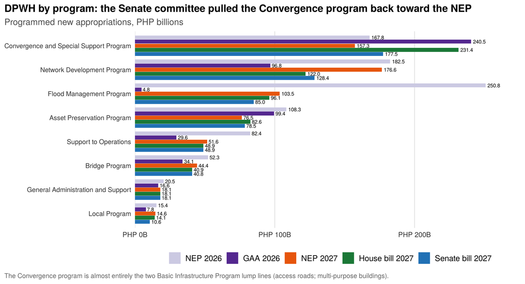

```r
dpl <- dprog %>% select(program, `NEP 2026` = N26, `GAA 2026` = G26, `NEP 2027` = N27, `House bill 2027` = H27, `Senate bill 2027` = S27) %>% pivot_longer(-program) %>%
  mutate(name = factor(name, levels = rev(ver_lv)))
ord_dp <- dprog %>% arrange(S27) %>% pull(program)
ggplot(dpl, aes(value, factor(program, levels = ord_dp), fill = name)) +
  geom_col(position = position_dodge(width = 0.86), width = 0.82) +
  geom_text(aes(label = comma(value, accuracy = 0.1)), position = position_dodge(width = 0.86), hjust = -0.15, size = 2.5) +
  scale_fill_manual(values = ver_pal, breaks = ver_lv) +
  scale_x_continuous(labels = function(x) paste0(peso, comma(x), "B"), expand = expansion(mult = c(0, 0.1))) +
  labs(x = NULL, y = NULL, title = "DPWH by program: the Senate committee pulled the Convergence program back toward the NEP",
       subtitle = "Programmed new appropriations, PHP billions", caption = "The Convergence program is almost entirely the two Basic Infrastructure Program lump lines (access roads; multi-purpose buildings).") +
  theme_pbc() + theme(panel.grid.major.y = element_blank(), panel.grid.major.x = element_line(color = "grey90"), axis.text.y = element_text(size = 9)) + guides(fill = guide_legend(nrow = 1))
```

DPWH falls from ₱654.1B in the House bill to ₱587.9B, which is ₱54.7B below the NEP’s ₱642.6B. The committee took ₱54.0B out of the Convergence program, which the House had raised by ₱74.1B; it is now ₱177.5B, still ₱20.2B above the NEP. Flood management loses a further ₱11.2B and is ₱18.5B below the NEP; asset preservation gives back ₱4.0B of the House’s ₱6.1B; the Local Program loses ₱3.4B. Network Development is the only program that gains, by ₱6.4B, because the restored Laguna Lakeshore, Bataan-Cavite and Mindanao loans sit there; even so it remains ₱48.2B below the NEP, since the committee also cut the locally funded bypass, missing-link and road-widening sub-programs.

The net effect on DPWH’s shape: against the NEP, the department is smaller by ₱55B, the Convergence lump lines are larger by ₱20B, and the national network, bridges and flood programs are smaller by ₱70B. The Senate undid about 73% of the House’s shift toward locally identified projects and did not put the difference back into the national programs; it moved it out of DPWH altogether, into health, rail, education and agriculture.

```r
ss %>% filter(dep == "DPWH", abs(dS) > 0.0005 | abs(dH) > 0.0005) %>% arrange(dS) %>%
  transmute(Program = recode(prog, "1000" = "GAS", "2000" = "STO", "3001" = "Local", "3002" = "Convergence", "3101" = "Asset Preservation", "3102" = "Network Development", "3103" = "Bridge", "3201" = "Flood Management"),
            `Sub-program / project` = PAP, `GAA 2026` = bn(G26), `NEP 2027` = bn(N27), `House bill 2027` = bn(H27), `Senate bill 2027` = bn(S27), `Senate vs House` = fmt_chg(dS), `Senate vs NEP` = fmt_chg(dSN)) %>%
  kbl_clean(font = 11.5, align = c("l", "l", rep("r", 6)), caption = "Every DPWH sub-program and foreign-assisted project changed by either chamber (PHP billions)") %>% column_spec(2, width = "36%") %>% column_spec(7, bold = TRUE)
```

Every DPWH sub-program and foreign-assisted project changed by either chamber (PHP billions)

| Program | Sub-program / project | GAA 2026 | NEP 2027 | House bill 2027 | Senate bill 2027 | Senate vs House | Senate vs NEP |
| --- | --- | --- | --- | --- | --- | --- | --- |
| Convergence | Basic Infrastructure Program (BIP) - Multi-Purpose Buildings / Facilities to support Social Services | 74.7 | 41.0 | 83.7 | 55.6 | -28.06 | +14.67 |
| Convergence | Basic Infrastructure Program (BIP) - Access Roads and/or Bridges from the National Road/s leading to Major / Strategic Public Buildings / Facilities | 33.6 | 105.7 | 135.0 | 110.7 | -24.30 | +4.97 |
| Flood Management | Construction/Maintenance of Flood Mitigation Structures and Drainage Systems | 0.0 | 63.0 | 71.0 | 58.1 | -12.97 | -4.93 |
| Network Development | Construction of By-Pass and Diversion Roads | 36.3 | 46.5 | 44.8 | 37.7 | -7.11 | -8.78 |
| Network Development | Construction of Missing Links/ New Roads | 12.0 | 23.9 | 22.7 | 18.4 | -4.26 | -5.52 |
| Local | Locally-Funded Projects: Buildings and Other Structures - Multipurpose / Facilities - National Building Program | 6.6 | 13.4 | 12.9 | 9.5 | -3.41 | -3.97 |
| Flood Management | Construction/Rehabilitation of Flood Mitigation Facilities within Major River Basins and Principal Rivers | 0.0 | 20.9 | 16.2 | 13.5 | -2.68 | -7.32 |
| Asset Preservation | Preventive Maintenance - Secondary Roads | 15.9 | 11.7 | 14.4 | 11.9 | -2.57 | +0.19 |
| Network Development | Road Widening - Secondary Roads | 18.9 | 10.4 | 10.9 | 8.7 | -2.15 | -1.61 |
| Asset Preservation | Rehabilitation/ Reconstruction/ Upgrading of Damaged Paved Roads - Secondary Roads | 8.7 | 4.7 | 6.6 | 5.1 | -1.50 | +0.36 |
| Asset Preservation | Rehabilitation/ Reconstruction of Roads with Slips, Slope Collapse, and Landslide - Secondary Roads | 10.5 | 4.8 | 5.7 | 4.6 | -1.19 | -0.27 |
| Asset Preservation | Preventive Maintenance - Primary Roads | 12.1 | 13.3 | 14.4 | 13.2 | -1.15 | -0.10 |
| Convergence | Construction/ Rehabilitation of Water Supply/ Septage and Sewerage/ Rain Water Collectors | 1.9 | 7.3 | 8.9 | 7.8 | -1.10 | +0.47 |
| Asset Preservation | Preventive Maintenance - Tertiary Roads | 10.6 | 5.7 | 7.3 | 6.3 | -0.93 | +0.62 |
| Network Development | Off-Carriageway Improvement - Secondary Roads | 1.4 | 2.0 | 3.0 | 2.2 | -0.84 | +0.21 |
| Bridge | Widening of Permanent Bridges | 10.6 | 15.3 | 13.5 | 12.9 | -0.63 | -2.43 |
| Asset Preservation | Construction/ Upgrading/ Rehabilitation of Drainage along National Roads - Secondary Roads | 5.8 | 1.4 | 2.2 | 1.7 | -0.54 | +0.30 |
| Network Development | Road Widening - Tertiary Roads | 4.7 | 1.6 | 2.4 | 1.9 | -0.48 | +0.26 |
| Asset Preservation | Rehabilitation/ Reconstruction/ Upgrading of Damaged Paved Roads - Tertiary Roads | 5.3 | 2.0 | 2.9 | 2.5 | -0.40 | +0.53 |
| Bridge | Retrofitting/ Strengthening of Permanent Bridges | 4.8 | 3.0 | 2.8 | 2.5 | -0.37 | -0.54 |
| Convergence | Basic Infrastructure Program (BIP) - Local Ports and Boat Landings | 0.5 | 0.4 | 0.7 | 0.3 | -0.36 | -0.08 |
| Asset Preservation | Rehabilitation/ Reconstruction of Roads with Slips, Slope Collapse, and Landslide - Tertiary Roads | 9.3 | 2.9 | 3.6 | 3.3 | -0.31 | +0.34 |
| Bridge | Rehabilitation/ Major Repair of Permanent Bridges | 4.5 | 3.9 | 3.8 | 3.6 | -0.29 | -0.31 |
| Network Development | Off-Carriageway Improvement - Tertiary Roads | 0.7 | 0.7 | 1.1 | 0.8 | -0.23 | +0.11 |
| Network Development | Road Widening - Primary Roads | 10.5 | 4.5 | 4.8 | 4.6 | -0.20 | +0.16 |
| Asset Preservation | Construction/ Upgrading/ Rehabilitation of Drainage along National Roads - Primary Roads | 6.7 | 1.7 | 1.7 | 1.5 | -0.19 | -0.17 |
| Asset Preservation | Rehabilitation/ Reconstruction/ Upgrading of Damaged Paved Roads - Primary Roads | 5.4 | 18.3 | 18.6 | 18.4 | -0.18 | +0.10 |
| Asset Preservation | Construction/ Upgrading/ Rehabilitation of Drainage along National Roads - Tertiary Roads | 4.4 | 0.2 | 0.7 | 0.6 | -0.17 | +0.37 |
| Asset Preservation | Rehabilitation/ Reconstruction of Roads with Slips, Slope Collapse, and Landslide - Primary Roads | 4.2 | 1.7 | 1.6 | 1.5 | -0.15 | -0.24 |
| Convergence | Basic Infrastructure Program (BIP) - Coastal Roads to Augment Resiliency of Coastal Communities | 0.3 | 1.4 | 1.7 | 1.5 | -0.15 | +0.14 |
| Bridge | Replacement of Permanent Weak Bridges | 7.4 | 12.0 | 11.7 | 11.5 | -0.14 | -0.48 |
| Bridge | Construction of New Bridges | 3.7 | 4.6 | 5.7 | 5.6 | -0.13 | +1.00 |
| Network Development | Off-Carriageway Improvement - Primary Roads | 0.9 | 1.3 | 1.7 | 1.6 | -0.08 | +0.26 |
| Network Development | Paving of Unpaved Roads - Tertiary Roads | 1.1 | 0.5 | 0.6 | 0.5 | -0.08 | -0.05 |
| STO | Support to Operations | 29.6 | 51.6 | 48.9 | 48.9 | 0.00 | -2.66 |
| Network Development | Foreign-Assisted Project: Cebu-Mactan Bridge (4th Bridge) and Coastal Road Construction Project, JICA Loan No. PH - P274 | 1.5 | 8.6 | 2.6 | 2.6 | 0.00 | -6.00 |
| Network Development | Foreign-Assisted Project: Dalton Pass East Alignment Road Project, JICA Loan No. PH - P280 | 0.1 | 1.1 | 0.6 | 0.6 | 0.00 | -0.50 |
| Network Development | Foreign-Assisted Project: Davao City Bypass Construction Project (II) (South and Center Sections), Package I, JICA Loan No. PH-P273 | 0.6 | 4.4 | 2.4 | 2.4 | 0.00 | -2.00 |
| Network Development | Foreign-Assisted Project: Davao City Bypass Construction Project (III) (South and Center Sections), Package I, JICA Loan No. PH-P282 | 1.0 | 7.4 | 3.9 | 3.9 | 0.00 | -3.50 |
| Network Development | Construction of Flyovers/ Interchanges/ Underpasses/ Long Span Bridges | 1.0 | 0.7 | 0.5 | 0.5 | 0.00 | -0.22 |
| Network Development | Foreign-Assisted Project: Road Network Development Project in Conflict-Affected Areas in Mindanao (RNDP-CAAM), JICA-Assisted | 0.4 | 0.0 | 0.1 | 0.1 | 0.00 | +0.12 |
| Bridge | Replacement of Bridges (Temporary to Permanent) | 0.1 | 0.2 | 0.0 | 0.0 | 0.00 | -0.20 |
| Bridge | Foreign-Assisted Project: Priority Bridges crossing Pasig-Marikina River and Manggahan Floodway Bridges Construction Project, under China Government Financing Facility | 1.6 | 0.0 | 0.3 | 0.3 | 0.00 | +0.33 |
| Bridge | Foreign-Assisted Project: Samal Island Davao City Connector Project CEXIM Loan No GCL20220060763 | 0.3 | 0.0 | 0.1 | 0.1 | 0.00 | +0.05 |
| Bridge | Foreign-Assisted Project: Metro Manila Bridges Project (MMPB), ADB Loan No 4168-PHI | 0.4 | 0.0 | 0.3 | 0.3 | 0.00 | +0.31 |
| Network Development | Foreign-Assisted Project: Samar-Pacific Coastal Road (SPCR) II Project, Provinces of Northern Samar and Eastern Samar in the Eastern Visayas Region | 0.5 | 1.1 | 0.6 | 0.7 | +0.10 | -0.40 |
| Flood Management | Foreign-Assisted Project: Infrastructure Preparation and Innovation Facility (IPIF)-Second Additional Financing, Output 2: Water Projects ADB Loan No. 4424-PHI | 0.6 | 1.1 | 0.9 | 1.1 | +0.25 | 0.00 |
| Flood Management | Foreign-Assisted Project: Integrated Flood Resilience and Adaptation 1 (InFRA I) Project, ADB Loan No. 4345-PHI | 0.6 | 3.1 | 1.6 | 1.8 | +0.25 | -1.25 |
| Bridge | Foreign-Assisted Project: Accelerated Bridge Construction Project for Greater Economic Mobility and Calamity Response, Proposed for French ODA | 0.6 | 1.8 | 1.0 | 1.5 | +0.50 | -0.31 |
| Network Development | Foreign-Assisted Project: Samar Pacific Coastal Road II Project (Laoang II Bridge and Calomotan Bridge), KEDCF Loan No. PHL-26 | 0.5 | 1.5 | 0.7 | 1.5 | +0.75 | 0.00 |
| Network Development | Foreign-Assisted Project: Improving Growth Corridors in Mindanao Road Sector Project (IGCMRSP), ADB Loan No. 3631-PHI | 1.9 | 2.1 | 1.4 | 2.4 | +1.00 | +0.25 |
| Bridge | Foreign-Assisted Project: Metro Manila Priority Bridges for Seismic Design Improvement Project, JICA, PH-P260 | 0.2 | 2.9 | 0.9 | 1.9 | +1.00 | -1.00 |
| Asset Preservation | Foreign-Assisted Project: Reconstruction and Development Plan for Greater Marawi, Stage 2, ADB Loan No. 3769-PHI | 0.3 | 2.9 | 1.1 | 2.9 | +1.75 | 0.00 |
| Flood Management | Foreign-Assisted Project: Cavite Industrial Area Flood Risk Management Project (CIA-FRMP) | 0.6 | 6.6 | 3.1 | 5.1 | +2.00 | -1.50 |
| Flood Management | Foreign-Assisted Project: Pasig - Marikina River Channel Improvement Project (PMRCIP), Phase IV, JICA Loan Nos. PH-P271 and PH-P283 | 1.8 | 8.5 | 3.0 | 5.0 | +2.00 | -3.50 |
| Asset Preservation | Foreign-Assisted Project: Mindanao Transport Connectivity Improvement Project, IBRD Loan No. 9775-PH | 0.0 | 5.2 | 1.7 | 5.2 | +3.50 | 0.00 |
| Network Development | Foreign-Assisted Project: Bataan-Cavite Interlink Bridge (BCIB) Project, ADB Loan No. 4432 - PHI and AIIB Loan No. L0724A | 0.9 | 22.5 | 8.5 | 14.5 | +6.00 | -8.00 |
| Network Development | Foreign-Assisted Project: Laguna Lakeshore Road Network (LLRN) Project - Phase I, KEDCF Loan No. PHL-27, ADB Loan No. 4523-PHI and AIIB Loan No. L0725A | 0.8 | 35.2 | 8.2 | 22.2 | +14.00 | -13.00 |

### 3.8.1 The district engineering offices

```r
ou <- read_excel(dpwh_path, sheet = "NewAppro_ByOperUnit") %>% filter(FY == 2027) %>%
  mutate(across(c(GAA, NEP, HGAB, SGAB), ~ suppressWarnings(as.numeric(.x)) / 1e9),
         kind = case_when(str_detect(Office, "Central") ~ "Central Office", str_detect(Office, "Regional Office") ~ "Regional offices", TRUE ~ "District engineering offices"))
ou_k <- ou %>% group_by(kind) %>% summarise(n = n(), NEP = sum(NEP, na.rm = TRUE), HGAB = sum(HGAB, na.rm = TRUE), SGAB = sum(SGAB, na.rm = TRUE), .groups = "drop") %>%
  mutate(share_n = NEP / sum(NEP) * 100, share_h = HGAB / sum(HGAB) * 100, share_s = SGAB / sum(SGAB) * 100)
deo <- ou %>% filter(kind == "District engineering offices") %>%
  mutate(chgH = HGAB - NEP, chgS = SGAB - HGAB, chgN = SGAB - NEP, pctS = chgS / HGAB * 100, pctN = chgN / NEP * 100,
         office = str_replace(Office, " D\\.E\\. Office$", "") %>% str_replace("District Engineering Office$", "") %>% str_squish(),
         province = str_replace(office, "\\s+(1st|2nd|3rd|4th|5th|6th|7th|First|Second|Third|Fourth)$", "") %>% str_replace("\\s+(City|Lower|Upper)$", "") %>% str_squish())
d_stats <- deo %>% summarise(n = n(), upS = sum(chgS > 0.001), dnS = sum(chgS < -0.001), flatS = sum(abs(chgS) <= 0.001), totS = sum(chgS), medS = median(chgS),
                             upN = sum(chgN > 0.001), dnN = sum(chgN < -0.001), flatN = sum(abs(chgN) <= 0.001), totN = sum(chgN), totH = sum(chgH), medN = median(chgN),
                             top20N = sum(sort(chgN, decreasing = TRUE)[1:20]), top20S = sum(sort(chgS)[1:20]))
co_k <- ou_k %>% filter(kind == "Central Office"); deo_k <- ou_k %>% filter(kind == "District engineering offices")
```

The DPWH workbook breaks the department down by operating unit: the Central Office, 17 regional offices and 198 district engineering offices (DEOs), in each of the three versions. The House had added ₱53.9B to the DEOs and taken ₱42.4B from the Central Office. The Senate committee reversed most of that.

```r
ou_k %>% mutate(kind = factor(kind, levels = c("Central Office", "Regional offices", "District engineering offices"))) %>% arrange(kind) %>%
  transmute(`Operating unit` = kind, Offices = n, `NEP 2027` = bn(NEP), `Share (%)` = sprintf("%.1f", share_n), `House bill 2027` = bn(HGAB), `Share (%) ` = sprintf("%.1f", share_h),
            `Senate bill 2027` = bn(SGAB), `Share (%)  ` = sprintf("%.1f", share_s), `Senate vs House` = fmt_chg(SGAB - HGAB, 1), `Senate vs NEP` = fmt_chg(SGAB - NEP, 1)) %>%
  kbl_clean(font = 12.5, align = c("l", rep("r", 9)), caption = "DPWH new appropriations by type of operating unit (PHP billions)") %>% column_spec(9, bold = TRUE)
```

DPWH new appropriations by type of operating unit (PHP billions)

| Operating unit | Offices | NEP 2027 | Share (%) | House bill 2027 | Share (%) | Senate bill 2027 | Share (%) | Senate vs House | Senate vs NEP |
| --- | --- | --- | --- | --- | --- | --- | --- | --- | --- |
| Central Office | 1 | 510.0 | 79.4 | 467.6 | 71.5 | 439.4 | 74.7 | -28.2 | -70.6 |
| Regional offices | 17 | 2.9 | 0.5 | 2.9 | 0.4 | 2.9 | 0.5 | 0.00 | 0.00 |
| District engineering offices | 198 | 129.7 | 20.2 | 183.6 | 28.1 | 145.6 | 24.8 | -38.0 | +15.9 |

The district offices lose ₱38.0B against the House bill: 154 of the 198 DEOs are cut, 44 are unchanged, and none gains. Their share of DPWH falls from 28% in the House bill to 25%, against 20% in the NEP. The Central Office also falls further, to ₱439.4B from ₱467.6B, as the committee cut the centrally held flood-control and bypass sub-programs; it is ₱70.6B below the NEP. Against the NEP, the DEOs remain ₱15.9B higher in total, with 108 offices above their NEP amount and 65 below.

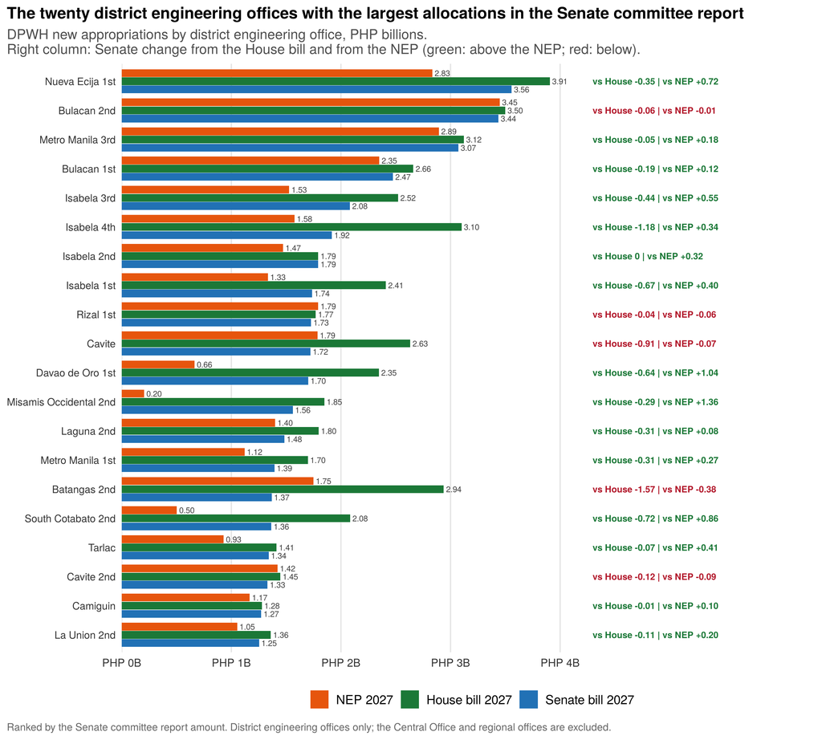

```r
deo20 <- deo %>% slice_max(SGAB, n = 20)
deo_top <- deo20 %>% select(office, `NEP 2027` = NEP, `House bill 2027` = HGAB, `Senate bill 2027` = SGAB) %>% pivot_longer(-office) %>%
  mutate(name = factor(name, levels = rev(names(v3_pal))))
ord_deo <- deo20 %>% arrange(SGAB) %>% pull(office)
xmax <- max(deo20$SGAB, deo20$HGAB, deo20$NEP)
deo_lab <- deo20 %>% mutate(x = xmax * 1.1,
  lab = sprintf("vs House %s | vs NEP %s", ifelse(abs(chgS) < 0.0005, "0", sprintf("%s%s", ifelse(chgS > 0, "+", ""), comma(chgS, accuracy = 0.01))), ifelse(abs(chgN) < 0.0005, "0", sprintf("%s%s", ifelse(chgN > 0, "+", ""), comma(chgN, accuracy = 0.01)))))
ggplot(deo_top, aes(value, factor(office, levels = ord_deo))) +
  geom_col(aes(fill = name), position = position_dodge(width = 0.84), width = 0.8) +
  geom_text(aes(label = comma(value, accuracy = 0.01), group = name), position = position_dodge(width = 0.84), hjust = -0.15, size = 2.5, color = "grey25") +
  geom_text(data = deo_lab, aes(x = x, y = factor(office, levels = ord_deo), label = lab, color = ifelse(chgN > 0, "up", ifelse(chgN < 0, "dn", "flat"))), hjust = 0, size = 2.75, fontface = "bold", show.legend = FALSE) +
  scale_fill_manual(values = v3_pal, breaks = names(v3_pal)) +
  scale_color_manual(values = c(up = up_col, dn = dn_col, flat = "grey40")) +
  scale_x_continuous(labels = function(x) paste0(peso, comma(x), "B"), limits = c(0, xmax * 1.62), breaks = seq(0, ceiling(xmax), 1), expand = expansion(mult = c(0, 0))) +
  labs(x = NULL, y = NULL, title = "The twenty district engineering offices with the largest allocations in the Senate committee report",
       subtitle = "DPWH new appropriations by district engineering office, PHP billions.\nRight column: Senate change from the House bill and from the NEP (green: above the NEP; red: below).",
       caption = "Ranked by the Senate committee report amount. District engineering offices only; the Central Office and regional offices are excluded.") +
  theme_pbc() + theme(panel.grid.major.y = element_blank(), panel.grid.major.x = element_line(color = "grey90"), axis.text.y = element_text(size = 9)) + guides(fill = guide_legend(nrow = 1))
```

The best-funded DEO in the committee report is Nueva Ecija 1st at ₱3.6B (₱2.8B in the NEP, ₱3.9B in the House bill). Ilocos Norte 1st, which the House had made the best-funded district office in the country at ₱4.8B from ₱414M, is cut to ₱937M, still ₱522M above the NEP. The top twenty are led by the Nueva Ecija, Bulacan, Isabela, Metro Manila, Cavite and Rizal offices, most of which were also at the top of the NEP list, with Davao de Oro 1st and Misamis Occidental 2nd the two offices whose House-stage jumps survived largely intact.

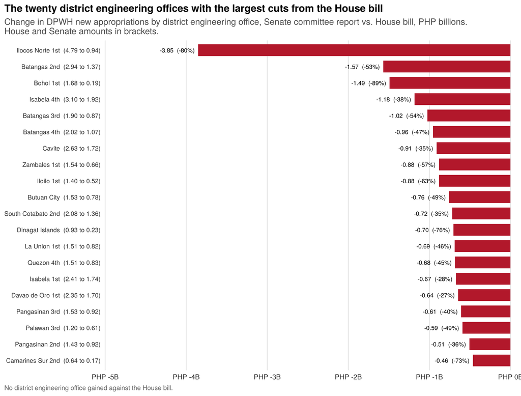

```r
deo_dn <- deo %>% slice_min(chgS, n = 20) %>% mutate(lab = sprintf("%s  (%s to %s)", office, comma(HGAB, accuracy = 0.01), comma(SGAB, accuracy = 0.01)))
ggplot(deo_dn, aes(chgS, reorder(lab, -chgS))) +
  geom_col(fill = dn_col, width = 0.72) +
  geom_text(aes(label = sprintf("%s  (%+.0f%%)", comma(chgS, accuracy = 0.01), pctS)), hjust = 1.1, size = 2.9) +
  scale_x_continuous(labels = function(x) paste0(peso, comma(x), "B"), expand = expansion(mult = c(0.3, 0.02))) +
  labs(x = NULL, y = NULL, title = "The twenty district engineering offices with the largest cuts from the House bill",
       subtitle = "Change in DPWH new appropriations by district engineering office, Senate committee report vs. House bill, PHP billions.\nHouse and Senate amounts in brackets.",
       caption = "No district engineering office gained against the House bill.") +
  theme_pbc() + theme(panel.grid.major.y = element_blank(), panel.grid.major.x = element_line(color = "grey90"), axis.text.y = element_text(size = 8.6))
```

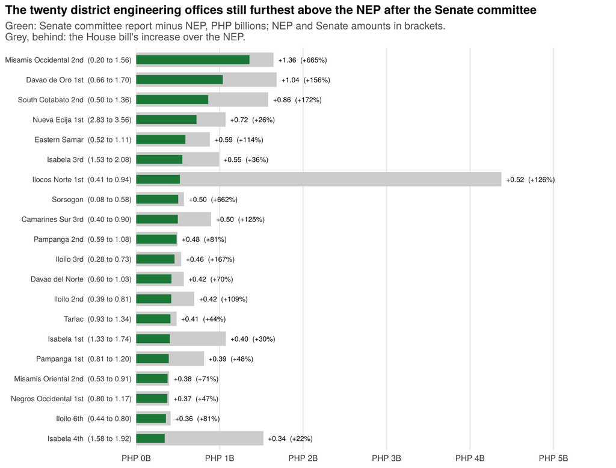

```r
deo_up <- deo %>% slice_max(chgN, n = 20) %>% mutate(lab = sprintf("%s  (%s to %s)", office, comma(NEP, accuracy = 0.01), comma(SGAB, accuracy = 0.01)))
ggplot(deo_up, aes(chgN, reorder(lab, chgN))) +
  geom_col(aes(x = chgH), fill = "grey80", width = 0.72) +
  geom_col(fill = up_col, width = 0.45) +
  geom_text(aes(x = pmax(chgN, chgH), label = sprintf("+%s  (%+.0f%%)", comma(chgN, accuracy = 0.01), pctN)), hjust = -0.1, size = 2.9) +
  scale_x_continuous(labels = function(x) paste0(peso, comma(x), "B"), expand = expansion(mult = c(0, 0.3))) +
  labs(x = NULL, y = NULL, title = "The twenty district engineering offices still furthest above the NEP after the Senate committee",
       subtitle = "Green: Senate committee report minus NEP, PHP billions; NEP and Senate amounts in brackets.\nGrey, behind: the House bill's increase over the NEP.") +
  theme_pbc() + theme(panel.grid.major.y = element_blank(), panel.grid.major.x = element_line(color = "grey90"), axis.text.y = element_text(size = 8.6))
```

The twenty largest cuts take ₱19.8B, 52% of the DEO total, and fall mostly on the offices that had gained most at the House stage: Ilocos Norte 1st (−₱3.9B), the Batangas offices, Bohol 1st, Isabela 4th, Cavite and Zambales 1st. Against the NEP, the twenty offices still furthest up hold ₱11.1B of the remaining ₱15.9B DEO increase; the provinces whose offices gain most in total are Isabela (₱1.6B across 5 offices), Misamis Occidental (₱1.6B), Davao de Oro (₱1.2B), Pampanga (₱1.0B) and Iloilo (₱1.0B). The median DEO is ₱23M above its NEP amount.

The committee says the projects it removed failed its five documentary safeguards. That is the standard PBC asked for at the House stage, and the committee has published the result: Annex A-4 lists every project under every DPWH sub-program by implementing office, with coordinates, the House amount, and the committee’s deletion or retention, down to individual multi-purpose buildings and access roads. The ₱15.9B that remains above the NEP in the DEOs and the ₱166B in the two BIP lines are therefore no longer unlisted; the questions that remain are who identified the surviving projects, which sub-programs they sit in by office (the annex has it, this report has not yet encoded it), and whether the list travels intact into the enrolled bill. The committee also deleted DPWH’s special provision on project modification (Annex B), which narrows the department’s room to change listed projects after enactment.

```r
deo %>% arrange(desc(SGAB)) %>%
  transmute(`District engineering office` = Office, Province = province, `NEP 2027` = NEP, `House bill 2027` = HGAB, `Senate bill 2027` = SGAB, `Senate vs House` = chgS, `Senate vs House (%)` = pctS, `Senate vs NEP` = chgN, `Senate vs NEP (%)` = pctN) %>%
  dt_table(caption = "All district engineering offices across the three versions (PHP billions). Sort by any column.", page = 20,
           money_cols = c("NEP 2027", "House bill 2027", "Senate bill 2027", "Senate vs House", "Senate vs NEP"), money_digits = 3, pct_cols = c("Senate vs House (%)", "Senate vs NEP (%)"))
```

| District engineering office | Province | NEP 2027 | House bill 2027 | Senate bill 2027 | Senate vs House | Senate vs House (%) | Senate vs NEP | Senate vs NEP (%) |
| --- | --- | --- | --- | --- | --- | --- | --- | --- |
| Nueva Ecija 1st D.E. Office | Nueva Ecija | 2.834047 | 3.905617 | 3.557136 | -0.348481 | -8.92255948291909 | 0.7230889999999999 | 25.51436161785601 |
| Bulacan 2nd D.E. Office | Bulacan | 3.448647 | 3.498647 | 3.436993 | -0.06165399999999988 | -1.762224082623937 | -0.01165399999999961 | -0.3379296286340588 |
| Metro Manila 3rd D.E. Office | Metro Manila | 2.893031 | 3.121631 | 3.071631 | -0.04999999999999982 | -1.601726789617345 | 0.1785999999999999 | 6.173456143401155 |
| Bulacan 1st D.E. Office | Bulacan | 2.350438 | 2.660438 | 2.474438 | -0.1859999999999999 | -6.991329999045267 | 0.1240000000000001 | 5.275612460315911 |
| Isabela 3rd D.E. Office | Isabela | 1.527535 | 2.520845 | 2.081242 | -0.439603 | -17.43871598610783 | 0.553707 | 36.24840020032274 |
| Isabela 4th D.E. Office | Isabela | 1.576451 | 3.100768 | 1.917368 | -1.1834 | -38.16473854219342 | 0.3409169999999999 | 21.62560079571137 |
| Isabela 2nd D.E. Office | Isabela | 1.472393 | 1.792523 | 1.792523 | 0 | 0 | 0.32013 | 21.74215715505303 |
| Isabela 1st D.E. Office | Isabela | 1.333737 | 2.409252 | 1.735617 | -0.673635 | -27.9603378974055 | 0.40188 | 30.13187757406445 |
| Rizal 1st D.E. Office | Rizal | 1.792421 | 1.770421 | 1.727421 | -0.04299999999999993 | -2.428800833248133 | -0.06499999999999995 | -3.626380186351307 |
| Cavite D.E. Office | Cavite | 1.786287 | 2.632287 | 1.721082 | -0.9112049999999998 | -34.61647609094297 | -0.06520499999999996 | -3.650309272810022 |

[output cut: 188 more lines]

```r
prov %>% arrange(desc(SGAB)) %>%
  transmute(Province = province, `DEOs` = offices, `NEP 2027` = NEP, `House bill 2027` = HGAB, `Senate bill 2027` = SGAB, `Senate vs House` = chgS, `Senate vs NEP` = chgN, `Senate vs NEP (%)` = pctN) %>%
  dt_table(caption = "District engineering offices grouped by province (PHP billions). Provinces are inferred from office names.", page = 15,
           money_cols = c("NEP 2027", "House bill 2027", "Senate bill 2027", "Senate vs House", "Senate vs NEP"), money_digits = 3, pct_cols = "Senate vs NEP (%)")
```

| Province | DEOs | NEP 2027 | House bill 2027 | Senate bill 2027 | Senate vs House | Senate vs NEP | Senate vs NEP (%) |
| --- | --- | --- | --- | --- | --- | --- | --- |
| Isabela | 5 | 5.984506000000001 | 9.897778 | 7.60114 | -2.296638 | 1.616634 | 27.01365827020642 |
| Bulacan | 3 | 6.400631 | 6.815631 | 6.462977 | -0.3526539999999998 | 0.06234600000000046 | 0.9740602137508078 |
| Metro Manila | 3 | 4.973499 | 5.859675 | 5.449675 | -0.41 | 0.4761759999999998 | 9.574265522120339 |
| Quezon | 6 | 4.316145 | 6.545024 | 4.992173 | -1.552851 | 0.6760280000000003 | 15.6627731459439 |
| Cebu | 8 | 5.458151 | 5.690041 | 4.281525999999999 | -1.408515 | -1.176625 | -21.55720865912284 |
| Nueva Ecija | 2 | 3.18857 | 4.21014 | 3.811659 | -0.398481 | 0.6230889999999999 | 19.54133043966417 |
| Iloilo | 6 | 2.740609 | 5.560997 | 3.714089 | -1.846908 | 0.9734800000000001 | 35.52057225237164 |
| Cavite | 3 | 4.049317 | 4.968017 | 3.61527 | -1.352747 | -0.434047 | -10.71901755283669 |
| Negros Occidental | 5 | 2.904633 | 3.682533 | 3.539033 | -0.1435 | 0.6343999999999999 | 21.84096923776601 |
| Batangas | 4 | 4.133077 | 7.141592 | 3.41495 | -3.726642 | -0.7181269999999998 | -17.37511786013181 |

[output cut: 82 more lines]

# 4 How the committee report answers the People’s Budget Proposals

PBC submitted People’s Budget Proposals (PBPs) three times this season: to the House on 27 August, to the Senate on 9 September, and a consolidated pre-SGAB set on 3 November, after the House bill, with 52 items from ten member organizations across the Accountability, Rights and Environment, Education and Health, and Labor and Social Protection clusters. The Move As One Coalition filed a companion set of 14 road-transport proposals on 9 November, built on DOTr’s own original budget request. Each proposal with an amount is followed below through the NEP, the House bill and the committee report; the interpellation and special-provision asks are set against what the committee report’s annexes contain.

## 4.1 The proposals with amounts

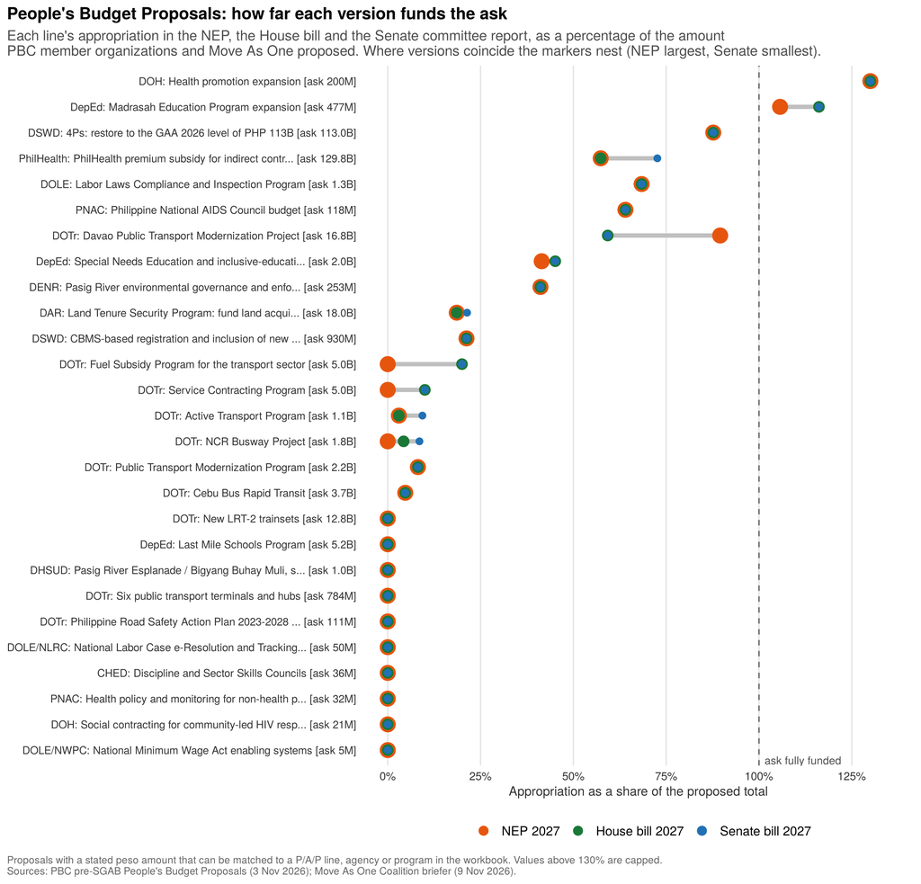

```r
pf <- pbp %>% filter(trackable, !is.na(askT), askT > 0) %>%
  mutate(lab = sprintf("%s: %s [ask %s]", agency, str_trunc(str_remove(proposal, " \\(.*$"), 48), ifelse(askT >= 1, paste0(comma(askT, accuracy = 0.1), "B"), paste0(comma(askT * 1000, accuracy = 1), "M")))) %>%
  select(lab, askT, `NEP 2027` = N27, `House bill 2027` = H27, `Senate bill 2027` = S27) %>%
  mutate(across(c(`NEP 2027`, `House bill 2027`, `Senate bill 2027`), ~ pmin(.x / askT * 100, 130))) %>%
  pivot_longer(-c(lab, askT), names_to = "ver", values_to = "share") %>% mutate(ver = factor(ver, levels = names(v3_pal)))
ord_pf <- pf %>% filter(ver == "Senate bill 2027") %>% arrange(share, askT) %>% pull(lab)
ggplot(pf, aes(share, factor(lab, levels = ord_pf))) +
  geom_vline(xintercept = 100, linetype = "dashed", color = "grey40") +
  geom_line(aes(group = lab), color = "grey75", linewidth = 1.6) +
  geom_point(aes(color = ver, size = ver)) +
  scale_size_manual(values = c("NEP 2027" = 5.2, "House bill 2027" = 3.6, "Senate bill 2027" = 2.2), guide = "none") +
  annotate("text", x = 101.5, y = 0.6, label = "ask fully funded", hjust = 0, size = 3, color = "grey30") +
  scale_color_manual(values = v3_pal, breaks = names(v3_pal)) +
  scale_x_continuous(labels = function(x) paste0(x, "%"), limits = c(0, 135), breaks = seq(0, 125, 25)) +
  labs(x = "Appropriation as a share of the proposed total", y = NULL,
       title = "People's Budget Proposals: how far each version funds the ask",
       subtitle = "Each line's appropriation in the NEP, the House bill and the Senate committee report, as a percentage of the amount\nPBC member organizations and Move As One proposed. Where versions coincide the markers nest (NEP largest, Senate smallest).",
       caption = "Proposals with a stated peso amount that can be matched to a P/A/P line, agency or program in the workbook. Values above 130% are capped.\nSources: PBC pre-SGAB People's Budget Proposals (3 Nov 2026); Move As One Coalition briefer (9 Nov 2026).") +
  theme_pbc(11) + theme(panel.grid.major.y = element_blank(), panel.grid.major.x = element_line(color = "grey90"), axis.text.y = element_text(size = 8.4)) + guides(color = guide_legend(nrow = 1, override.aes = list(size = 3)))
```

```r
pbp %>% filter(!is.na(askT) | !is.na(ask_inc) | (src == "PBC" & no == 27)) %>% arrange(src, no) %>%
  transmute(Source = ifelse(src == "PBC", paste0("PBC #", no), paste0("MAO #", no)), Cluster = cluster, Agency = agency, Organization = cso, Proposal = proposal,
            `Proposed increase` = ifelse(is.na(askI), "provision", bn(askI, 3)), `Proposed total` = ifelse(is.na(askT), "", bn(askT, 3)),
            `GAA 2026` = ifelse(is.na(G26), "", bn(G26, 3)), `NEP 2027` = ifelse(is.na(N27), "", bn(N27, 3)), `House bill 2027` = ifelse(is.na(H27), "", bn(H27, 3)), `Senate bill 2027` = ifelse(is.na(S27), "", bn(S27, 3)),
            `Senate vs House` = ifelse(is.na(dS), "", fmt_chg(dS, 3)), `Where the Senate leaves it` = status) %>%
  kbl_clean(font = 10.5, align = c("l", "l", "l", "l", "l", rep("r", 7), "l"), caption = "People's Budget Proposals with a stated amount, against the three versions of the FY 2027 budget (PHP billions)") %>%
  column_spec(5, width = "24%") %>% column_spec(12, bold = TRUE) %>% column_spec(13, width = "11%")
```

People’s Budget Proposals with a stated amount, against the three versions of the FY 2027 budget (PHP billions)

| Source | Cluster | Agency | Organization | Proposal | Proposed increase | Proposed total | GAA 2026 | NEP 2027 | House bill 2027 | Senate bill 2027 | Senate vs House | Where the Senate leaves it |
| --- | --- | --- | --- | --- | --- | --- | --- | --- | --- | --- | --- | --- |
| MAO #1 | Transport | DOTr | Move As One | NCR Busway Project (including the EDSA Busway) | 1.681 | 1.756 | 0.089 | 0.000 | 0.075 | 0.150 | +0.075 | Moved toward the ask |
| MAO #2 | Transport | DOTr | Move As One | Active Transport Program (walking and cycling) | 1.094 | 1.128 | 0.105 | 0.034 | 0.034 | 0.105 | +0.072 | Moved toward the ask |
| MAO #3 | Transport | DOTr | Move As One | Service Contracting Program | 4.500 | 5.000 | 1.000 | 0.000 | 0.500 | 0.500 | 0.00 | No change from the House bill |
| MAO #4 | Transport | DOTr | Move As One | Fuel Subsidy Program for the transport sector | 4.000 | 5.000 | 0.000 | 0.000 | 1.000 | 1.000 | 0.00 | No change from the House bill |
| MAO #5 | Transport | DOTr | Move As One | Public Transport Modernization Program (PTMP) | 2.000 | 2.177 | 1.532 | 0.177 | 0.177 | 0.177 | 0.00 | No change from the House bill |
| MAO #6 | Transport | DOTr | Move As One | Philippine Road Safety Action Plan 2023-2028 implementation (new) | 0.111 | 0.111 | 0.000 | 0.000 | 0.000 | 0.000 | 0.00 | No change from the House bill |
| MAO #7 | Transport | DOTr | Move As One | Cebu Bus Rapid Transit | 3.542 | 3.718 | 0.433 | 0.175 | 0.175 | 0.175 | 0.00 | No change from the House bill |
| MAO #8 | Transport | DOTr | Move As One | New LRT-2 trainsets (new) | 12.800 | 12.800 | 0.000 | 0.000 | 0.000 | 0.000 | 0.00 | No change from the House bill |
| MAO #9 | Transport | DOTr | Move As One | Six public transport terminals and hubs (Ilocos Norte, Nueva Ecija, Masbate, two in Bataan, Marinduque) | 0.784 | 0.784 | 0.000 | 0.000 | 0.000 | 0.000 | 0.00 | No change from the House bill |
| MAO #10 | Transport | DOTr | Move As One | Davao Public Transport Modernization Project (restore to DOTr request) | 6.858 | 16.838 | 1.741 | 15.077 | 9.977 | 9.977 | 0.00 | No change from the House bill |
| PBC #1 | ARE | DENR | Ilog Pasiglahin | Pasig River environmental governance and enforcement (PRCMO) | 0.150 | 0.253 | 0.103 | 0.104 | 0.104 | 0.104 | 0.00 | No change from the House bill |
| PBC #2 | ARE | DHSUD | Ilog Pasiglahin | Pasig River Esplanade / Bigyang Buhay Muli, sustained funding | 1.000 | 1.000 | 0.000 | 0.000 | 0.000 | 0.000 | 0.00 | No change from the House bill |
| PBC #5 | ARE | PCW | PANTAY | Philippine Commission on Women, gender and development budget | 0.029 | 0.065 | 0.065 | 0.036 | 0.178 |  |  | Not visible at P/A/P level |
| PBC #6 | ARE | NYC | PANTAY | HIV knowledge and capacity development (Hakdaw Kabataan trainings) | 0.007 | 0.009 | 0.002 |  |  |  |  | Not visible at P/A/P level |
| PBC #7 | ARE | NYC | PANTAY | PRIDE activities | 0.003 | 0.003 | 0.000 |  |  |  |  | Not visible at P/A/P level |
| PBC #15 | E&H | DepEd | PANTAY | HIV knowledge and capacity development program | 0.003 | 0.022 | 0.019 |  |  |  |  | Not visible at P/A/P level |
| PBC #17 | E&H | DepEd | Multiply-Ed | Special Needs Education and inclusive-education teachers (special provision, PHP 2.05B) | provision | 2.050 | 1.044 | 0.850 | 0.925 | 0.925 | 0.00 | No change from the House bill |
| PBC #18 | E&H | DepEd | Multiply-Ed | Madrasah Education Program expansion (special provision, PHP 477M) | provision | 0.477 | 0.522 | 0.504 | 0.554 | 0.554 | 0.00 | Met or exceeded |
| PBC #19 | E&H | DepEd | Multiply-Ed | Last Mile Schools Program (RA 12321): restore the zeroed line | 5.250 | 5.250 | 0.000 | 0.000 | 0.000 | 0.000 | 0.00 | No change from the House bill |
| PBC #21 | E&H | CHED | PBEd | Discipline and Sector Skills Councils (new) | 0.036 | 0.036 | 0.000 | 0.000 | 0.000 | 0.000 | 0.00 | No change from the House bill |
| PBC #26 | E&H | PhilHealth | ACRI | PhilHealth premium subsidy for indirect contributors, non-discretionary transfer | 76.648 | 129.782 | 129.782 | 74.449 | 74.449 | 94.249 | +19.800 | Moved toward the ask |
| PBC #27 | E&H | DOH | ACRI | MAIFIP/MAP: rationalization toward PhilHealth (special provision on PHP 51.65B) | provision |  | 51.648 | 24.238 | 48.204 | 16.200 | -32.003 | Redirected toward hospitals and PhilHealth (see text) |
| PBC #31 | E&H | DOH | PANTAY | HIV prevention commodity procurement | 0.685 | 1.350 | 0.666 |  |  |  |  | Not visible at P/A/P level |
| PBC #32 | E&H | DOH | PANTAY | Health promotion expansion (special provision, PHP 200M) | 0.200 | 0.200 | 1.115 | 2.535 | 0.485 | 1.584 | +1.099 | Met or exceeded |
| PBC #33 | E&H | DOH | PANTAY | Social contracting for community-led HIV response (new) | 0.021 | 0.021 | 0.000 | 0.000 | 0.000 | 0.000 | 0.00 | No change from the House bill |
| PBC #34 | E&H | PNAC | PANTAY | Health policy and monitoring for non-health programs (new) | 0.032 | 0.032 | 0.000 | 0.000 | 0.000 | 0.000 | 0.00 | No change from the House bill |
| PBC #35 | E&H | PNAC | PANTAY | Philippine National AIDS Council budget | 0.051 | 0.118 | 0.063 | 0.076 | 0.076 | 0.076 | 0.00 | No change from the House bill |
| PBC #37 | LSP | DAR | Task Force Mapalad | Land Tenure Security Program: fund land acquisition and distribution to complete LAD by 2027 | 16.200 | 18.000 | 3.563 | 3.346 | 3.346 | 3.846 | +0.500 | Moved toward the ask |
| PBC #42 | LSP | DOLE | NFL-KMG | Labor Laws Compliance and Inspection Program | 0.357 | 1.283 | 0.823 | 0.877 | 0.877 | 0.877 | 0.00 | No change from the House bill |
| PBC #43 | LSP | DOLE/NLRC | NFL-KMG | National Labor Case e-Resolution and Tracking System (special provision, new) | 0.050 | 0.050 | 0.000 | 0.000 | 0.000 | 0.000 | 0.00 | No change from the House bill |
| PBC #44 | LSP | DOLE/NWPC | NFL-KMG | National Minimum Wage Act enabling systems (special provision, new) | 0.005 | 0.005 | 0.000 | 0.000 | 0.000 | 0.000 | 0.00 | No change from the House bill |
| PBC #46 | LSP | DSWD | SNPP | 4Ps: restore to the GAA 2026 level of PHP 113B | 13.900 | 112.997 | 112.997 | 99.075 | 99.075 | 99.075 | 0.00 | No change from the House bill |
| PBC #47 | LSP | DSWD | SNPP | CBMS-based registration and inclusion of new beneficiaries | 0.740 | 0.930 | 0.190 | 0.197 | 0.197 | 0.197 | 0.00 | No change from the House bill |
| PBC #48 | LSP | DSWD | SNPP | SNPP case-management staffing (within 4Ps) | 3.087 | 15.647 | 12.560 | 16.200 | 16.200 |  |  | Not visible at P/A/P level |
| PBC #49 | LSP | DSWD | SNPP | Parent-leader capacity, retention and graduation pipeline (within 4Ps) | 0.828 | 6.138 | 5.310 | 5.120 | 5.120 |  |  | Not visible at P/A/P level |
| PBC #51 | LSP | DSWD | PANTAY | Medical and psychosocial assistance for PLHIVs through AICS (special provision, PHP 5.07B) | provision | 5.069 | 0.000 |  |  |  |  | Not visible at P/A/P level |
| PBC #52 | LSP | DSWD | PANTAY | Office of the Undersecretary for LGBTQIA+ Affairs | 0.029 | 0.033 | 0.001 | 0.004 | 0.004 |  |  | Not visible at P/A/P level |

Workbook figures are programmed new appropriations for the matching P/A/P line; for PNAC they are the agency’s whole budget and for PhilHealth and DAR’s Land Tenure Security Program the program total, so they can differ from the sub-line figures the submissions cite. “Not visible at P/A/P level” means the ask is for a component below the line (a staffing sub-item inside 4Ps, an HIV sub-line inside the communicable-disease commodities, the gender and development budget inside PCW) that the workbook does not carry; for those rows the GAA, NEP and House figures are the submissions’ own and the Senate column is left blank. For PBC item 37 the workbook figures are the three land-acquisition lines of DAR’s Land Tenure Security Program; Task Force Mapalad’s 2026 figure of ₱18B includes the Agrarian Reform Fund’s automatic appropriations, and the proposed total is the restoration to that level.

The gains are concentrated in three places. PhilHealth is the largest single proposal (₱76.6B, to restore the premium subsidy to ₱129.8B) and the largest single Senate addition: the committee’s ₱19.8B takes the subsidy from 57% to 73% of the ask. Health promotion, where PANTAY asked for a ₱200M earmark, is raised by ₱1.1B to ₱1.6B, still below the NEP but well above the ask. The DAR landowners’ compensation line, part of Task Force Mapalad’s land-tenure proposal, rises from ₱100M to ₱600M, a small step toward a ₱16.2B ask (the program’s three land-acquisition lines total ₱3.85B in the committee report against ₱18B enacted for 2026 by TFM’s count). Among Move As One’s items, the NCR Busway doubles to ₱150M and the Active Transport Program is restored to its 2026 level of ₱105M; both remain under 10% of DOTr’s own original request.

The MAP item is a special case. ACRI proposed a redirection, with no increase attached: rationalize the ₱51.65B medical-assistance appropriation toward PhilHealth through a special provision. The committee did something close to that in substance, cutting MAP from ₱48.2B to ₱16.2B and moving the money into DOH hospital operations for zero balance billing and ₱19.8B into PhilHealth, while rewriting the MAP provision to limit it to indigent or financially incapacitated patients and route it through hospitals. The amounts differ from the proposal, the design follows it.

## 4.2 The interpellation and special-provision asks

```r
tibble::tribble(~Item, ~Cluster, ~Agency, ~Organization, ~Ask, ~`What the committee report contains`,
  "PBC #3",  "ARE", "DOTr",  "Ilog Pasiglahin", "Pasig River ferry and MAPALLA implementation", "No appropriation-line or provision change found.",
  "PBC #4",  "ARE", "DPWH",  "Ilog Pasiglahin", "PAREX cancellation", "Not addressed in Annex A-4 or Annex B.",
  "PBC #8",  "ARE", "NYC",   "PANTAY", "Special provision for LGBTQIA+-focused programs (PHP 630K)", "None found for NYC. Annex B adds a PHP 20M earmark in DSWD for the Special Committee on LGBTQIA+ Affairs under E.O. 51, s. 2023 (see PBC #52).",
  "PBC #9 to 11", "E&H", "DepEd", "PBEd", "Protect education investments; ARAL Program funding; EDCOM II gaps", "Basic Education Facilities cut by a further PHP 6.5B; school feeding doubled; no ARAL provision found.",
  "PBC #12 to 13", "E&H", "DepEd/TEC", "PBEd", "Teacher Education Scholarship Program; education data infrastructure", "No change found.",
  "PBC #14, 20", "E&H", "DepEd", "PANTAY, Multiply-Ed", "Learner support centers; inclusive-education budget tag and school-infrastructure transparency", "No provision found. Annex A-4 itemizes DPWH-built school buildings by office.",
  "PBC #16", "E&H", "DepEd", "Multiply-Ed", "Inclusive Learning Resource Centers under RA 11650 (special provision, PHP 2.61B)", "No provision found.",
  "PBC #22 to 23, 45", "E&H", "CHED/TESDA", "PBEd", "National Education Plan industry-aligned curriculum; education data", "No change found.",
  "PBC #24 to 25", "E&H", "DOH", "PBC, ACRI", "HFEP: inequitable distribution; health centers and contracting", "HFEP raised by PHP 5.5B to PHP 15.6B; Annex A-2 lists every facility funded; EAO cap raised to 2%.",
  "PBC #28", "E&H", "DOH", "PBC", "MAIFIP guarantee letters", "MAP cut to PHP 16.2B; provision limits it to indigent or financially incapacitated patients and routes assistance through hospitals; zero-balance-billing funds added to DOH hospitals.",
  "PBC #29", "E&H", "DOH", "ACRI, PBC", "NHWSS deployment expansion and GIDA retention incentive", "NHWSS unchanged at PHP 25.4B; Health Workforce Management restored to the NEP's PHP 278M.",
  "PBC #30", "E&H", "DOH", "ACRI, PBC", "Boosting primary care", "Family-health and immunization commodities +PHP 1.6B (still PHP 3.3B below the NEP); health promotion +PHP 1.1B; PHP 300M mental-health medicines earmark added.",
  "PBC #36", "E&H", "PhilHealth", "PANTAY", "Medical and psychosocial assistance for PLHIVs (OHAT package)", "No provision found; PhilHealth subsidy +PHP 19.8B.",
  "PBC #38", "LSP", "DAR/PARC", "Task Force Mapalad", "Agrarian Reform Fund accountability", "No provision found; DAR gets a new PHP 600M quick response fund with El Niño uses.",
  "PBC #39 to 41", "LSP", "DA", "Task Force Mapalad", "Chemical-intensive farming; nature-based solutions for rice straw; project insertions in the DA budget", "PHP 20B Animal Industry project deleted and its special provision removed; organic-agriculture production support +PHP 41M; farm-to-market roads back to the NEP with a project annex (A-1).",
  "PBC #50", "LSP", "DSWD", "SNPP", "Harmonization and non-discretionary targeting of 4Ps and Walang Gutom", "No provision found; both lines unchanged.",
  "MAO", "Transport", "DPWH", "Move As One", "Interpellation on road-space allocation and active-transport infrastructure", "Annex A-4 itemizes DPWH projects; no active-transport provision found."
) %>% kbl_clean(font = 11, align = c("l", "l", "l", "l", "l", "l"), caption = "Interpellation and special-provision asks in the People's Budget Proposals, against the committee report and its annexes") %>%
  column_spec(5, width = "28%") %>% column_spec(6, width = "36%")
```

Interpellation and special-provision asks in the People’s Budget Proposals, against the committee report and its annexes

| Item | Cluster | Agency | Organization | Ask | What the committee report contains |
| --- | --- | --- | --- | --- | --- |
| PBC #3 | ARE | DOTr | Ilog Pasiglahin | Pasig River ferry and MAPALLA implementation | No appropriation-line or provision change found. |
| PBC #4 | ARE | DPWH | Ilog Pasiglahin | PAREX cancellation | Not addressed in Annex A-4 or Annex B. |
| PBC #8 | ARE | NYC | PANTAY | Special provision for LGBTQIA+-focused programs (PHP 630K) | None found for NYC. Annex B adds a PHP 20M earmark in DSWD for the Special Committee on LGBTQIA+ Affairs under E.O. 51, s. 2023 (see PBC #52). |
| PBC #9 to 11 | E&H | DepEd | PBEd | Protect education investments; ARAL Program funding; EDCOM II gaps | Basic Education Facilities cut by a further PHP 6.5B; school feeding doubled; no ARAL provision found. |
| PBC #12 to 13 | E&H | DepEd/TEC | PBEd | Teacher Education Scholarship Program; education data infrastructure | No change found. |
| PBC #14, 20 | E&H | DepEd | PANTAY, Multiply-Ed | Learner support centers; inclusive-education budget tag and school-infrastructure transparency | No provision found. Annex A-4 itemizes DPWH-built school buildings by office. |
| PBC #16 | E&H | DepEd | Multiply-Ed | Inclusive Learning Resource Centers under RA 11650 (special provision, PHP 2.61B) | No provision found. |
| PBC #22 to 23, 45 | E&H | CHED/TESDA | PBEd | National Education Plan industry-aligned curriculum; education data | No change found. |
| PBC #24 to 25 | E&H | DOH | PBC, ACRI | HFEP: inequitable distribution; health centers and contracting | HFEP raised by PHP 5.5B to PHP 15.6B; Annex A-2 lists every facility funded; EAO cap raised to 2%. |
| PBC #28 | E&H | DOH | PBC | MAIFIP guarantee letters | MAP cut to PHP 16.2B; provision limits it to indigent or financially incapacitated patients and routes assistance through hospitals; zero-balance-billing funds added to DOH hospitals. |
| PBC #29 | E&H | DOH | ACRI, PBC | NHWSS deployment expansion and GIDA retention incentive | NHWSS unchanged at PHP 25.4B; Health Workforce Management restored to the NEP’s PHP 278M. |
| PBC #30 | E&H | DOH | ACRI, PBC | Boosting primary care | Family-health and immunization commodities +PHP 1.6B (still PHP 3.3B below the NEP); health promotion +PHP 1.1B; PHP 300M mental-health medicines earmark added. |
| PBC #36 | E&H | PhilHealth | PANTAY | Medical and psychosocial assistance for PLHIVs (OHAT package) | No provision found; PhilHealth subsidy +PHP 19.8B. |
| PBC #38 | LSP | DAR/PARC | Task Force Mapalad | Agrarian Reform Fund accountability | No provision found; DAR gets a new PHP 600M quick response fund with El Niño uses. |
| PBC #39 to 41 | LSP | DA | Task Force Mapalad | Chemical-intensive farming; nature-based solutions for rice straw; project insertions in the DA budget | PHP 20B Animal Industry project deleted and its special provision removed; organic-agriculture production support +PHP 41M; farm-to-market roads back to the NEP with a project annex (A-1). |
| PBC #50 | LSP | DSWD | SNPP | Harmonization and non-discretionary targeting of 4Ps and Walang Gutom | No provision found; both lines unchanged. |
| MAO | Transport | DPWH | Move As One | Interpellation on road-space allocation and active-transport infrastructure | Annex A-4 itemizes DPWH projects; no active-transport provision found. |

“Found” and “not found” refer to a reading of Annex A (line-by-line amendments), Annex B (special and general provisions) and the project annexes for the relevant agency; they are not a statement about what the committee discussed. Interpellation questions are answered on the floor, not in the committee report, so most of these items remain open for the plenary.

The committee report moves on the proposals that matched its own priorities (PhilHealth, hospitals, HFEP, health promotion, the deletion of the Animal Industry project, project-level disclosure), in some cases past the amount asked. It does not move on proposals that needed money found from elsewhere for lines the committee did not single out: 4Ps, Last Mile Schools, land acquisition, labor inspection, road-based public transport. The proposals that remain open, with the amounts, are the ones PBC and Move As One will carry into the period of individual amendments.

# 5 Where the budget now stands

This part is the short version of the NEP and House assessments, with the Senate committee’s column added. The full NEP assessment (September) and House assessment (October) remain on the site for the detail on automatic appropriations, execution, the growth strategy, and the red-flag definitions.

## 5.1 The macroeconomic backdrop has worsened since the NEP

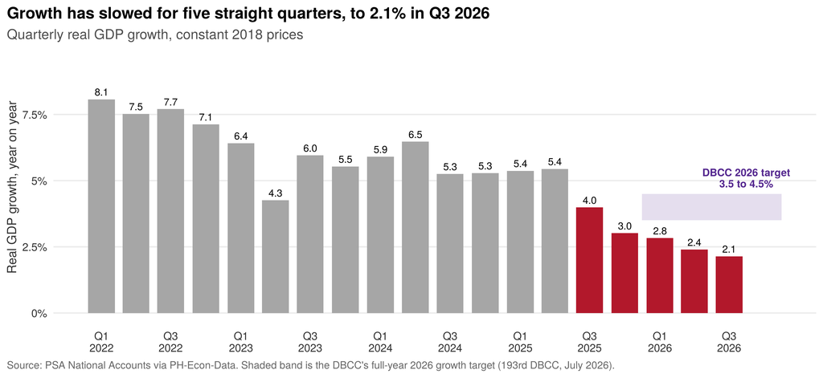

```r
ggplot(gdp, aes(Quarter, g)) +
  annotate("rect", xmin = as.Date("2025-11-15"), xmax = as.Date("2026-11-15"), ymin = 3.5, ymax = 4.5, fill = "#54278F", alpha = 0.15) +
  annotate("text", x = as.Date("2026-08-15"), y = 5.1, label = "DBCC 2026 target\n3.5 to 4.5%", size = 3.2, color = "#54278F", fontface = "bold", lineheight = 0.9) +
  geom_col(aes(fill = Quarter >= as.Date("2025-07-01")), width = 70, show.legend = FALSE) +
  geom_text(aes(label = lab), vjust = -0.5, size = 3.1) +
  scale_fill_manual(values = c(`FALSE` = "grey65", `TRUE` = dn_col)) +
  scale_x_date(breaks = seq(as.Date("2022-01-01"), as.Date("2026-10-01"), by = "6 months"), labels = function(d) paste0("Q", (as.integer(format(d, "%m")) - 1) %/% 3 + 1, "\n", format(d, "%Y"))) +
  scale_y_continuous(limits = c(0, 9.5), labels = function(x) paste0(x, "%")) +
  labs(x = NULL, y = "Real GDP growth, year on year", title = sprintf("Growth has slowed for five straight quarters, to %.1f%% in %s", g_last$g, g_q(g_last$Quarter)),
       subtitle = "Quarterly real GDP growth, constant 2018 prices", caption = "Source: PSA National Accounts via PH-Econ-Data. Shaded band is the DBCC's full-year 2026 growth target (193rd DBCC, July 2026).") +
  theme_pbc()
```

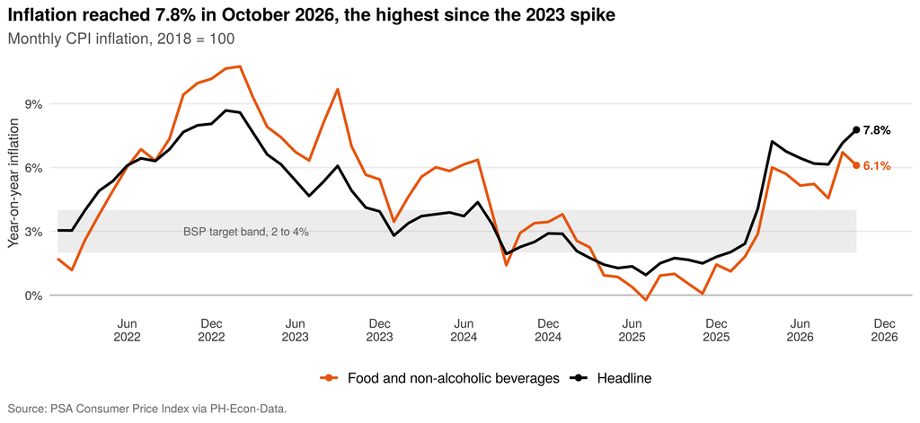

```r
ggplot(infl, aes(Month, Inflation * 100, color = series)) +
  annotate("rect", xmin = min(infl$Month), xmax = max(infl$Month), ymin = 2, ymax = 4, fill = "grey60", alpha = 0.18) +
  annotate("text", x = as.Date("2022-10-01"), y = 3, label = "BSP target band, 2 to 4%", hjust = 0, size = 3.1, color = "grey35") +
  geom_hline(yintercept = 0, color = "grey70") + geom_line(linewidth = 1) + geom_point(data = infl_last, size = 2) +
  geom_text(data = infl_last, aes(label = sprintf("%.1f%%", Inflation * 100)), hjust = -0.25, size = 3.3, fontface = "bold", show.legend = FALSE) +
  scale_color_manual(values = c("Headline" = "black", "Food and non-alcoholic beverages" = "#E6550D")) +
  scale_x_date(date_breaks = "6 months", date_labels = "%b\n%Y", expand = expansion(mult = c(0.01, 0.07))) +
  scale_y_continuous(labels = function(x) paste0(x, "%")) +
  labs(x = NULL, y = "Year-on-year inflation", title = sprintf("Inflation reached %.1f%% in %s, the highest since the 2023 spike", h_last$Inflation * 100, format(h_last$Month, "%B %Y")),
       subtitle = "Monthly CPI inflation, 2018 = 100", caption = "Source: PSA Consumer Price Index via PH-Econ-Data.") +
  theme_pbc()
```

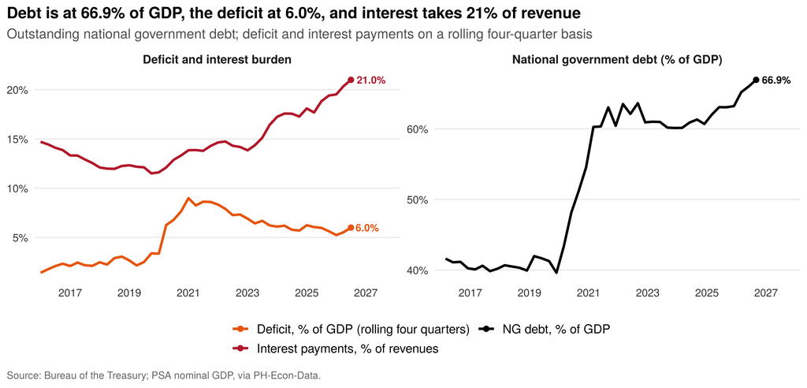

```r
debt <- ngdebt %>% filter(Month >= as.Date("2016-01-01"), !is.na(NominalGDP4Q)) %>% transmute(Date = Month, series = "NG debt, % of GDP", value = TotalObligations / NominalGDP4Q * 100)
ints <- ngcor %>% filter(Quarter >= as.Date("2016-01-01")) %>%
  transmute(Date = Quarter, `Deficit, % of GDP (rolling four quarters)` = -SurplusDeficit4Q / NominalGDP4Q * 100, `Interest payments, % of revenues` = InterestPayments4Q / Revenues4Q * 100) %>%
  pivot_longer(-Date, names_to = "series")
both <- bind_rows(debt %>% mutate(panel = "National government debt (% of GDP)"), ints %>% mutate(panel = "Deficit and interest burden"))
both_last <- both %>% group_by(series) %>% slice_max(Date, n = 1)
ggplot(both, aes(Date, value, color = series)) +
  geom_line(linewidth = 1.05) + geom_point(data = both_last, size = 2) +
  geom_text(data = both_last, aes(label = sprintf("%.1f%%", value)), hjust = -0.2, size = 3.2, fontface = "bold", show.legend = FALSE) +
  facet_wrap(~ panel, scales = "free_y") +
  scale_color_manual(values = c("NG debt, % of GDP" = "black", "Deficit, % of GDP (rolling four quarters)" = "#E6550D", "Interest payments, % of revenues" = "#B2182B")) +
  scale_x_date(date_breaks = "2 years", date_labels = "%Y", expand = expansion(mult = c(0.02, 0.14))) +
  scale_y_continuous(labels = function(x) paste0(x, "%")) +
  labs(x = NULL, y = NULL, title = sprintf("Debt is at %.1f%% of GDP, the deficit at %.1f%%, and interest takes %.0f%% of revenue", debt_now, def_now, ip_rev),
       subtitle = "Outstanding national government debt; deficit and interest payments on a rolling four-quarter basis", caption = "Source: Bureau of the Treasury; PSA nominal GDP, via PH-Econ-Data.") +
  theme_pbc() + guides(color = guide_legend(nrow = 2))
```

Since the NEP was written, every assumption behind it has moved the wrong way. Real GDP grew 2.1% in Q3 2026, down from 2.4% the quarter before, for a year-to-date average of 2.5% against a full-year target of 3.5 to 4.5% and a 2027 assumption of 5 to 6%. Headline inflation was 7.8% in October, with food at 6.1%; it has been above the BSP’s 4% ceiling in 8 of the 10 months of 2026 so far, and the year-to-date average is 5.6% against the budget’s 4 to 5% assumption for 2027. Unemployment was 5.4% in the September 2026 Labor Force Survey round. Over the four quarters to Q3 2026, revenues were 15.7% of GDP, spending 21.7%, and the deficit 6.0%, above the DBCC’s 5.4% program for the year. National government debt reached ₱19.66 trillion at the end of September 2026, or 66.9% of GDP, and interest payments take 21.0% of revenues.

```r
tibble::tribble(
  ~Indicator, ~`DBCC, 2026`, ~`DBCC, 2027 (budget assumption)`, ~`Latest actual`,
  "Real GDP growth", "3.5 to 4.5%", "5.0 to 6.0%", sprintf("%.1f%% (%s); %.1f%% year to date", g_last$g, g_q(g_last$Quarter), g_ytd),
  "Inflation", "6.0 to 7.0%", "4.0 to 5.0%", sprintf("%.1f%% (%s); %.1f%% year-to-date average", h_last$Inflation * 100, format(h_last$Month, "%B"), infl_ytd$m),
  "Revenues, % of GDP", "15.8%", "15.7%", sprintf("%.1f%% (four quarters to %s)", rev_now, g_q(f_now$Quarter)),
  "Deficit, % of GDP", "5.4%", "5.1%", sprintf("%.1f%% (four quarters to %s)", def_now, g_q(f_now$Quarter)),
  "NG debt, % of GDP", "", "64.4%", sprintf("%.1f%% (end-%s)", debt_now, format(d_now$Month, "%B %Y"))
) %>% kbl_clean(align = c("l","r","r","l"), caption = "Macroeconomic assumptions behind the FY 2027 budget, against the latest actuals")
```

Macroeconomic assumptions behind the FY 2027 budget, against the latest actuals

| Indicator | DBCC, 2026 | DBCC, 2027 (budget assumption) | Latest actual |
| --- | --- | --- | --- |
| Real GDP growth | 3.5 to 4.5% | 5.0 to 6.0% | 2.1% (Q3 2026); 2.5% year to date |
| Inflation | 6.0 to 7.0% | 4.0 to 5.0% | 7.8% (October); 5.6% year-to-date average |
| Revenues, % of GDP | 15.8% | 15.7% | 15.7% (four quarters to Q3 2026) |
| Deficit, % of GDP | 5.4% | 5.1% | 6.0% (four quarters to Q3 2026) |
| NG debt, % of GDP |  | 64.4% | 66.9% (end-September 2026) |

DBCC figures from the 193rd DBCC statement (8 July 2026); 2027 debt ratio as reported from the BESF. Actuals from PSA and the Bureau of the Treasury, pulled from the PH-Econ-Data repository at knit time.

PBC has made the same point since September. A budget written for 5 to 6% growth and 4 to 5% inflation is being legislated in a year running at 2% and 7%. Lower growth means lower revenues than programmed and a deficit already above target; higher inflation means the ₱4,494B of programmed appropriations, up only 2.1% on the 2026 GAA, buys less in real terms than the current year’s budget. The committee report does not change the total, so the Senate stage leaves the macro position as it was; what the Senate decides is the composition.

## 5.2 The envelope: three versions, one total

```r
env <- totals %>% transmute(year, total = `NEP Total Appropriations`, new_incl_ua = `NEP New Appropriations`) %>%
  left_join(pap_tot %>% filter(src == "NEP") %>% select(year, programmed = amt), by = "year") %>%
  filter(year >= 2020) %>% mutate(automatic = total - programmed, ua = new_incl_ua - programmed)
e26 <- env %>% filter(year == 2026); e27 <- env %>% filter(year == 2027)
g26_prog <- pap_tot$amt[pap_tot$src == "GAA" & pap_tot$year == 2026]
```

```r
g26_tot <- totals$`GAA Total Appropriations`[totals$year == 2026]
tibble::tribble(
  ~Item, ~`GAA 2026`, ~`NEP 2027`, ~`House bill 2027`, ~`Senate bill 2027`,
  "Programmed new appropriations (sum of P/A/P lines)", g26_prog, s_tot$N27, s_tot$H27, s_tot$S27,
  "Automatic appropriations (derived)", g26_tot - g26_prog, e27$automatic, e27$automatic, e27$automatic,
  "Total obligation program (programmed + automatic)", g26_tot, e27$total, e27$total, e27$total,
  "Unprogrammed appropriations (outside the total)", ua_row$G26, ua_row$N27, ua_row$H27, ua_tot$S
) %>% mutate(across(-Item, ~ bn(.x))) %>%
  kbl_clean(align = c("l", rep("r", 4)), caption = "The FY 2027 envelope across the three versions (PHP billions)") %>% row_spec(3, bold = TRUE) %>%
  footnote(general = "Automatic appropriations are derived as the total obligation program less programmed new appropriations; neither chamber can change them in the bill. Unprogrammed appropriations are derived from the budget totals for 2026 and the NEP; the House kept the NEP figure; the Senate figure is from Annex A of the committee report.", general_title = "")
```

The FY 2027 envelope across the three versions (PHP billions)

| Item | GAA 2026 | NEP 2027 | House bill 2027 | Senate bill 2027 |
| --- | --- | --- | --- | --- |
| Programmed new appropriations (sum of P/A/P lines) | 4,402.8 | 4,494.1 | 4,494.1 | 4,494.1 |
| Automatic appropriations (derived) | 2,390.4 | 2,706.1 | 2,706.1 | 2,706.1 |
| Total obligation program (programmed + automatic) | 6,793.2 | 7,200.2 | 7,200.2 | 7,200.2 |
| Unprogrammed appropriations (outside the total) | 150.9 | 112.0 | 112.0 | 111.2 |

Automatic appropriations are derived as the total obligation program less programmed new appropriations; neither chamber can change them in the bill. Unprogrammed appropriations are derived from the budget totals for 2026 and the NEP; the House kept the NEP figure; the Senate figure is from Annex A of the committee report.

## 5.3 The biggest departments and funds

```r
dept <- ss %>% group_by(dep, Department = dept) %>%
  summarise(across(c(N26, G26, N27, H27, S27), ~ if (all(is.na(.x))) NA_real_ else sum(.x, na.rm = TRUE)), .groups = "drop") %>%
  filter(coalesce(N27, 0) + coalesce(S27, 0) > 0) %>%
  mutate(`Senate vs House` = S27 - H27, `Senate vs NEP` = S27 - N27, `Senate vs GAA 2026` = S27 - G26, `Senate vs GAA 2026 (%)` = (S27 / G26 - 1) * 100, share = S27 / sum(S27) * 100)
```

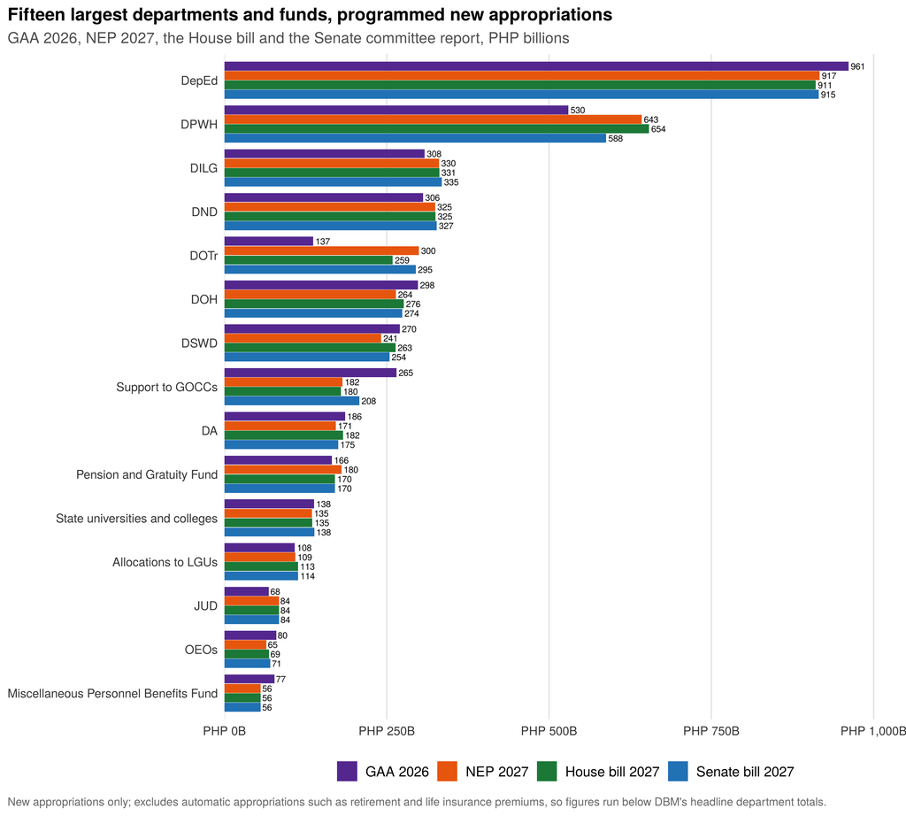

```r
top_dept <- dept %>% slice_max(S27, n = 15) %>%
  select(dep, `GAA 2026` = G26, `NEP 2027` = N27, `House bill 2027` = H27, `Senate bill 2027` = S27) %>% pivot_longer(-dep) %>%
  mutate(name = factor(name, levels = rev(ver_lv[-1])), dep = recode(dep, "ALGU" = "Allocations to LGUs", "BSGC" = "Support to GOCCs", "SUCs" = "State universities and colleges"))
ord <- top_dept %>% filter(name == "Senate bill 2027") %>% arrange(value) %>% pull(dep)
ggplot(top_dept, aes(value, factor(dep, levels = ord), fill = name)) +
  geom_col(position = position_dodge(width = 0.86), width = 0.82) +
  geom_text(aes(label = comma(value, accuracy = 1)), position = position_dodge(width = 0.86), hjust = -0.15, size = 2.5) +
  scale_fill_manual(values = ver_pal[-1], breaks = ver_lv[-1]) +
  scale_x_continuous(labels = function(x) paste0(peso, comma(x), "B"), expand = expansion(mult = c(0, 0.08))) +
  labs(x = NULL, y = NULL, title = "Fifteen largest departments and funds, programmed new appropriations",
       subtitle = "GAA 2026, NEP 2027, the House bill and the Senate committee report, PHP billions",
       caption = "New appropriations only; excludes automatic appropriations such as retirement and life insurance premiums, so figures run below DBM's headline department totals.") +
  theme_pbc() + theme(panel.grid.major.y = element_blank(), panel.grid.major.x = element_line(color = "grey90")) + guides(fill = guide_legend(nrow = 1))
```

```r
dept %>% arrange(desc(S27)) %>%
  transmute(Department, `GAA 2026` = G26, `NEP 2027` = N27, `House bill 2027` = H27, `Senate bill 2027` = S27, `Share of Senate bill (%)` = share, `Senate vs House`, `Senate vs NEP`, `Senate vs GAA 2026`, `Senate vs GAA 2026 (%)`) %>%
  dt_table(caption = "All departments and special purpose funds, programmed new appropriations (PHP billions). Sortable and exportable.",
           page = 15, money_cols = c("GAA 2026","NEP 2027","House bill 2027","Senate bill 2027","Senate vs House","Senate vs NEP","Senate vs GAA 2026"), pct_cols = c("Share of Senate bill (%)","Senate vs GAA 2026 (%)"))
```

| Department | GAA 2026 | NEP 2027 | House bill 2027 | Senate bill 2027 | Share of Senate bill (%) | Senate vs House | Senate vs NEP | Senate vs GAA 2026 | Senate vs GAA 2026 (%) |
| --- | --- | --- | --- | --- | --- | --- | --- | --- | --- |
| Department of Education (DepEd) | 961.323626 | 916.757759 | 910.586984 | 915.499946 | 20.37123367567142 | 4.912961999999993 | -1.257812999999942 | -45.82367999999997 | -4.76672774502267 |
| Department of Public Works and Highways (DPWH) | 529.595195 | 642.612015 | 654.102015 | 587.902738 | 13.0817091870861 | -66.19927700000005 | -54.70927700000004 | 58.30754300000001 | 11.00983233052182 |
| Department of the Interior and Local Government (DILG) | 308.464121 | 330.465504 | 330.879584 | 334.903393 | 7.452097957391055 | 4.023808999999972 | 4.437888999999984 | 26.43927199999996 | 8.571263300991806 |
| Department of National Defense (DND) | 305.872697 | 324.632679 | 325.186444 | 326.915642 | 7.274358632691981 | 1.729197999999997 | 2.282962999999995 | 21.04294499999997 | 6.879641500006128 |
| Department of Transportation (DOTr) | 136.787878 | 299.526428 | 259.075428 | 294.568744 | 6.554592104337528 | 35.49331599999999 | -4.957684000000029 | 157.780866 | 115.3471113865806 |
| Department of Health (DOH) | 297.857214 | 264.032994 | 276.260493 | 274.040139 | 6.097800150042256 | -2.220353999999986 | 10.00714500000004 | -23.81707499999999 | -7.996138377900753 |
| Department of Social Welfare and Development (DSWD) | 269.932864 | 241.280585 | 263.449885 | 254.136479 | 5.654914150285883 | -9.313406000000015 | 12.85589399999998 | -15.79638500000001 | -5.851968065659474 |
| Budgetary Support to Government Corporations (BSGC) | 264.819717 | 181.970095 | 179.51411 | 207.76063 | 4.62298262367643 | 28.24652 | 25.79053500000001 | -57.05908699999998 | -21.54638923656881 |
| Department of Agriculture (DA) | 185.766021 | 171.318954 | 182.473178 | 175.040217 | 3.894904831755428 | -7.432960999999978 | 3.721263000000022 | -10.72580399999998 | -5.773824482142498 |
| Pension and Gratuity Fund | 165.518761 | 180.265691 | 170.265691 | 170.265691 | 3.788664536208137 | 0 | -10 | 4.746929999999992 | 2.867910544593788 |

[output cut: 32 more lines]

DepEd remains the largest department at ₱915.5B, 20% of the programmed budget, followed by DPWH (₱587.9B, down from ₱654.1B), DILG, DND, and DOTr (₱294.6B, back near its NEP level with the rail loans restored). Against the 2026 GAA, the committee report leaves DepEd -4.8%, DOH -8.0%, DSWD -5.9%, DA -5.8%, and DPWH +11.0%, with support to GOCCs -21.5% because the PhilHealth subsidy, even after the ₱19.8B addition, is ₱35.5B below what was enacted for 2026.

## 5.4 The biggest agencies

```r
agy_tbl <- ss %>% group_by(Department = dep, Agency = agy) %>%
  summarise(across(c(G26, N27, H27, S27), ~ if (all(is.na(.x))) NA_real_ else sum(.x, na.rm = TRUE)), .groups = "drop") %>%
  filter(coalesce(G26, 0) + coalesce(N27, 0) + coalesce(S27, 0) > 0) %>% arrange(desc(S27)) %>%
  mutate(`Senate vs House` = S27 - coalesce(H27, 0), `Senate vs NEP` = S27 - coalesce(N27, 0), `Senate vs GAA 2026` = S27 - coalesce(G26, 0))
agy_tbl %>% rename(`GAA 2026` = G26, `NEP 2027` = N27, `House bill 2027` = H27, `Senate bill 2027` = S27) %>%
  dt_table(caption = "All agencies, programmed new appropriations (PHP billions). Includes each State University and College and each government corporation receiving budgetary support.",
           page = 20, money_cols = c("GAA 2026","NEP 2027","House bill 2027","Senate bill 2027","Senate vs House","Senate vs NEP","Senate vs GAA 2026"))
```

| Department | Agency | GAA 2026 | NEP 2027 | House bill 2027 | Senate bill 2027 | Senate vs House | Senate vs NEP | Senate vs GAA 2026 |
| --- | --- | --- | --- | --- | --- | --- | --- | --- |
| DepEd | OSEC | 958.696109 | 914.24475 | 908.073975 | 912.773975 | 4.699999999999932 | -1.470775000000003 | -45.92213400000003 |
| DPWH | OSEC | 529.595195 | 642.612015 | 654.102015 | 587.902738 | -66.19927700000005 | -54.70927700000004 | 58.30754300000001 |
| DOH | OSEC | 297.489464 | 263.624289 | 275.851788 | 273.550082 | -2.301706000000024 | 9.925792999999999 | -23.93938200000002 |
| DSWD | OSEC | 264.44795 | 235.713482 | 257.782782 | 248.238882 | -9.543900000000008 | 12.52539999999999 | -16.209068 |
| DOTr | OSEC | 91.250683 | 251.592535 | 211.141535 | 246.088047 | 34.94651199999998 | -5.504488000000009 | 154.837364 |
| DILG | Philippine National Police | 226.140071 | 242.109847 | 242.309847 | 245.222511 | 2.912664000000007 | 3.112664000000024 | 19.08244000000002 |
| Pension and Gratuity Fund | Pension and Gratuity Fund | 165.518761 | 180.265691 | 170.265691 | 170.265691 | 0 | -10 | 4.746929999999992 |
| DA | OSEC | 165.54132 | 151.991969 | 163.741193 | 153.261455 | -10.479738 | 1.269486000000001 | -12.279865 |
| DND | Philippine Army ( Land Forces ) | 145.161444 | 146.873792 | 147.067557 | 147.107065 | 0.03950800000001209 | 0.233272999999997 | 1.945621000000017 |
| BSGC | Philippine Health Insurance Corporation | 129.782163 | 74.448505 | 74.448505 | 94.248505 | 19.8 | 19.8 | -35.533658 |

[output cut: 362 more lines]

## 5.5 The biggest line items

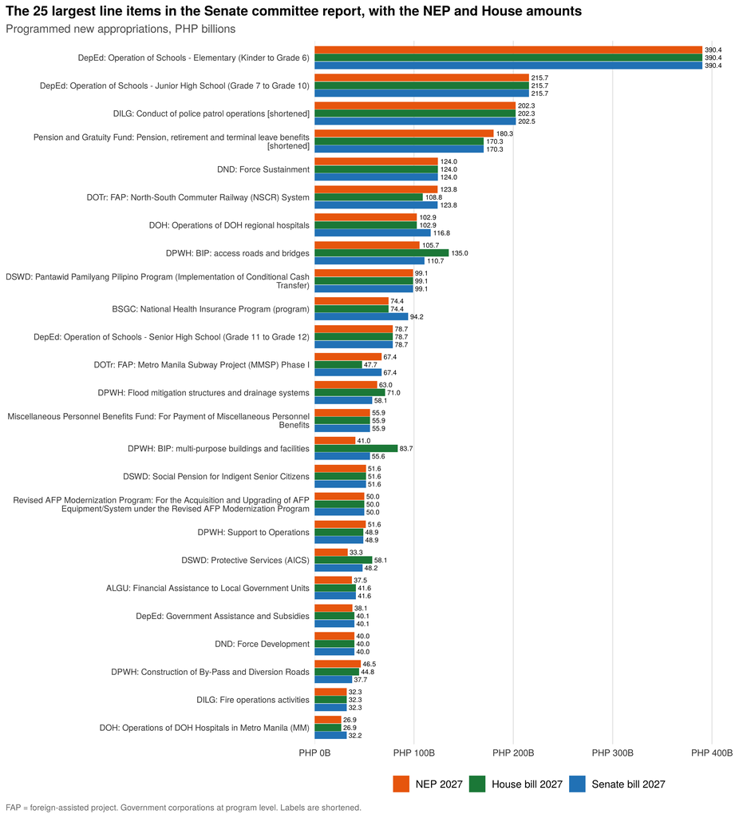

```r
top_pap <- ss %>% slice_max(S27, n = 25) %>% mutate(lab = str_wrap(paste0(dep, ": ", short), 78))
ggplot(top_pap %>% select(lab, `NEP 2027` = N27, `House bill 2027` = H27, `Senate bill 2027` = S27) %>% pivot_longer(-lab) %>% mutate(name = factor(name, levels = rev(names(v3_pal)))),
       aes(value, factor(lab, levels = top_pap %>% arrange(S27) %>% pull(lab)), fill = name)) +
  geom_col(position = position_dodge(width = 0.84), width = 0.8) +
  geom_text(aes(label = comma(value, accuracy = 0.1)), position = position_dodge(width = 0.84), hjust = -0.15, size = 2.3) +
  scale_fill_manual(values = v3_pal, breaks = names(v3_pal)) +
  scale_x_continuous(labels = function(x) paste0(peso, comma(x), "B"), expand = expansion(mult = c(0, 0.09))) +
  labs(x = NULL, y = NULL, title = "The 25 largest line items in the Senate committee report, with the NEP and House amounts",
       subtitle = "Programmed new appropriations, PHP billions", caption = "FAP = foreign-assisted project. Government corporations at program level. Labels are shortened.") +
  theme_pbc(11) + theme(panel.grid.major.y = element_blank(), panel.grid.major.x = element_line(color = "grey90"), axis.text.y = element_text(size = 8.1, lineheight = 0.85)) + guides(fill = guide_legend(nrow = 1))
```

## 5.6 The social lines across three versions

```r
bind_rows(
  pick("Operation of Schools", dep = "DepEd", label = "DepEd school operations (kinder to senior high)"),
  pick("^Basic Education Facilities", dep = "DepEd"),
  pick("School-Based Feeding Program \\(SBFP\\)$", dep = "DepEd"),
  pick("Computerization Program", dep = "DepEd"),
  pick("Textbooks|Learning Resources", dep = "DepEd", label = "DepEd textbooks and learning resources"),
  pick("Government Assistance and Subsidies", dep = "DepEd"),
  pick("Universal Access to Quality Tertiary Education", dep = "OEOs"),
  pick("Tulong Dunong", dep = "OEOs"),
  pick(".", dep = "SUCs", label = "State universities and colleges, all lines"),
  pick("^Operations of DOH", dep = "DOH", label = "DOH hospital operations (regional and Metro Manila)"),
  pick("Medical Assistance to Indigent", dep = "DOH"),
  pick("Zero Balance Billing", dep = "DOH"),
  pick("^Health Facilities Enhancement", dep = "DOH"),
  pick("Nationally-procured Commodities for Family Health", dep = "DOH"),
  pick("Nationally-procured Commodities for Prevention", dep = "DOH"),
  pick("^Health Promotion", dep = "DOH"),
  pick(".", dep = "BSGC", agy = "Philippine Health Insurance", label = "PhilHealth premium subsidy (program)"),
  pick("^Hospital Services Program", dep = "BSGC", label = "Specialty hospitals, hospital services programs"),
  pick("^Protective Services for Individuals", dep = "DSWD"),
  pick("^Pantawid Pamilyang", dep = "DSWD"),
  pick("^Social Pension for Indigent", dep = "DSWD"),
  pick("Walang Gutom", dep = "DSWD"),
  pick("Sustainable Livelihood", dep = "DSWD"),
  pick("^Livelihood and Emergency Employment", dep = "DOLE", label = "DOLE livelihood and emergency employment (incl. TUPAD)"),
  pick("Presidential Assistance to Farmers", dep = "DA"),
  pick("Rice Competitiveness|National Rice Program", dep = "DA", label = "DA rice program and RCEF lines"),
  pick("National Livestock|Animal Industry", dep = "DA", label = "DA livestock program and Animal Industry project"),
  pick("Farm-to-Market Roads in", dep = "DA"),
  pick("^Financial Assistance to Local Government", dep = "ALGU"),
  pick("^Growth Equity Fund", dep = "ALGU")
) %>% show_lines()
```

| Agency | Program / Activity / Project | GAA 2026 | NEP 2027 | House 2027 | Senate 2027 | Senate vs House | Senate vs NEP |
| --- | --- | --- | --- | --- | --- | --- | --- |
| DepEd · OSEC | DepEd school operations (kinder to senior high) | 625.49 | 684.76 | 684.76 | 684.76 | 0.00 | 0.00 |
| DepEd · OSEC | Basic Education Facilities | 85.40 | 30.55 | 27.45 | 20.95 | -6.50 | -9.60 |
| DepEd · OSEC | School-Based Feeding Program (SBFP) | 25.70 | 11.43 | 11.43 | 22.43 | +11.00 | +11.00 |
| DepEd · OSEC | Computerization Program | 10.68 | 5.79 | 2.63 | 2.63 | 0.00 | -3.16 |
| DepEd · OSEC | DepEd textbooks and learning resources | 19.57 | 6.53 | 6.53 | 6.53 | 0.00 | 0.00 |
| DepEd · OSEC | Government Assistance and Subsidies - Educational Service Contracting (ESC) Program for Private Junior High School (per R.A. No. 8545) | 12.36 | 0.00 | 0.00 | 0.00 | 0.00 | 0.00 |
| DepEd · OSEC | Government Assistance and Subsidies - Training and Upgrading Knowledge for Learners, Teachers, and Achievers in Schools (GAS-TUKLAS) | 0.10 | 0.00 | 0.00 | 0.00 | 0.00 | 0.00 |
| DepEd · OSEC | Government Assistance and Subsidies | 0.00 | 38.12 | 40.05 | 40.05 | 0.00 | +1.93 |
| OEOs · Commission on Higher Education | Universal Access to Quality Tertiary Education | 37.55 | 27.79 | 29.89 | 29.89 | 0.00 | +2.10 |
| OEOs · Commission on Higher Education | Universal Access to Quality Tertiary Education - Tertiary Education Subsidy | 0.00 | 0.00 | 0.00 | 0.00 | 0.00 | 0.00 |
| OEOs · Commission on Higher Education | Universal Access to Quality Tertiary Education - Free Higher Education | 0.00 | 0.00 | 0.00 | 0.00 | 0.00 | 0.00 |
| OEOs · Commission on Higher Education | Tulong Dunong Program | 2.73 | 0.00 | 1.77 | 1.77 | 0.00 | +1.77 |
| SUCs · Eulogio ‘Amang’ Rodriguez Institute of Science and Technology | State universities and colleges, all lines | 137.90 | 134.56 | 135.43 | 138.30 | +2.87 | +3.74 |
| DOH · OSEC | DOH hospital operations (regional and Metro Manila) | 131.73 | 129.80 | 129.85 | 148.95 | +19.11 | +19.16 |
| DOH · OSEC | Medical Assistance to Indigent and Financially - Incapacitated Patients (MAIFIP) | 51.65 | 24.24 | 48.20 | 16.20 | -32.00 | -8.04 |
| DOH · OSEC | DOH Universal Health Care Fund for Zero Balance Billing in Local Government Unit (LGU) Hospitals | 1.00 | 0.00 | 0.00 | 1.00 | +1.00 | +1.00 |
| DOH · OSEC | Health Facilities Enhancement Program | 22.29 | 14.54 | 10.09 | 15.58 | +5.49 | +1.04 |
| DOH · OSEC | Nationally-procured Commodities for Family Health, Immunization, Nutrition and Responsible Parenting | 10.24 | 9.10 | 4.23 | 5.82 | +1.60 | -3.27 |
| DOH · OSEC | Nationally-procured Commodities for Prevention and Control of Communicable Diseases | 7.72 | 6.89 | 8.69 | 8.69 | 0.00 | +1.80 |
| DOH · OSEC | Nationally-procured Commodities for Prevention and Control of Non-Communicable Diseases | 2.73 | 2.73 | 2.73 | 2.73 | 0.00 | 0.00 |
| DOH · OSEC | Health Promotion | 1.11 | 2.54 | 0.49 | 1.58 | +1.10 | -0.95 |
| BSGC · Philippine Health Insurance Corporation | PhilHealth premium subsidy (program) | 129.78 | 74.45 | 74.45 | 94.25 | +19.80 | +19.80 |
| BSGC · Lung Center of the Philippines | Specialty hospitals, hospital services programs | 13.34 | 7.87 | 7.87 | 9.89 | +2.02 | +2.02 |
| DSWD · OSEC | Protective Services for Individuals and Families in Difficult Circumstances | 63.90 | 33.28 | 58.09 | 48.19 | -9.90 | +14.91 |
| DSWD · OSEC | Pantawid Pamilyang Pilipino Program (Implementation of Conditional Cash Transfer) | 113.00 | 99.08 | 99.08 | 99.08 | 0.00 | 0.00 |
| DSWD · OSEC | Social Pension for Indigent Senior Citizens | 51.86 | 51.64 | 51.64 | 51.64 | 0.00 | 0.00 |
| DSWD · OSEC | Locally-Funded Project: Walang Gutom 2027: Food STAMP Program | 1.89 | 1.89 | 1.89 | 1.89 | 0.00 | 0.00 |
| DSWD · OSEC | Sustainable Livelihood Program | 5.31 | 5.12 | 5.99 | 6.04 | +0.05 | +0.92 |
| DOLE · OSEC | DOLE livelihood and emergency employment (incl. TUPAD) | 25.36 | 16.70 | 21.45 | 21.47 | +0.02 | +4.77 |
| DA · OSEC | Locally-Funded Project: Presidential Assistance to Farmers and Fisherfolk | 10.00 | 0.00 | 10.00 | 5.00 | -5.00 | +5.00 |
| DA · OSEC | DA rice program and RCEF lines | 60.16 | 59.92 | 60.42 | 64.26 | +3.84 | +4.34 |
| DA · OSEC | DA livestock program and Animal Industry project | 3.81 | 20.00 | 20.00 | 5.70 | -14.30 | -14.30 |
| DA · OSEC | Locally-Funded Project: Repair/Rehabilitation and Construction of Farm-to-Market Roads in Designated Key Production Areas | 33.01 | 16.00 | 19.63 | 16.00 | -3.63 | 0.00 |
| ALGU · Local Government Support Fund (formerly Financial Subsidy to LGUs) | Financial Assistance to Local Government Units | 37.49 | 37.49 | 41.58 | 41.58 | 0.00 | +4.09 |
| ALGU · Local Government Support Fund (formerly Financial Subsidy to LGUs) | Growth Equity Fund | 11.30 | 10.30 | 10.30 | 8.70 | -1.60 | -1.60 |

The table is the budget’s social core across the three versions. Against the House bill the Senate committee adds to PhilHealth, hospitals, feeding, HFEP and commodities and takes from MAP, AICS, PAFF and classrooms. Against the NEP the budget is now higher on PhilHealth, hospitals, AICS, feeding, TUPAD, tertiary subsidies and LGU assistance, and lower on classrooms, MAP, immunization commodities, computerization and the Animal Industry project. 4Ps, social pension and the food stamp program are at the NEP’s figures in all three.

# 6 What to push for in the plenary and the bicam

The committee report delivers more of PBC’s House-stage asks than any recent committee report: the foreign-assisted restorations, the MAP-to-hospitals redesign, PhilHealth, HFEP, crop insurance, the Senate’s cut to its own budget, the project lists, and an open process. What follows is the shorter list of what is still open, in the order of what is at stake:

1. Restore the classrooms. Basic Education Facilities is at ₱21.0B against ₱30.6B proposed and ₱85.4B enacted for 2026. The committee cut it by ₱6.5B on top of the House’s ₱3.1B. The ₱9.6B gap is the largest remaining cut to a people-centered line.
2. Finish the immunization restoration. The family-health and immunization commodities line is ₱3.3B below the NEP after a ₱1.6B partial restoration. The Senate has already accepted the principle, since it funded ₱1.6B of it; the rest is ₱3.3B.
3. Fund the fuel lines for farmers and fisherfolk. Fuel assistance to fisherfolk and farmers stands at zero in all three versions, and the transport fuel subsidy at ₱1.0B. The committee’s El Niño package is written as eligibility language in the calamity fund, the quick response funds and the LGU assistance window (Annex B); an appropriation line for drought and fuel relief to farmers and fisherfolk, with the implementing agency and the mechanism named, would put money behind the permission.
4. Undo the calamity fund and pension cuts. Both keep the House’s cuts (₱9.5B and ₱10B). PBC’s view is that the ₱7.75B cut to the DRRM assistance program for LGUs, a bicam creation in 2026 with no published allocation criteria, is defensible, while the ₱1.75B taken from the preparedness lump and the ₱10B pension cut are not, since neither obligation disappears. Other groups read the calamity-fund cut as a straight reduction in disaster readiness, and the Senate should hear both arguments before the El Niño eligibility language is taken as a substitute for the amount.
5. Convert the remaining ayuda into entitlements. The committee’s MAP-to-hospitals move is the right design: money that reaches patients through the hospital bill, with no guarantee letter in between. AICS at ₱48.2B, TUPAD at ₱21.5B and PAFF at ₱5.0B are still ₱25B above the NEP combined; the plenary should at least require quarterly publication of releases by district and by hospital.
6. Keep the project lists in the enrolled bill. The committee report attaches the lists: every DPWH project by office with coordinates (Annex A-4), every farm-to-market road (A-1), every HFEP facility (A-2) and every NIA project (A-3). ₱166B remains in the two BIP lines and ₱15.9B above the NEP in the district engineering offices, but it is now itemized. The ask shifts: carry the annexes into the bicam report and the GAA as the binding list, publish them in machine-readable form, and state who identified each surviving project. No list accompanies the ₱19B of standby cover for the DAR and DA bridge programs.
7. Finish the loan-project cover, and explain the new standby items. ₱60B of foreign-assisted appropriations remain cut across 20 projects; the unprogrammed annex covers ₱24B of that and leaves 6 projects, including DSWD’s community resilience loan and two flood projects, with nothing. The plenary should also ask what the ₱31B of new standby cover for DAR, DA and DPWH bridge and seismic projects is for, since their programmed lines are small and the DAR and DA bridge programs have no project annex, and what happens to the ₱57B PDIC obligation the committee deleted.
8. Keep the Senate’s own cut, and revisit the House’s increase. The committee cut the Senate’s budget by ₱2.0B; the House’s ₱5.0B self-increase stands. The House tends to get its way on these figures in the bicam. The Senate should hold its cut on the floor and insist on it in the conference.

# 7 A note on the data

- Coverage: the P/A/P workbook covers programmed new appropriations: national government agencies, DPWH, SUCs, budgetary support to government corporations, and special purpose funds, FY 2020 to FY 2027, with the FY 2027 NEP, the House bill (HB 10858, third-reading print) and the Senate committee report (Committee Report No. 131, filed 20 November 2026) encoded line by line. Automatic and unprogrammed appropriations are not itemized in it. Amounts are in pesos in the source and shown here in billions.
- The Senate committee report takes the form of amendments to the House third-reading print, and was encoded by applying each amendment to the matching House line. Lines with no House counterpart were added as new rows (191 lines carry an amount in the Senate version and none in the House bill, worth ₱14.9B, most of them small SUC and agency projects); 1 line was zeroed. Every agency total reconciles to the committee report’s totals by expense class, and the programmed total matches the House bill and the NEP to the peso. The unprogrammed appropriations annex (Annex A, pp. 152 to 156) is transcribed into the report as a table of 41 itemized projects and three deleted purposes. The project-level annexes (A-1 farm-to-market roads, 148 pp.; A-2 HFEP, 5 pp.; A-3 NIA, 107 pp.; A-4 DPWH programs and projects by office, 210 pp.; A-5 TIEZA and TPB) and Annex B (special and general provisions, 120 pp.) were read for what they contain but are not encoded; the figures in this report stop at the sub-program and office level, and the special-provision changes are described in prose where they bear on a finding (unprogrammed appropriations, the calamity fund and quick response funds, MAP, DPWH project modification). The committee’s General Summary (LBRMO, 19 November 2026) was checked against the workbook: every agency total matches, and the two department totals that differ (DSWD, Other Executive Offices) do so only because the bill lists the National Anti-Poverty Commission and the Presidential Commission for the Urban Poor under Other Executive Offices while the workbook keeps them under DSWD. The committee’s headline ₱204.6B of amendments counts movements between operating units and objects of expenditure within a line as both an increase and a decrease; netted by P/A/P line, the figure is ₱182.3B. The Annex also cuts ₱7.1B from the Philippine National Oil Company’s corporate operating budget, which is corporate funds, not new appropriations, and is outside this report.
- Government corporations at program level: PBC’s encoding of the House bill and the Senate committee report stops at the program level for budgetary support to GOCCs; the bills themselves go further, and the committee report attaches a project-level annex for NIA. The workbook carries the NEP’s 566 activity and project lines for these corporations, but the House and Senate amounts are known only at the program total. Every comparison involving a corporation in this report is therefore made at agency × program level (92 programs), and labels carry the tag “[program total]”. The national government agencies, DPWH, SUCs and special purpose funds are compared at P/A/P level as before.
- Line counts: a DPWH locally funded line is a sub-program covering hundreds of projects; the DA’s farm-to-market roads are one national line; a GOCC line is a whole program in PBC’s encoding. Counts of lines changed are a rough guide to the number of decisions, while the peso figures are exact.
- Blanks and zeros: blank cells become zeros in every expense column. Rows that are zero in every expense column of every year are dropped (16 rows). Document-years that are entirely zero within a tab are re-blanked so they read as “no data” and not as an actual zero (NEP 2018, GAA 2018, NEP 2019, GAA 2019; these years are carried for some tabs only). New and discontinued lines count from or to zero in every change calculation.
- DPWH by operating unit comes from the DPWH workbook’s `NewAppro_ByOperUnit` sheet, which sums every office line under every sub-program in each version. Provinces are inferred from office names and should be read as approximate.
- Red-flag basket: the definitions are those of the NEP and House assessments. TUPAD and the confidential and intelligence funds are sub-line figures; the Senate’s CIF changes are not yet known and the House figure is carried. Unprogrammed appropriations are derived from the budget totals for 2026 and the NEP; the Senate’s figure and its composition are from Annex A.
- Press-reported figures: the committee’s announced totals (₱204.6B of amendments; ₱97.5B of DPWH cuts; ₱68.8B of foreign-assisted restorations; ₱52B for health; ₱15.3B for education; ₱10B realigned for El Niño) are taken from its 20 to 21 November press briefing as reported by the Manila Times, Philstar, the Daily Tribune and GMA News, and are shown alongside the line-item measurements for comparison. Where the two differ, the line data are used.
- Macroeconomic series are pulled at knit time from the public `ajamontesa/PH-Econ-Data` repository (PSA national accounts and CPI, BTr cash operations and debt, Labor Force Survey), with a local fallback copy.

# 8 Reference: every line item of ₱100 million or more

```r
ss %>% filter(tab != "SUCs", pmax(G26, N27, H27, S27, na.rm = TRUE) >= 0.1) %>%
  transmute(Department = dep, Agency = agy, `Program / Activity / Project` = PAP,
            `GAA 2026` = G26, `NEP 2027` = N27, `House bill 2027` = H27, `Senate bill 2027` = S27, `Senate vs House` = dS, `Senate vs NEP` = dSN, `Senate vs GAA 2026` = S27 - coalesce(G26, 0)) %>%
  arrange(desc(`Senate bill 2027`)) %>%
  dt_table(caption = "All non-SUC line items with ₱100M or more in GAA 2026, NEP 2027, the House bill, or the Senate committee report (PHP billions). Search by agency or keyword; export with the buttons.",
           page = 15, money_cols = c("GAA 2026","NEP 2027","House bill 2027","Senate bill 2027","Senate vs House","Senate vs NEP","Senate vs GAA 2026"), money_digits = 2)
```

| Department | Agency | Program / Activity / Project | GAA 2026 | NEP 2027 | House bill 2027 | Senate bill 2027 | Senate vs House | Senate vs NEP | Senate vs GAA 2026 |
| --- | --- | --- | --- | --- | --- | --- | --- | --- | --- |
| DepEd | OSEC | Operation of Schools - Elementary (Kinder to Grade 6) | 358.132789 | 390.375943 | 390.375943 | 390.375943 | 0 | 0 | 32.243154 |
| DepEd | OSEC | Operation of Schools - Junior High School (Grade 7 to Grade 10) | 197.734667 | 215.685338 | 215.685338 | 215.685338 | 0 | 0 | 17.950671 |
| DILG | Philippine National Police | Conduct of police patrol operations and other related confidential activities against dissidents, subversives, lawless elements and organized crime syndicates and campaign against kidnapping, traffick… | 187.345447 | 202.278352 | 202.278352 | 202.545058 | 0.2667059999999992 | 0.2667059999999992 | 15.199611 |
| Pension and Gratuity Fund | Pension and Gratuity Fund | For Payment of Pension, Retirement and Terminal Leave Benefits, Separation Benefits, including Monetization of Leave Credits | 0 | 180.265691 | 170.265691 | 170.265691 | 0 | -10 | 170.265691 |
| DND | Philippine Army ( Land Forces ) | Force Sustainment | 110.526766 | 123.965621 | 123.965621 | 123.965621 | 0 | 0 | 13.438855 |
| DOTr | OSEC | Foreign-Assisted Project: North-South Commuter Railway (NSCR) System ADB Loan Nos. 3796-PHI, 4188-PHI and 4589-PHI, and JICA Loan Nos. PH-P262, PH-P270, PH-P276 and PH-P277 | 28.79361 | 123.84345 | 108.84345 | 123.84345 | 15 | 0 | 95.04984 |
| DOH | OSEC | Operations of DOH Regional Hospitals and Other Health Facilities | 101.749437 | 102.867031 | 102.917031 | 116.756479 | 13.839448 | 13.889448 | 15.007042 |
| DPWH | OSEC | Basic Infrastructure Program (BIP) - Access Roads and/or Bridges from the National Road/s leading to Major / Strategic Public Buildings / Facilities | 33.636646 | 105.725209 | 134.993811 | 110.697872 | -24.29593899999999 | 4.972662999999997 | 77.061226 |
| DSWD | OSEC | Pantawid Pamilyang Pilipino Program (Implementation of Conditional Cash Transfer) | 112.997044 | 99.075498 | 99.075498 | 99.075498 | 0 | 0 | -13.92154600000001 |
| BSGC | Philippine Health Insurance Corporation | National Health Insurance Program [program total] | 129.782163 | 74.448505 | 74.448505 | 94.248505 | 19.8 | 19.8 | -35.533658 |

[output cut: 1103 more lines]

Underlying data: DBM National Expenditure Program and General Appropriations Act, FY 2020 to FY 2027; House Bill 10858 (third-reading print, October 2026); Senate Committee Report No. 131 on HB 10858 (filed 20 November 2026), compiled at P/A/P level by the People’s Budget Coalition; DPWH appropriations by operating unit from the NEP, HB 10858 and Committee Report No. 131; DBM budget totals; PSA and Bureau of the Treasury macroeconomic and fiscal series via PH-Econ-Data. Committee statements are quoted from press coverage of 20 to 22 November 2026.